# 🔵 MAVİ ÇİZGİ DÜZELTMESİ SÜRÜMÜ — referanslar artık sizin çizdiğiniz sınırlardan alınır

```
↺ Attention U-Net: kayıtlı sonuç başka referans/ayarlarla üretilmiş (ör. eski sözde-etiketler) → kullanılmıyor, yeniden eğitiliyor.

==========================================================================================
▶ Attention U-Net (CNN) — GA protokolü: nested | parmak izi fd5142ff2fa19ac2d
==========================================================================================
   🧮 VRAM [Attention U-Net]: taban 0.45 GB + 137 MB/örnek (yama 320) | bütçe 2.72 GB / toplam 4.0 GB | varsayılan hp ile tek eğitim ≈ 1.13 GB → aynı anda ≈ 2 eğitim sığar
   [Attention U-Net [dış katlama 0]] nesil 0: en iyi=0.9320  ort=0.9151  (genel en iyi=0.9320, önbellek=8, geçen 27.1 dk)
   [Attention U-Net [dış katlama 0]] nesil 1: en iyi=0.9326  ort=0.9261  (genel en iyi=0.9326, önbellek=14, geçen 49.4 dk)
   [Attention U-Net [dış katlama 0]] nesil 2: en iyi=0.9403  ort=0.9319  (genel en iyi=0.9403, önbellek=20, geçen 74.3 dk)
   [Attention U-Net [dış katlama 0]] nesil 3: en iyi=0.9403  ort=0.9265  (genel en iyi=0.9403, önbellek=26, geçen 97.7 dk)
   [Attention U-Net [dış katlama 0]] nesil 4: en iyi=0.9403  ort=0.9314  (genel en iyi=0.9403, önbellek=32, geçen 125.9 dk)
   [Attention U-Net [dış katlama 0]] nesil 5: en iyi=0.9430  ort=0.9324  (genel en iyi=0.9430, önbellek=38, geçen 155.0 dk)
   katlama 0: eğitim 1918.7s × 3 tohum, çıkarım 0.21s/görüntü | ⏱️ bu katlama 251.3 dk, Attention U-Net için kalan ≈ 12.6 saat
   [Attention U-Net [dış katlama 1]] nesil 0: en iyi=0.9766  ort=0.9508  (genel en iyi=0.9766, önbellek=8, geçen 21.3 dk)
   [Attention U-Net [dış katlama 1]] nesil 1: en iyi=0.9790  ort=0.9624  (genel en iyi=0.9790, önbellek=14, geçen 38.5 dk)
   [Attention U-Net [dış katlama 1]] nesil 2: en iyi=0.9790  ort=0.9724  (genel en iyi=0.9790, önbellek=20, geçen 65.4 dk)
   [Attention U-Net [dış katlama 1]] nesil 3: en iyi=0.9794  ort=0.9725  (genel en iyi=0.9794, önbellek=26, geçen 92.5 dk)
   [Attention U-Net [dış katlama 1]] nesil 4: en iyi=0.9794  ort=0.9726  (genel en iyi=0.9794, önbellek=32, geçen 116.3 dk)
   [Attention U-Net [dış katlama 1]] nesil 5: en iyi=0.9794  ort=0.9717  (genel en iyi=0.9794, önbellek=38, geçen 137.1 dk)
   katlama 1: eğitim 1380.3s × 3 tohum, çıkarım 0.21s/görüntü | ⏱️ bu katlama 206.5 dk, Attention U-Net için kalan ≈ 7.6 saat
   [Attention U-Net [dış katlama 2]] nesil 0: en iyi=0.9800  ort=0.9746  (genel en iyi=0.9800, önbellek=8, geçen 20.8 dk)
   [Attention U-Net [dış katlama 2]] nesil 1: en iyi=0.9800  ort=0.9768  (genel en iyi=0.9800, önbellek=14, geçen 42.8 dk)
   [Attention U-Net [dış katlama 2]] nesil 2: en iyi=0.9811  ort=0.9774  (genel en iyi=0.9811, önbellek=20, geçen 63.1 dk)
   [Attention U-Net [dış katlama 2]] nesil 3: en iyi=0.9812  ort=0.9769  (genel en iyi=0.9812, önbellek=26, geçen 92.6 dk)
   [Attention U-Net [dış katlama 2]] nesil 4: en iyi=0.9819  ort=0.9789  (genel en iyi=0.9819, önbellek=32, geçen 127.8 dk)
   [Attention U-Net [dış katlama 2]] nesil 5: en iyi=0.9821  ort=0.9789  (genel en iyi=0.9821, önbellek=38, geçen 162.3 dk)
   katlama 2: eğitim 1920.0s × 3 tohum, çıkarım 0.21s/görüntü | ⏱️ bu katlama 258.7 dk, Attention U-Net için kalan ≈ 4.0 saat
   [Attention U-Net [dış katlama 3]] nesil 0: en iyi=0.9745  ort=0.9619  (genel en iyi=0.9745, önbellek=8, geçen 22.8 dk)
   [Attention U-Net [dış katlama 3]] nesil 1: en iyi=0.9770  ort=0.9729  (genel en iyi=0.9770, önbellek=14, geçen 43.4 dk)
   [Attention U-Net [dış katlama 3]] nesil 2: en iyi=0.9799  ort=0.9745  (genel en iyi=0.9799, önbellek=20, geçen 70.8 dk)
   [Attention U-Net [dış katlama 3]] nesil 3: en iyi=0.9799  ort=0.9741  (genel en iyi=0.9799, önbellek=26, geçen 87.6 dk)
   [Attention U-Net [dış katlama 3]] nesil 4: en iyi=0.9799  ort=0.9731  (genel en iyi=0.9799, önbellek=32, geçen 107.5 dk)
   [Attention U-Net [dış katlama 3]] nesil 5: en iyi=0.9799  ort=0.9730  (genel en iyi=0.9799, önbellek=38, geçen 120.5 dk)
   katlama 3: eğitim 1045.3s × 3 tohum, çıkarım 0.27s/görüntü | ⏱️ bu katlama 152.2 dk, Attention U-Net için kalan ≈ 0.0 saat
✔ Attention U-Net tamamlandı: 869.8 dk | GPU'da aynı anda en fazla 2 eğitim
```

📊 Attention U-Net — *CNN*

```
En iyi hiperparametreler: {'lr': 0.00104, 'wd': 0.000382, 'bs': 16, 'patch': 320, 'dice_w': 0.572212, 'gamma': 1.572716, 'aug': 0.384395, 'bnd': 0.689506, 'enc_lr_mult': 0.869247, 'thr': 0.41868, 'thr_mode': 'fixed'}
```

|  | file | drug | time_h | Dice | IoU | Precision | Recall | Specificity | Accuracy | MCC | AUC | AP | AreaErr_pct | BorderMAE | WidthErr_pct | MergeAgree | Dice_seed_sd |
| --- | --- | --- | --- | --- | --- | --- | --- | --- | --- | --- | --- | --- | --- | --- | --- | --- | --- |
| 0 | 0_ati.jpeg | ati | 0.0 | 0.9943 | 0.9887 | 0.9895 | 0.9992 | 0.9795 | 0.9925 | 0.9833 | 0.9999 | 1.0000 | 0.9753 | 14.7341 | 1.0193 | 1.0 | 0.0002 |
| 1 | 24_ati.jpeg | ati | 24.0 | 0.9873 | 0.9749 | 0.9926 | 0.9820 | 0.9931 | 0.9877 | 0.9754 | 0.9996 | 0.9996 | -1.0735 | 23.6891 | -1.0335 | 1.0 | 0.0016 |
| 2 | 48_ati.jpeg | ati | 48.0 | 0.9792 | 0.9593 | 0.9885 | 0.9701 | 0.9920 | 0.9829 | 0.9649 | 0.9974 | 0.9962 | -1.8575 | 32.1087 | -1.9422 | 1.0 | 0.0019 |
| 3 | 72_atı.jpeg | ati | 72.0 | 0.9408 | 0.8883 | 0.9039 | 0.9809 | 0.9544 | 0.9625 | 0.9151 | 0.9861 | 0.9382 | 8.5251 | 77.3501 | 8.4609 | 1.0 | 0.0017 |
| 4 | 0_ap.jpeg | ap | 0.0 | 0.9827 | 0.9660 | 0.9896 | 0.9759 | 0.9763 | 0.9760 | 0.9441 | 0.9967 | 0.9987 | -1.3774 | 40.1004 | -2.2582 | 1.0 | 0.0035 |
| 5 | 24_ap.jpeg | ap | 24.0 | 0.9852 | 0.9709 | 0.9823 | 0.9882 | 0.9811 | 0.9848 | 0.9695 | 0.9982 | 0.9974 | 0.6034 | 31.3557 | 0.6812 | 1.0 | 0.0017 |
| 6 | 48_ap.jpeg | ap | 48.0 | 0.9574 | 0.9184 | 0.9897 | 0.9272 | 0.9919 | 0.9623 | 0.9252 | 0.9957 | 0.9956 | -6.3191 | 76.6781 | -6.5165 | 1.0 | 0.0024 |
| 7 | 72_ap.jpeg | ap | 72.0 | 0.8999 | 0.8180 | 0.9955 | 0.8210 | 0.9982 | 0.9410 | 0.8666 | 0.9909 | 0.9850 | -17.5274 | 121.2768 | -18.0939 | 1.0 | 0.0114 |
| 8 | 0_control.jpeg | PLA | 0.0 | 0.9939 | 0.9879 | 0.9978 | 0.9901 | 0.9955 | 0.9919 | 0.9817 | 0.9996 | 0.9998 | -0.7701 | 14.1974 | -0.7103 | 1.0 | 0.0001 |
| 9 | 24_control.jpeg | PLA | 24.0 | 0.9578 | 0.9190 | 0.9208 | 0.9978 | 0.9169 | 0.9567 | 0.9167 | 0.9838 | 0.9544 | 8.3631 | 68.0327 | 6.6840 | 1.0 | 0.0051 |
| 10 | 48_control.jpeg | PLA | 48.0 | 0.9638 | 0.9302 | 0.9578 | 0.9699 | 0.9693 | 0.9695 | 0.9376 | 0.9974 | 0.9965 | 1.2598 | 56.7318 | 0.7592 | 1.0 | 0.0028 |
| 11 | 72_control.jpeg | PLA | 72.0 | 0.8427 | 0.7282 | 0.9693 | 0.7454 | 0.9889 | 0.9112 | 0.7955 | 0.9315 | 0.9209 | -23.1011 | 174.3397 | -22.9851 | 1.0 | 0.0035 |

```
Ortalama ± SS:  Dice=0.9571±0.0450  IoU=0.9208±0.0780  F1=0.9571±0.0450  Precision=0.9731±0.0308  Recall=0.9456±0.0798  Accuracy=0.9682±0.0239  AUC=0.9897±0.0191  AbsAreaErr_pct=5.9794±7.4124  BorderMAE=60.8829±47.6094  MergeAgree=1.0000±0.0000
(Sınır/genişlik birimi: µm)
```

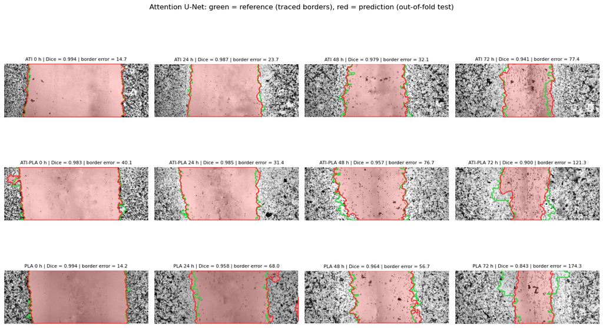

**Figure caption (English):** Out-of-fold segmentations of Attention U-Net for all images (treatments in rows, time points in columns). Green, reference wound region from the manually traced borders; red, predicted wound region. Each image was predicted by the model trained in the cross-validation fold in which that image was held out. Panel titles give the Dice coefficient and the mean border-position error (µm).

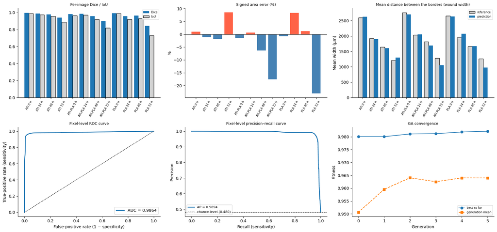

**Figure caption (English):** Per-image performance of Attention U-Net on the held-out images. Top row, left to right: Dice coefficient and IoU; signed relative error of the wound area; mean wound width of the reference and the prediction. Bottom row: pixel-level ROC curve and precision–recall curve pooled over all out-of-fold images (with the area under the ROC curve and the average precision), and convergence of the genetic algorithm (best fitness so far and mean fitness per generation).

```
↺ Klasik (Varyans+Otsu): kayıtlı sonuç başka referans/ayarlarla üretilmiş (ör. eski sözde-etiketler) → kullanılmıyor, yeniden eğitiliyor.

==========================================================================================
▶ Klasik (Varyans+Otsu) (Önerilen: Klasik) — GA protokolü: nested | parmak izi f187dd58140ffe931
==========================================================================================
   [Klasik (Varyans+Otsu) [dış katlama 0]] nesil 0: en iyi=0.8774  ort=0.7943  (genel en iyi=0.8774, önbellek=8, geçen 0.0 dk)
   [Klasik (Varyans+Otsu) [dış katlama 0]] nesil 1: en iyi=0.9000  ort=0.8786  (genel en iyi=0.9000, önbellek=14, geçen 0.0 dk)
   [Klasik (Varyans+Otsu) [dış katlama 0]] nesil 2: en iyi=0.9087  ort=0.8612  (genel en iyi=0.9087, önbellek=20, geçen 0.0 dk)
   [Klasik (Varyans+Otsu) [dış katlama 0]] nesil 3: en iyi=0.9087  ort=0.8963  (genel en iyi=0.9087, önbellek=24, geçen 0.0 dk)
   [Klasik (Varyans+Otsu) [dış katlama 0]] nesil 4: en iyi=0.9091  ort=0.8965  (genel en iyi=0.9091, önbellek=30, geçen 0.0 dk)
   [Klasik (Varyans+Otsu) [dış katlama 0]] nesil 5: en iyi=0.9145  ort=0.9089  (genel en iyi=0.9145, önbellek=36, geçen 0.0 dk)
   katlama 0: eğitim 0.0s × 1 tohum, çıkarım 0.01s/görüntü | ⏱️ bu katlama 0.0 dk, Klasik (Varyans+Otsu) için kalan ≈ 0.0 saat
   [Klasik (Varyans+Otsu) [dış katlama 1]] nesil 0: en iyi=0.9569  ort=0.9201  (genel en iyi=0.9569, önbellek=8, geçen 0.0 dk)
   [Klasik (Varyans+Otsu) [dış katlama 1]] nesil 1: en iyi=0.9569  ort=0.9485  (genel en iyi=0.9569, önbellek=13, geçen 0.0 dk)
   [Klasik (Varyans+Otsu) [dış katlama 1]] nesil 2: en iyi=0.9574  ort=0.9538  (genel en iyi=0.9574, önbellek=18, geçen 0.0 dk)
   [Klasik (Varyans+Otsu) [dış katlama 1]] nesil 3: en iyi=0.9584  ort=0.9568  (genel en iyi=0.9584, önbellek=23, geçen 0.0 dk)
   [Klasik (Varyans+Otsu) [dış katlama 1]] nesil 4: en iyi=0.9584  ort=0.9542  (genel en iyi=0.9584, önbellek=29, geçen 0.0 dk)
   [Klasik (Varyans+Otsu) [dış katlama 1]] nesil 5: en iyi=0.9600  ort=0.9504  (genel en iyi=0.9600, önbellek=34, geçen 0.0 dk)
   katlama 1: eğitim 0.0s × 1 tohum, çıkarım 0.01s/görüntü | ⏱️ bu katlama 0.0 dk, Klasik (Varyans+Otsu) için kalan ≈ 0.0 saat
   [Klasik (Varyans+Otsu) [dış katlama 2]] nesil 0: en iyi=0.9555  ort=0.9199  (genel en iyi=0.9555, önbellek=8, geçen 0.0 dk)
   [Klasik (Varyans+Otsu) [dış katlama 2]] nesil 1: en iyi=0.9572  ort=0.9382  (genel en iyi=0.9572, önbellek=14, geçen 0.0 dk)
   [Klasik (Varyans+Otsu) [dış katlama 2]] nesil 2: en iyi=0.9572  ort=0.9451  (genel en iyi=0.9572, önbellek=19, geçen 0.0 dk)
   [Klasik (Varyans+Otsu) [dış katlama 2]] nesil 3: en iyi=0.9588  ort=0.9486  (genel en iyi=0.9588, önbellek=24, geçen 0.0 dk)
   [Klasik (Varyans+Otsu) [dış katlama 2]] nesil 4: en iyi=0.9588  ort=0.9521  (genel en iyi=0.9588, önbellek=29, geçen 0.0 dk)
   [Klasik (Varyans+Otsu) [dış katlama 2]] nesil 5: en iyi=0.9601  ort=0.9560  (genel en iyi=0.9601, önbellek=35, geçen 0.0 dk)
   katlama 2: eğitim 0.0s × 1 tohum, çıkarım 0.01s/görüntü | ⏱️ bu katlama 0.0 dk, Klasik (Varyans+Otsu) için kalan ≈ 0.0 saat
   [Klasik (Varyans+Otsu) [dış katlama 3]] nesil 0: en iyi=0.9592  ort=0.9149  (genel en iyi=0.9592, önbellek=8, geçen 0.0 dk)
   [Klasik (Varyans+Otsu) [dış katlama 3]] nesil 1: en iyi=0.9592  ort=0.9362  (genel en iyi=0.9592, önbellek=14, geçen 0.0 dk)
   [Klasik (Varyans+Otsu) [dış katlama 3]] nesil 2: en iyi=0.9592  ort=0.9532  (genel en iyi=0.9592, önbellek=20, geçen 0.0 dk)
   [Klasik (Varyans+Otsu) [dış katlama 3]] nesil 3: en iyi=0.9612  ort=0.9484  (genel en iyi=0.9612, önbellek=26, geçen 0.0 dk)
   [Klasik (Varyans+Otsu) [dış katlama 3]] nesil 4: en iyi=0.9612  ort=0.9414  (genel en iyi=0.9612, önbellek=32, geçen 0.0 dk)
   [Klasik (Varyans+Otsu) [dış katlama 3]] nesil 5: en iyi=0.9612  ort=0.9460  (genel en iyi=0.9612, önbellek=37, geçen 0.0 dk)
   katlama 3: eğitim 0.0s × 1 tohum, çıkarım 0.01s/görüntü | ⏱️ bu katlama 0.0 dk, Klasik (Varyans+Otsu) için kalan ≈ 0.0 saat
✔ Klasik (Varyans+Otsu) tamamlandı: 0.1 dk | GPU'da aynı anda en fazla 2 eğitim
```

📊 Klasik (Varyans+Otsu) — *Önerilen: Klasik*

```
En iyi hiperparametreler: {'win': 7, 'thr_mult': 0.768068, 'morph_r': 6, 'smooth': 0.315598}
```

|  | file | drug | time_h | Dice | IoU | Precision | Recall | Specificity | Accuracy | MCC | AUC | AP | AreaErr_pct | BorderMAE | WidthErr_pct | MergeAgree |
| --- | --- | --- | --- | --- | --- | --- | --- | --- | --- | --- | --- | --- | --- | --- | --- | --- |
| 0 | 0_ati.jpeg | ati | 0.0 | 0.9893 | 0.9788 | 1.0000 | 0.9788 | 1.0000 | 0.9860 | 0.9697 | 0.9894 | 0.9928 | -2.1154 | 26.9301 | -2.0715 | 1.0 |
| 1 | 24_ati.jpeg | ati | 24.0 | 0.9777 | 0.9564 | 0.9666 | 0.9890 | 0.9678 | 0.9781 | 0.9564 | 0.9784 | 0.9613 | 2.3156 | 42.4718 | 2.3574 | 1.0 |
| 2 | 48_ati.jpeg | ati | 48.0 | 0.9507 | 0.9060 | 0.9971 | 0.9084 | 0.9981 | 0.9609 | 0.9211 | 0.9532 | 0.9437 | -8.8981 | 76.6775 | -8.8955 | 1.0 |
| 3 | 72_atı.jpeg | ati | 72.0 | 0.8403 | 0.7246 | 0.7254 | 0.9986 | 0.8348 | 0.8846 | 0.7771 | 0.9167 | 0.7248 | 37.6700 | 228.0130 | 37.6116 | 1.0 |
| 4 | 0_ap.jpeg | ap | 0.0 | 0.9697 | 0.9411 | 1.0000 | 0.9411 | 1.0000 | 0.9590 | 0.9105 | 0.9706 | 0.9822 | -5.8860 | 80.9536 | -5.8579 | 1.0 |
| 5 | 24_ap.jpeg | ap | 24.0 | 0.9850 | 0.9704 | 0.9965 | 0.9737 | 0.9964 | 0.9847 | 0.9697 | 0.9851 | 0.9839 | -2.2859 | 33.2121 | -2.5460 | 1.0 |
| 6 | 48_ap.jpeg | ap | 48.0 | 0.9229 | 0.8569 | 0.9979 | 0.8585 | 0.9985 | 0.9343 | 0.8738 | 0.9285 | 0.9215 | -13.9718 | 129.4412 | -13.9114 | 1.0 |
| 7 | 72_ap.jpeg | ap | 72.0 | 0.8646 | 0.7615 | 0.7886 | 0.9567 | 0.8775 | 0.9031 | 0.7992 | 0.9171 | 0.7685 | 21.3118 | 164.2428 | 17.2636 | 1.0 |
| 8 | 0_control.jpeg | PLA | 0.0 | 0.9821 | 0.9648 | 1.0000 | 0.9648 | 1.0000 | 0.9764 | 0.9488 | 0.9824 | 0.9884 | -3.5213 | 46.0610 | -3.4631 | 1.0 |
| 9 | 24_control.jpeg | PLA | 24.0 | 0.9460 | 0.8976 | 0.9025 | 0.9940 | 0.8961 | 0.9442 | 0.8930 | 0.9450 | 0.9000 | 10.1342 | 106.9059 | 9.9338 | 1.0 |
| 10 | 48_control.jpeg | PLA | 48.0 | 0.9233 | 0.8575 | 0.9951 | 0.8611 | 0.9970 | 0.9401 | 0.8807 | 0.9290 | 0.9151 | -13.4625 | 121.6062 | -13.9560 | 1.0 |
| 11 | 72_control.jpeg | PLA | 72.0 | 0.8451 | 0.7317 | 0.7603 | 0.9510 | 0.8595 | 0.8887 | 0.7715 | 0.9053 | 0.7387 | 25.0812 | 257.4677 | 10.5715 | 1.0 |

```
Ortalama ± SS:  Dice=0.9331±0.0550  IoU=0.8789±0.0939  F1=0.9331±0.0550  Precision=0.9275±0.1067  Recall=0.9480±0.0482  Accuracy=0.9450±0.0363  AUC=0.9501±0.0304  AbsAreaErr_pct=12.2211±10.9977  BorderMAE=109.4986±75.3987  MergeAgree=1.0000±0.0000
(Sınır/genişlik birimi: µm)
```

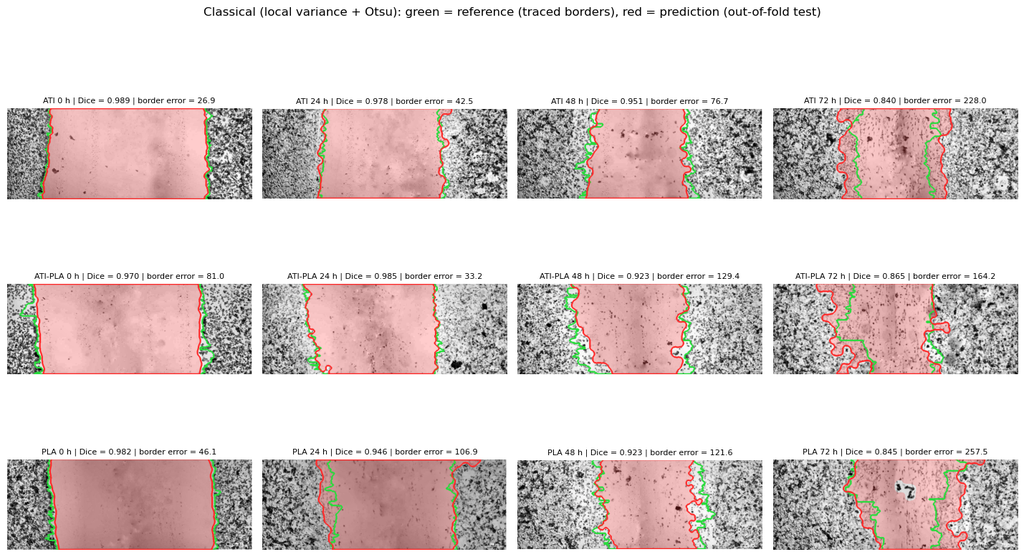

**Figure caption (English):** Out-of-fold segmentations of Classical (local variance + Otsu) for all images (treatments in rows, time points in columns). Green, reference wound region from the manually traced borders; red, predicted wound region. Each image was predicted by the model trained in the cross-validation fold in which that image was held out. Panel titles give the Dice coefficient and the mean border-position error (µm).

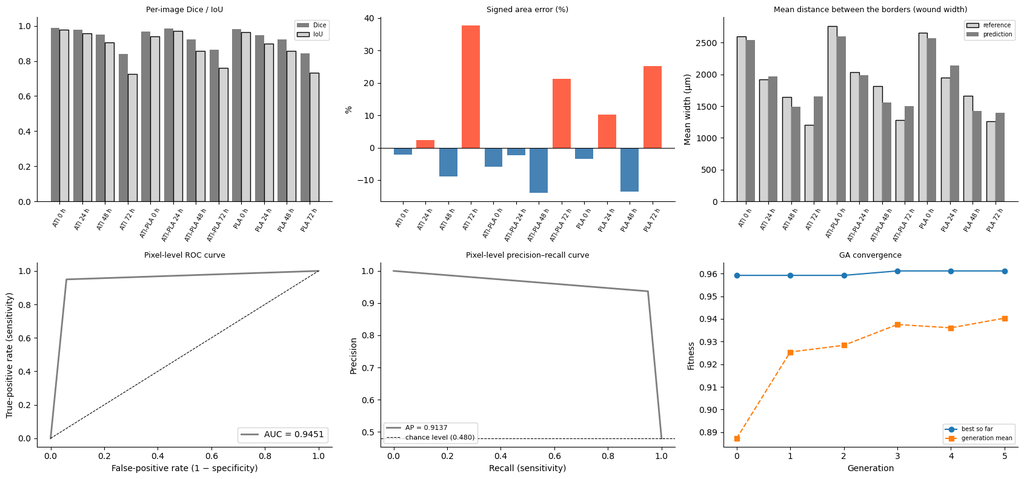

**Figure caption (English):** Per-image performance of Classical (local variance + Otsu) on the held-out images. Top row, left to right: Dice coefficient and IoU; signed relative error of the wound area; mean wound width of the reference and the prediction. Bottom row: pixel-level ROC curve and precision–recall curve pooled over all out-of-fold images (with the area under the ROC curve and the average precision), and convergence of the genetic algorithm (best fitness so far and mean fitness per generation).

```
↺ U-Net: kayıtlı sonuç başka referans/ayarlarla üretilmiş (ör. eski sözde-etiketler) → kullanılmıyor, yeniden eğitiliyor.

==========================================================================================
▶ U-Net (CNN) — GA protokolü: nested | parmak izi fd345026f3437bbb5
==========================================================================================
   🧮 VRAM [U-Net]: taban 0.47 GB + 110 MB/örnek (yama 320) | bütçe 2.72 GB / toplam 4.0 GB | varsayılan hp ile tek eğitim ≈ 1.02 GB → aynı anda ≈ 2 eğitim sığar
   [U-Net [dış katlama 0]] nesil 0: en iyi=0.9346  ort=0.9195  (genel en iyi=0.9346, önbellek=8, geçen 22.0 dk)
   [U-Net [dış katlama 0]] nesil 1: en iyi=0.9429  ort=0.9343  (genel en iyi=0.9429, önbellek=14, geçen 37.8 dk)
   [U-Net [dış katlama 0]] nesil 2: en iyi=0.9429  ort=0.9274  (genel en iyi=0.9429, önbellek=20, geçen 57.3 dk)
   [U-Net [dış katlama 0]] nesil 3: en iyi=0.9429  ort=0.9289  (genel en iyi=0.9429, önbellek=26, geçen 75.8 dk)
   [U-Net [dış katlama 0]] nesil 4: en iyi=0.9429  ort=0.9305  (genel en iyi=0.9429, önbellek=32, geçen 92.5 dk)
   katlama 0: eğitim 1239.7s × 3 tohum, çıkarım 0.32s/görüntü | ⏱️ bu katlama 129.9 dk, U-Net için kalan ≈ 6.5 saat
   [U-Net [dış katlama 1]] nesil 0: en iyi=0.9740  ort=0.9581  (genel en iyi=0.9740, önbellek=8, geçen 18.9 dk)
   [U-Net [dış katlama 1]] nesil 1: en iyi=0.9740  ort=0.9692  (genel en iyi=0.9740, önbellek=14, geçen 38.5 dk)
   [U-Net [dış katlama 1]] nesil 2: en iyi=0.9788  ort=0.9679  (genel en iyi=0.9788, önbellek=19, geçen 52.6 dk)
   [U-Net [dış katlama 1]] nesil 3: en iyi=0.9788  ort=0.9726  (genel en iyi=0.9788, önbellek=25, geçen 71.4 dk)
   [U-Net [dış katlama 1]] nesil 4: en iyi=0.9812  ort=0.9773  (genel en iyi=0.9812, önbellek=31, geçen 85.8 dk)
   [U-Net [dış katlama 1]] nesil 5: en iyi=0.9812  ort=0.9759  (genel en iyi=0.9812, önbellek=37, geçen 102.6 dk)
   katlama 1: eğitim 1388.9s × 3 tohum, çıkarım 0.20s/görüntü | ⏱️ bu katlama 144.2 dk, U-Net için kalan ≈ 4.6 saat
   [U-Net [dış katlama 2]] nesil 0: en iyi=0.9823  ort=0.9761  (genel en iyi=0.9823, önbellek=8, geçen 18.1 dk)
   [U-Net [dış katlama 2]] nesil 1: en iyi=0.9823  ort=0.9799  (genel en iyi=0.9823, önbellek=14, geçen 36.2 dk)
   [U-Net [dış katlama 2]] nesil 2: en iyi=0.9823  ort=0.9804  (genel en iyi=0.9823, önbellek=20, geçen 54.6 dk)
   [U-Net [dış katlama 2]] nesil 3: en iyi=0.9828  ort=0.9778  (genel en iyi=0.9828, önbellek=26, geçen 82.2 dk)
   [U-Net [dış katlama 2]] nesil 4: en iyi=0.9828  ort=0.9797  (genel en iyi=0.9828, önbellek=32, geçen 116.0 dk)
   [U-Net [dış katlama 2]] nesil 5: en iyi=0.9828  ort=0.9806  (genel en iyi=0.9828, önbellek=38, geçen 150.0 dk)
   katlama 2: eğitim 1671.4s × 3 tohum, çıkarım 0.20s/görüntü | ⏱️ bu katlama 233.8 dk, U-Net için kalan ≈ 2.8 saat
   [U-Net [dış katlama 3]] nesil 0: en iyi=0.9766  ort=0.9674  (genel en iyi=0.9766, önbellek=8, geçen 19.9 dk)
   [U-Net [dış katlama 3]] nesil 1: en iyi=0.9789  ort=0.9741  (genel en iyi=0.9789, önbellek=14, geçen 37.4 dk)
   [U-Net [dış katlama 3]] nesil 2: en iyi=0.9831  ort=0.9781  (genel en iyi=0.9831, önbellek=20, geçen 56.9 dk)
   [U-Net [dış katlama 3]] nesil 3: en iyi=0.9831  ort=0.9793  (genel en iyi=0.9831, önbellek=26, geçen 75.3 dk)
   [U-Net [dış katlama 3]] nesil 4: en iyi=0.9831  ort=0.9796  (genel en iyi=0.9831, önbellek=32, geçen 87.1 dk)
   [U-Net [dış katlama 3]] nesil 5: en iyi=0.9831  ort=0.9791  (genel en iyi=0.9831, önbellek=38, geçen 100.2 dk)
   katlama 3: eğitim 945.4s × 3 tohum, çıkarım 0.27s/görüntü | ⏱️ bu katlama 128.9 dk, U-Net için kalan ≈ 0.0 saat
✔ U-Net tamamlandı: 637.1 dk | GPU'da aynı anda en fazla 2 eğitim
```

📊 U-Net — *CNN*

```
En iyi hiperparametreler: {'lr': 0.000443, 'wd': 0.01, 'bs': 12, 'patch': 256, 'dice_w': 0.769506, 'gamma': 1.346653, 'aug': 0.489547, 'bnd': 0.268915, 'enc_lr_mult': 0.73547, 'thr': 0.415841, 'thr_mode': 'otsu'}
```

|  | file | drug | time_h | Dice | IoU | Precision | Recall | Specificity | Accuracy | MCC | AUC | AP | AreaErr_pct | BorderMAE | WidthErr_pct | MergeAgree | Dice_seed_sd |
| --- | --- | --- | --- | --- | --- | --- | --- | --- | --- | --- | --- | --- | --- | --- | --- | --- | --- |
| 0 | 0_ati.jpeg | ati | 0.0 | 0.9962 | 0.9924 | 0.9941 | 0.9982 | 0.9886 | 0.9949 | 0.9887 | 0.9999 | 1.0000 | 0.4088 | 9.7506 | 0.4538 | 1.0 | 0.0003 |
| 1 | 24_ati.jpeg | ati | 24.0 | 0.9894 | 0.9790 | 0.9927 | 0.9860 | 0.9932 | 0.9897 | 0.9794 | 0.9997 | 0.9997 | -0.6765 | 20.0495 | -0.6629 | 1.0 | 0.0001 |
| 2 | 48_ati.jpeg | ati | 48.0 | 0.9778 | 0.9565 | 0.9870 | 0.9687 | 0.9910 | 0.9818 | 0.9624 | 0.9984 | 0.9979 | -1.8553 | 34.7132 | -1.9744 | 1.0 | 0.0005 |
| 3 | 72_atı.jpeg | ati | 72.0 | 0.9458 | 0.8973 | 0.9196 | 0.9736 | 0.9628 | 0.9661 | 0.9220 | 0.9937 | 0.9847 | 5.8679 | 70.1626 | 5.7961 | 1.0 | 0.0016 |
| 4 | 0_ap.jpeg | ap | 0.0 | 0.9824 | 0.9655 | 0.9910 | 0.9740 | 0.9796 | 0.9757 | 0.9435 | 0.9975 | 0.9989 | -1.7062 | 41.1855 | -2.5151 | 1.0 | 0.0000 |
| 5 | 24_ap.jpeg | ap | 24.0 | 0.9867 | 0.9737 | 0.9857 | 0.9877 | 0.9848 | 0.9863 | 0.9725 | 0.9989 | 0.9990 | 0.2056 | 28.4305 | 0.2768 | 1.0 | 0.0008 |
| 6 | 48_ap.jpeg | ap | 48.0 | 0.9666 | 0.9354 | 0.9894 | 0.9448 | 0.9915 | 0.9701 | 0.9404 | 0.9975 | 0.9973 | -4.5071 | 61.4623 | -4.7515 | 1.0 | 0.0019 |
| 7 | 72_ap.jpeg | ap | 72.0 | 0.8982 | 0.8152 | 0.9965 | 0.8176 | 0.9986 | 0.9401 | 0.8648 | 0.9905 | 0.9847 | -17.9473 | 126.2247 | -19.1301 | 1.0 | 0.0089 |
| 8 | 0_control.jpeg | PLA | 0.0 | 0.9940 | 0.9880 | 0.9978 | 0.9901 | 0.9956 | 0.9919 | 0.9819 | 0.9996 | 0.9998 | -0.7688 | 13.8653 | -0.7089 | 1.0 | 0.0002 |
| 9 | 24_control.jpeg | PLA | 24.0 | 0.9750 | 0.9513 | 0.9565 | 0.9943 | 0.9562 | 0.9749 | 0.9506 | 0.9983 | 0.9982 | 3.9459 | 46.0016 | 3.8399 | 1.0 | 0.0009 |
| 10 | 48_control.jpeg | PLA | 48.0 | 0.9701 | 0.9420 | 0.9680 | 0.9723 | 0.9768 | 0.9749 | 0.9486 | 0.9979 | 0.9972 | 0.4477 | 45.5448 | -0.4227 | 1.0 | 0.0028 |
| 11 | 72_control.jpeg | PLA | 72.0 | 0.8450 | 0.7315 | 0.9690 | 0.7491 | 0.9888 | 0.9123 | 0.7978 | 0.9722 | 0.9528 | -22.6902 | 172.5482 | -22.5922 | 1.0 | 0.0051 |

```
Ortalama ± SS:  Dice=0.9606±0.0452  IoU=0.9273±0.0784  F1=0.9606±0.0452  Precision=0.9789±0.0227  Recall=0.9464±0.0788  Accuracy=0.9716±0.0237  AUC=0.9953±0.0078  AbsAreaErr_pct=5.0856±7.4145  BorderMAE=55.8282±48.2360  MergeAgree=1.0000±0.0000
(Sınır/genişlik birimi: µm)
```

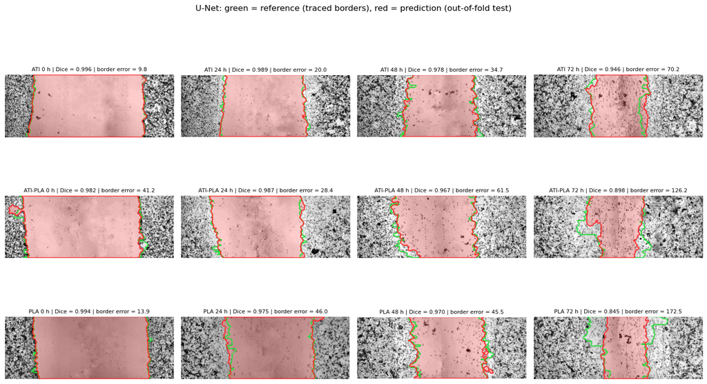

**Figure caption (English):** Out-of-fold segmentations of U-Net for all images (treatments in rows, time points in columns). Green, reference wound region from the manually traced borders; red, predicted wound region. Each image was predicted by the model trained in the cross-validation fold in which that image was held out. Panel titles give the Dice coefficient and the mean border-position error (µm).

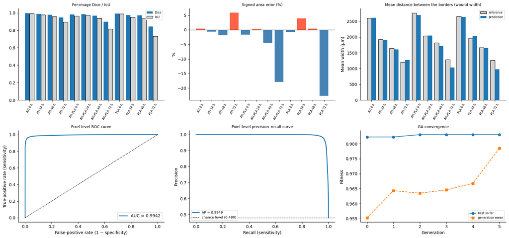

**Figure caption (English):** Per-image performance of U-Net on the held-out images. Top row, left to right: Dice coefficient and IoU; signed relative error of the wound area; mean wound width of the reference and the prediction. Bottom row: pixel-level ROC curve and precision–recall curve pooled over all out-of-fold images (with the area under the ROC curve and the average precision), and convergence of the genetic algorithm (best fitness so far and mean fitness per generation).

```
Tamamlanan modeller: ['Attention U-Net', 'Klasik (Varyans+Otsu)', 'U-Net']
```

```python
FAILED = {}
for spec in SPECS:
    try:
        run_model(spec)
    except Exception as ex:
        import traceback
        FAILED[spec.name] = f"{type(ex).__name__}: {ex}"
        print(f"✖ {spec.name} atlandı → {FAILED[spec.name]}")
        traceback.print_exc(limit=2)
        if DEVICE.type == "cuda":
            torch.cuda.empty_cache()
MONITOR.set_stage("analiz")
print("\nTamamlanan modeller:", list(RESULTS))
if FAILED:
    print("Atlanan modeller:", FAILED)
```

### 10.2 Önerdiğim ek model: Topluluk (Ensemble, Top-3 soft voting)

En iyi 3 model, **test sonuçlarına göre değil GA doğrulama uygunluğuna göre** seçilir (test kümesine göre seçim yapmak iyimser yanlılık yaratırdı). OOF olasılık haritalarının ortalaması alınır ve 0.5 eşiği uygulanır. Sözde-etiket kullanılıyorsa klasik yöntem topluluğa dahil edilmez.

```python
def _eligible(n):
    s = spec_of(n)
    return s is not None and not (GT_IS_PSEUDO and s.kind == "classical")

cands = sorted([n for n in RESULTS if _eligible(n) and np.isfinite(GA_FIT.get(n, np.nan))], key=lambda n: -GA_FIT[n])[:3]
if not CFG.get("ENSEMBLE", True):
    print("⏭ Topluluk (ensemble) kapalı (ayar: TOPLULUK = False).")
elif len(cands) >= 2:
    ENS_NAME = "Ensemble (Top-3)"
    OOF[ENS_NAME] = {i: np.mean([OOF[n][i] for n in cands], 0) for i in ALL_IDX}
    RESULTS[ENS_NAME] = metrics_table(OOF[ENS_NAME], lambda i: {"thr": 0.5})
    BEST_HP[ENS_NAME] = {"üyeler": cands, "thr": 0.5}; GA_FIT[ENS_NAME] = np.nan
    INFO[ENS_NAME] = dict(params_M=sum(INFO[n]["params_M"] for n in cands), train_s=sum(INFO[n]["train_s"] for n in cands),
                          infer_s=sum(INFO[n]["infer_s"] for n in cands), total_min=0)
    EXTRA_SPECS[ENS_NAME] = ModelSpec(ENS_NAME, "Ensemble", "ensemble", ref="soft voting")
    print("Topluluk üyeleri (GA uygunluğuna göre):", cands)
    show_model_results(EXTRA_SPECS[ENS_NAME], RESULTS[ENS_NAME], None, BEST_HP[ENS_NAME])
    RESULTS[ENS_NAME].to_csv(DIRS["tables"] / "cv_Ensemble.csv", index=False)
else:
    print("Topluluk için en az 2 model gerekli.")
```

```
⏭ Topluluk (ensemble) kapalı (ayar: TOPLULUK = False).
```

### 10.3 Yarı-denetimli öz-eğitim (SSL) ablasyonu — Ramesh vd. (2017)'den esinlenerek

Ramesh, Liu & Tasdizen (2017), az etiketli veride **etiketsiz test görüntülerini de öğrenmeye katmanın** (transdüktif yarı-denetimli öğrenme) F-skorunu belirgin artırdığını göstermiştir. Burada aynı fikri segmentasyona uyguluyoruz:

1. Model, eğitim görüntüleriyle normal şekilde eğitilir (aynı GA hiperparametreleri).
2. Test görüntüleri **etiketleri hiç kullanılmadan** tahmin edilir; yalnızca çok emin olunan pikseller (p ≥ τ = 0.9 veya p ≤ 0.1) sözde-etiket olur.
3. Model, etiketli + sözde-etiketli yamalarla kısa bir ince ayar yapar (düşük öğrenme oranı), sonra test görüntüleri yeniden tahmin edilir.

GA doğrulama başarısı en yüksek `top_k` derin model için "Model" ve "Model + SSL" eşleştirilmiş olarak karşılaştırılır (Wilcoxon işaretli sıra testi). Test etiketleri hiçbir aşamada kullanılmadığından değerlendirme sızıntısızdır; makalede "transdüktif" olduğu belirtilmelidir.

```python
SSL_TABLE = pd.DataFrame()
if not CFG["SSL"]["enabled"]:
    print("⏭ SSL ablasyonu kapalı (ayar: SSL_ABLASYON = False).")
else:
    MONITOR.set_stage("SSL ablasyonu")
    base = sorted([n for n in RESULTS if spec_of(n) is not None and spec_of(n).kind == "torch"
                   and np.isfinite(GA_FIT.get(n, np.nan))], key=lambda n: -GA_FIT[n])[:CFG["SSL"]["top_k"]]
    rows = []
    for n in base:
        spec = spec_of(n); nm = f"{n} + SSL"; slug = safe_slug(nm)
        f_csv, f_npz = DIRS["tables"] / f"cv_{slug}.csv", DIRS["cache"] / f"oof_{slug}.npz"
        try:
            f_js = DIRS["cache"] / f"oof_{slug}.json"
            _ok = f_js.exists() and json.loads(f_js.read_text(encoding="utf-8")).get("fp") == run_fp(spec)
            if CFG["RESUME"] and f_csv.exists() and f_npz.exists() and _ok:
                RESULTS[nm] = pd.read_csv(f_csv); z = np.load(f_npz)
                OOF[nm] = {int(k[1:]): z[k].astype(np.float32) for k in z.files}
                if any(c not in RESULTS[nm].columns for c in METRIC_COLS):
                    RESULTS[nm] = metrics_table(OOF[nm], lambda i, n=n: FOLD_HP[n][fold_of(i)])
                conf = np.nan
            else:
                oof, confs, t0 = {}, [], time.time()
                for f, te in enumerate(OUTER_FOLDS):
                    tr = sorted(set(ALL_IDX) - set(te))
                    probs, info = fit_predict(spec, FOLD_HP[n][f], tr, te, iters=CFG["TRAIN_ITERS"], seed=CFG["SEED"] + f,
                                              tta=CFG["USE_TTA"], ssl=CFG["SSL"])
                    oof.update(probs); confs.append(info.get("ssl_conf_frac", np.nan))
                OOF[nm] = oof; conf = float(np.nanmean(confs))
                RESULTS[nm] = metrics_table(oof, lambda i, n=n: FOLD_HP[n][fold_of(i)])
                RESULTS[nm].to_csv(f_csv, index=False)
                np.savez_compressed(f_npz, **{f"i{i}": oof[i].astype(np.float16) for i in oof})
                f_js.write_text(json.dumps(dict(fp=run_fp(spec))), encoding="utf-8")
            BEST_HP[nm] = dict(BEST_HP[n], ssl=CFG["SSL"]); GA_FIT[nm] = np.nan
            INFO[nm] = dict(INFO[n]); FOLD_HP[nm] = FOLD_HP[n]
            EXTRA_SPECS[nm] = ModelSpec(nm, spec.family, "ssl", ref="self-training")
            a, b = RESULTS[n].sort_values("idx"), RESULTS[nm].sort_values("idx")
            try:
                p = stats.wilcoxon(b["Dice"].values, a["Dice"].values, zero_method="zsplit").pvalue
            except ValueError:
                p = 1.0
            rows.append(dict(Model=n, Dice=a["Dice"].mean(), Dice_SSL=b["Dice"].mean(), ΔDice=b["Dice"].mean() - a["Dice"].mean(),
                             AUC=a["AUC"].mean(), AUC_SSL=b["AUC"].mean(), BorderMAE=a["BorderMAE"].mean(),
                             BorderMAE_SSL=b["BorderMAE"].mean(), güvenli_piksel_oranı=conf, p_Wilcoxon=p))
            show_model_results(EXTRA_SPECS[nm], RESULTS[nm], None, BEST_HP[nm])
        except Exception as ex:
            print(f"✖ {nm} atlandı → {type(ex).__name__}: {ex}")
    SSL_TABLE = pd.DataFrame(rows)
    if len(SSL_TABLE):
        display(Markdown("**SSL ablasyonu: aynı model, aynı hiperparametreler — öz-eğitimli ve öz-eğitimsiz**"))
        display(SSL_TABLE.round(4)); SSL_TABLE.to_csv(DIRS["tables"] / "ssl_ablation.csv", index=False)
```

```
⏭ SSL ablasyonu kapalı (ayar: SSL_ABLASYON = False).
```

## 11. Tüm modellerin birlikte karşılaştırılması

- **Özet tablo** (ortalama ± standart sapma, 12 katlama-dışı test görüntüsü): Dice, IoU, F1, F1-macro, Precision, Recall, Specificity, Accuracy, Balanced Accuracy, MCC, κ, **ROC–AUC, PR–AP**, HD95, alan hatası, **sınır konum hatası, genişlik hatası, birleşme uyumu**; ayrıca parametre sayısı, eğitim ve çıkarım süreleri.
- **ROC ve PR eğrileri:** tüm modeller aynı grafikte (piksel düzeyi, 12 OOF test görüntüsü birleştirilerek).
- **Biyolojik uyum (Rosoff vd. 2022 yaklaşımı):** her modelin yara alanı ve genişliği ile referans arasında **Pearson r (%99 güven aralığı)** ve **Lin uyum korelasyon katsayısı (CCC)**.
- **Grafikler:** Dice/IoU çubuk grafiği, görüntü başına Dice kutu grafiği, metrik ısı haritası, radar grafiği, alan uyumu (saçılım + Bland–Altman), kapanma eğrileri, nitel karşılaştırma ızgarası, verimlilik grafiği.
- **İstatistik:** Friedman testi (tüm modeller, eşleştirilmiş görüntüler) ve en iyi modele karşı Wilcoxon işaretli sıra testi (Holm düzeltmeli). n=12 olduğundan testlerin gücü sınırlıdır; etki büyüklükleriyle birlikte yorumlanmalıdır.

`†` işareti: sözde-etiket kullanıldığında klasik yöntem kendisiyle karşılaştırıldığı için sıralama dışıdır.

```python
def fam(n):
    s = spec_of(n)
    return s.family if s else ("Ensemble" if n.startswith("Ensemble") else "?")

def label(n):
    s = spec_of(n)
    return ML(n) + ("†" if (GT_IS_PSEUDO and s is not None and s.kind == "classical") else "")

names = list(RESULTS)
summ = []
for n in names:
    d = RESULTS[n]
    row = dict(Model=label(n), Aile=fam(n))
    for c in METRIC_COLS:
        row[c] = d[c].mean(); row[c + "_sd"] = d[c].std()
    row.update(GA_uygunluk=GA_FIT.get(n, np.nan), Param_M=INFO.get(n, {}).get("params_M", np.nan),
               Egitim_s=INFO.get(n, {}).get("train_s", np.nan), Cikarim_s=INFO.get(n, {}).get("infer_s", np.nan))
    summ.append(row)
SUMMARY = pd.DataFrame(summ).sort_values("Dice", ascending=False).reset_index(drop=True)
RANKABLE = [n for n in names if _eligible(n) or n.startswith("Ensemble")]
TOP_DICE = max(RANKABLE, key=lambda n: RESULTS[n]["Dice"].mean()) if RANKABLE else names[0]
print(f"🏆 En yüksek ortalama Dice: {TOP_DICE}  ({RESULTS[TOP_DICE]['Dice'].mean():.4f})")
_am = CFG.get("ANA_MODEL") or ""
if _am and _am not in RESULTS:
    print(f"⚠️ ANA_MODEL = {_am!r} sonuçlar arasında yok; en yüksek Dice'lı model kullanılacak.")
BEST = _am if _am in RESULTS else TOP_DICE
print(f"🎯 Sonraki analizlerde kullanılan ana model: {BEST}  (Dice = {RESULTS[BEST]['Dice'].mean():.4f})")

pretty = SUMMARY[["Model", "Aile"]].copy()
for c in ["Dice", "IoU", "F1", "F1_macro", "Precision", "Recall", "Specificity", "Accuracy", "BalancedAcc", "MCC", "Kappa",
          "AUC", "AP", "HD95_px", "AbsAreaErr_pct", "BorderMAE", "WidthMAE", "MergeAgree"]:
    pretty[c] = [f"{m:.3f} ± {s:.3f}" for m, s in zip(SUMMARY[c], SUMMARY[c + "_sd"])]
pretty["Param (M)"] = SUMMARY["Param_M"].round(2); pretty["Eğitim (s)"] = SUMMARY["Egitim_s"].round(1); pretty["Çıkarım (s/img)"] = SUMMARY["Cikarim_s"].round(2)
display(Markdown("**Tablo — Tüm modellerin katlama-dışı test performansı (ortalama ± SS, n = 12)**"))
display(pretty)
SUMMARY.to_csv(DIRS["tables"] / "summary_all_models.csv", index=False)
pretty.to_csv(DIRS["tables"] / "summary_all_models_pretty.csv", index=False)
```

```
🏆 En yüksek ortalama Dice: U-Net  (0.9606)
🎯 Sonraki analizlerde kullanılan ana model: Attention U-Net  (Dice = 0.9571)
```

**Tablo — Tüm modellerin katlama-dışı test performansı (ortalama ± SS, n = 12)**

|  | Model | Aile | Dice | IoU | F1 | F1_macro | Precision | Recall | Specificity | Accuracy | ... | AUC | AP | HD95_px | AbsAreaErr_pct | BorderMAE | WidthMAE | MergeAgree | Param (M) | Eğitim (s) | Çıkarım (s/img) |
| --- | --- | --- | --- | --- | --- | --- | --- | --- | --- | --- | --- | --- | --- | --- | --- | --- | --- | --- | --- | --- | --- |
| 0 | U-Net | CNN | 0.961 ± 0.045 | 0.927 ± 0.078 | 0.961 ± 0.045 | 0.968 ± 0.030 | 0.979 ± 0.023 | 0.946 ± 0.079 | 0.984 ± 0.013 | 0.972 ± 0.024 | ... | 0.995 ± 0.008 | 0.993 ± 0.014 | 47.155 ± 38.232 | 5.086 ± 7.414 | 55.828 ± 48.236 | 98.899 ± 96.824 | 1.000 ± 0.000 | 24.44 | 1311.4 | 2.94 |
| 1 | Attention U-Net | CNN | 0.957 ± 0.045 | 0.921 ± 0.078 | 0.957 ± 0.045 | 0.964 ± 0.030 | 0.973 ± 0.031 | 0.946 ± 0.080 | 0.978 ± 0.023 | 0.968 ± 0.024 | ... | 0.990 ± 0.019 | 0.982 ± 0.028 | 68.862 ± 72.059 | 5.979 ± 7.412 | 60.883 ± 47.609 | 109.921 ± 94.556 | 1.000 ± 0.000 | 23.92 | 1566.1 | 3.34 |
| 2 | Classical (local variance + Otsu) | Önerilen: Klasik | 0.933 ± 0.055 | 0.879 ± 0.094 | 0.933 ± 0.055 | 0.941 ± 0.040 | 0.928 ± 0.107 | 0.948 ± 0.048 | 0.952 ± 0.065 | 0.945 ± 0.036 | ... | 0.950 ± 0.030 | 0.902 ± 0.100 | 68.178 ± 38.158 | 12.221 ± 10.998 | 109.499 ± 75.399 | 200.654 ± 137.206 | 1.000 ± 0.000 | 0.00 | 0.0 | 0.01 |

3 rows × 23 columns

### 11.1 Dice / IoU çubuk grafiği, görüntü başına Dice kutu grafiği ve metrik ısı haritası

Renkler model ailesini gösterir (CNN, ViT, SAM, ViG, INR, MLP-Mixer, önerilen yöntemler). Hata çubukları 12 test görüntüsü üzerindeki standart sapmadır.

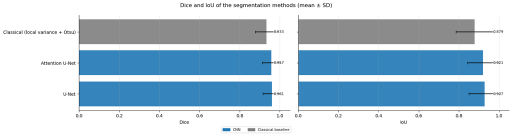

**Figure caption (English):** Dice coefficient (left) and IoU (right) of the segmentation methods (mean ± SD over the out-of-fold test images); colours indicate the method family.

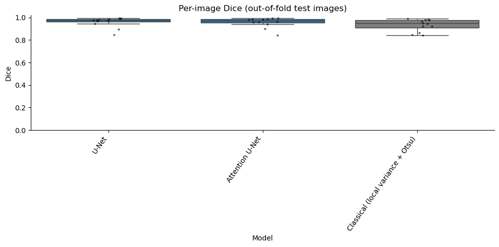

**Figure caption (English):** Distribution of the per-image Dice coefficient of each method on the out-of-fold test images (box, interquartile range and median; points, individual images).

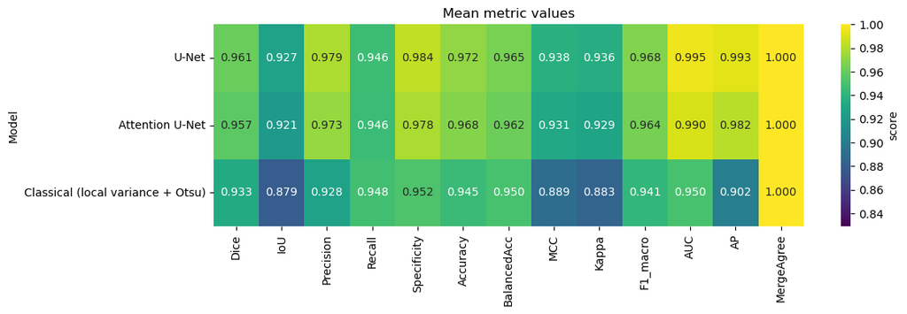

**Figure caption (English):** Mean out-of-fold value of each evaluation metric for each segmentation method.

```python
order = SUMMARY["Model"].tolist()
raw_of = {label(n): n for n in names}
cols = [FAMILY_COLORS.get(fam(raw_of[m]), "gray") for m in order]

fig, ax = plt.subplots(1, 2, figsize=(16, max(4, 0.42 * len(order) + 1.5)), sharey=True)
for a, met in zip(ax, ["Dice", "IoU"]):
    a.barh(order, SUMMARY[met], xerr=SUMMARY[met + "_sd"], color=cols, alpha=0.9, capsize=3)
    a.set_xlim(0, 1.05); a.set_xlabel(met); a.invert_yaxis(); a.grid(axis="x", alpha=0.3)
    for y, (v, sd) in enumerate(zip(SUMMARY[met], SUMMARY[met + "_sd"].fillna(0))):
        a.text(min(v + sd + 0.015, 0.97), y, f"{v:.3f}", va="center", fontsize=8,
               bbox=dict(boxstyle="round,pad=0.1", fc="white", ec="none", alpha=0.7))
handles = [plt.Rectangle((0, 0), 1, 1, color=c) for f, c in FAMILY_COLORS.items() if f in set(fam(n) for n in names)]
fig.legend(handles, [FL(f) for f in FAMILY_COLORS if f in set(fam(n) for n in names)], loc="lower center", ncol=5, fontsize=8, bbox_to_anchor=(0.5, -0.04))
fig.suptitle("Dice and IoU of the segmentation methods (mean ± SD)")
plt.tight_layout(); savefig("10_bar_dice_iou"); plt.show()

long = pd.concat([RESULTS[n].assign(Model=label(n)) for n in names])
plt.figure(figsize=(max(10, 0.7 * len(order)), 5))
sns.boxplot(data=long, x="Model", y="Dice", order=order, palette=dict(zip(order, cols)), showfliers=False)
sns.stripplot(data=long, x="Model", y="Dice", order=order, color="k", size=3, alpha=0.6)
plt.xticks(rotation=55, ha="right"); plt.ylim(0, 1.02); plt.title("Per-image Dice (out-of-fold test images)")
plt.tight_layout(); savefig("11_box_dice"); plt.show()

hm_cols = ["Dice", "IoU", "Precision", "Recall", "Specificity", "Accuracy", "BalancedAcc", "MCC", "Kappa", "F1_macro", "AUC", "AP", "MergeAgree"]
hm = SUMMARY.set_index("Model")[hm_cols]
plt.figure(figsize=(12, max(4, 0.4 * len(order) + 1)))
sns.heatmap(hm, annot=True, fmt=".3f", cmap="viridis", vmin=max(0, hm.values.min() - 0.05), vmax=1, cbar_kws={"label": "score"})
plt.title("Mean metric values"); plt.tight_layout(); savefig("12_heatmap_metrics"); plt.show()
```

### 11.1b ROC ve Precision–Recall eğrileri (tüm modeller)

Piksel düzeyinde, 12 katlama-dışı test görüntüsünün pikselleri birleştirilerek hesaplanır (hesap hızı için 2 pikselde 1 örnekleme). ROC–AUC eşikten bağımsız ayırt ediciliği; PR–AP ise yara pikselleri azınlıkta olduğunda (geç zaman noktaları) daha bilgilendirici olan kesinlik–duyarlılık dengesini özetler. Kesikli çizgiler şans düzeyidir. İkili çıktı veren yöntemlerde (klasik) eğri tek bir çalışma noktasından oluşur.

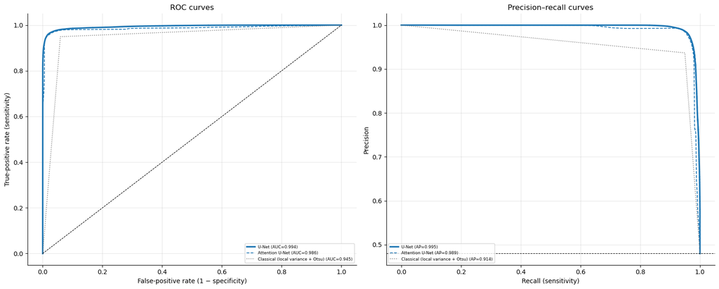

**Figure caption (English):** Pixel-level receiver operating characteristic (left) and precision–recall (right) curves of the segmentation methods, computed from the pooled out-of-fold probability maps. The legend gives the area under the ROC curve (AUC) and the average precision (AP); dashed lines indicate chance level. Methods that output binary masks appear as a single operating point.

|  | Model | Aile | AUC_havuz | AP_havuz | AUC_görüntü_ort | AUC_görüntü_ss |
| --- | --- | --- | --- | --- | --- | --- |
| 0 | U-Net | CNN | 0.9942 | 0.9949 | 0.9953 | 0.0078 |
| 1 | Attention U-Net | CNN | 0.9864 | 0.9894 | 0.9897 | 0.0191 |
| 2 | Classical (local variance + Otsu) | Önerilen: Klasik | 0.9451 | 0.9137 | 0.9501 | 0.0304 |

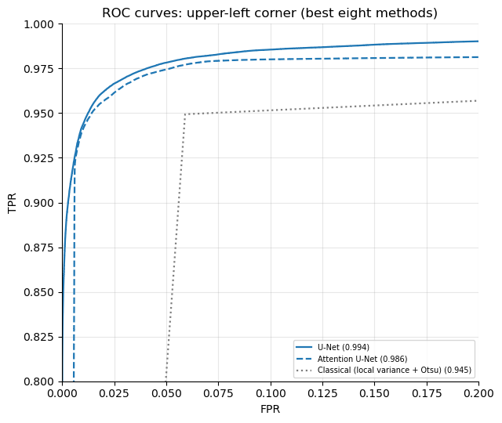

**Figure caption (English):** Enlargement of the upper-left corner of the ROC curves (false-positive rate 0–0.2, true-positive rate 0.8–1.0).

```python
for n in names:
    if n not in ROC_CACHE:
        ROC_CACHE[n] = pixel_roc_pr(OOF[n])
roc_order = sorted(names, key=lambda n: -ROC_CACHE[n]["auc"])
fig, ax = plt.subplots(1, 2, figsize=(16, 6.5))
for k, n in enumerate(roc_order):
    rc = ROC_CACHE[n]
    lw = 2.4 if n == roc_order[0] else 1.2
    c = FAMILY_COLORS.get(fam(n), None)
    ls = ["-", "--", ":", "-."][k % 4]
    ax[0].plot(rc["fpr"], rc["tpr"], lw=lw, ls=ls, color=c, label=f"{label(n)} (AUC={rc['auc']:.3f})")
    ax[1].plot(rc["rec"], rc["prec"], lw=lw, ls=ls, color=c, label=f"{label(n)} (AP={rc['ap']:.3f})")
ax[0].plot([0, 1], [0, 1], "k--", lw=0.8); ax[1].axhline(ROC_CACHE[roc_order[0]]["prevalence"], color="k", ls="--", lw=0.8)
ax[0].set_xlabel("False-positive rate (1 − specificity)"); ax[0].set_ylabel("True-positive rate (sensitivity)"); ax[0].set_title("ROC curves")
ax[1].set_xlabel("Recall (sensitivity)"); ax[1].set_ylabel("Precision"); ax[1].set_title("Precision–recall curves")
for a in ax:
    a.legend(fontsize=6.5, loc="lower right" if a is ax[0] else "lower left"); a.grid(alpha=0.3)
plt.tight_layout(); savefig("12b_roc_pr_all"); plt.show()
ROC_TABLE = pd.DataFrame([dict(Model=label(n), Aile=fam(n), AUC_havuz=ROC_CACHE[n]["auc"], AP_havuz=ROC_CACHE[n]["ap"],
                               AUC_görüntü_ort=RESULTS[n]["AUC"].mean(), AUC_görüntü_ss=RESULTS[n]["AUC"].std()) for n in roc_order])
display(ROC_TABLE.round(4)); ROC_TABLE.to_csv(DIRS["tables"] / "roc_pr_auc.csv", index=False)

# zoom: üst-sol köşe (iyi modeller arasındaki farklar burada görünür)
fig, a = plt.subplots(figsize=(6.5, 5.5))
for k, n in enumerate(roc_order[:8]):
    rc = ROC_CACHE[n]
    a.plot(rc["fpr"], rc["tpr"], lw=1.6, ls=["-", "--", ":", "-."][k % 4], color=FAMILY_COLORS.get(fam(n)), label=f"{label(n)} ({rc['auc']:.3f})")
a.set_xlim(0, 0.2); a.set_ylim(0.8, 1.0); a.set_xlabel("FPR"); a.set_ylabel("TPR"); a.legend(fontsize=7); a.grid(alpha=0.3)
a.set_title("ROC curves: upper-left corner (best eight methods)")
plt.tight_layout(); savefig("12c_roc_zoom"); plt.show()
```

### 11.1c Biyolojik uyum: alan ve genişlik için Pearson r (%99 GA) ve Lin CCC

Rosoff vd. (2022), yöntemi doğrulamak için alan eğrileri arasında Pearson korelasyonu (%99 güven aralığı) kullanmıştır. Pearson r yalnızca **doğrusal ilişkiyi** ölçer (sistematik yanlılığı yakalamaz); bu yüzden ayrıca **Lin CCC** (hem ilişki hem eşitlik) raporlanır. Değişkenler: görüntü başına yara alanı ve ortalama yara genişliği (n = 12).

```python
def pearson_ci(x, y, conf=0.99):
    x, y = np.asarray(x, float), np.asarray(y, float)
    ok = np.isfinite(x) & np.isfinite(y); x, y = x[ok], y[ok]
    if len(x) < 4 or np.std(x) == 0 or np.std(y) == 0:
        return np.nan, np.nan, np.nan, np.nan
    r, p = stats.pearsonr(x, y)
    z = np.arctanh(np.clip(r, -0.999999, 0.999999)); se = 1 / math.sqrt(len(x) - 3); zc = stats.norm.ppf(0.5 + conf / 2)
    return float(r), float(np.tanh(z - zc * se)), float(np.tanh(z + zc * se)), float(p)

def lin_ccc(x, y):
    x, y = np.asarray(x, float), np.asarray(y, float)
    mx, my = x.mean(), y.mean(); vx, vy = x.var(), y.var(); cov = ((x - mx) * (y - my)).mean()
    return float(2 * cov / (vx + vy + (mx - my) ** 2)) if (vx + vy) > 0 else np.nan

AGREE = []
for n in names:
    d = RESULTS[n].sort_values("idx")
    for var, a_, b_ in [("alan", "Area_GT", "Area_Pred"), ("genişlik", "Width_GT", "Width_Pred")]:
        r, lo, hi, p = pearson_ci(d[a_], d[b_])
        AGREE.append(dict(Model=label(n), değişken=var, r=r, r_alt99=lo, r_üst99=hi, p=p, CCC=lin_ccc(d[a_], d[b_])))
AGREE = pd.DataFrame(AGREE)
display(AGREE.pivot_table(index="Model", columns="değişken", values=["r", "r_alt99", "r_üst99", "CCC"]).round(4))
AGREE.to_csv(DIRS["tables"] / "agreement_pearson_ccc.csv", index=False)
```

| değişken Model | CCC alan | CCC genişlik | r alan | r genişlik | r_alt99 alan | r_alt99 genişlik | r_üst99 alan | r_üst99 genişlik |
| --- | --- | --- | --- | --- | --- | --- | --- | --- |
| Attention U-Net | 0.9735 | 0.9740 | 0.9796 | 0.9806 | 0.8916 | 0.8964 | 0.9963 | 0.9965 |
| Classical (local variance + Otsu) | 0.8910 | 0.9135 | 0.9091 | 0.9239 | 0.5807 | 0.6390 | 0.9830 | 0.9859 |
| U-Net | 0.9781 | 0.9768 | 0.9851 | 0.9846 | 0.9198 | 0.9171 | 0.9973 | 0.9972 |

### 11.2 Radar profili, alan uyumu ve Bland–Altman analizi

Radar grafiği en iyi 6 modelin çok boyutlu profilini gösterir. Bland–Altman grafiği, en iyi modelin yara alanını sistematik olarak fazla/az tahmin edip etmediğini (yanlılık) ve %95 uyum sınırlarını verir — biyolojik sonuç (kapanma %) doğrudan alana bağlı olduğu için makalede mutlaka yer almalıdır.

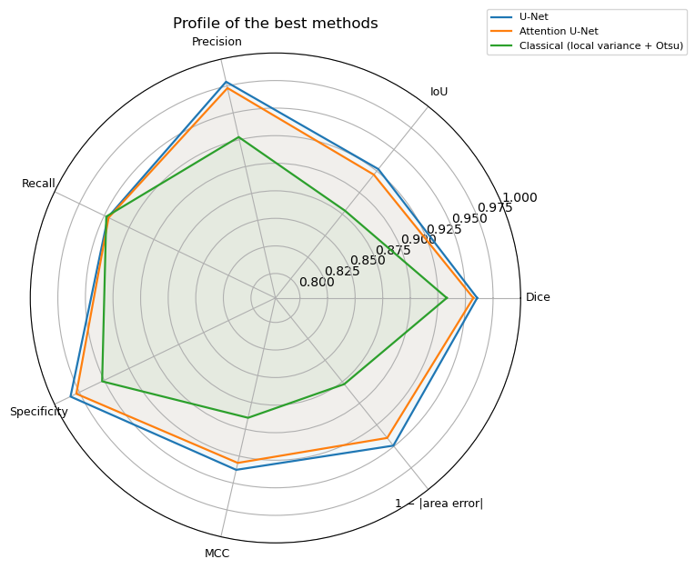

**Figure caption (English):** Multi-metric profile of the best-performing methods: Dice, IoU, precision, recall, specificity, Matthews correlation coefficient and 1 − absolute relative area error.

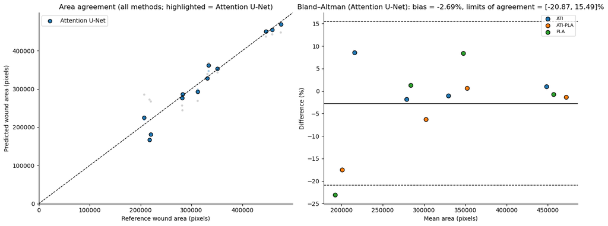

**Figure caption (English):** Agreement between automatically and manually derived wound areas. Left, predicted versus reference wound area for all methods (dashed line, identity; highlighted points, Attention U-Net). Right, Bland–Altman plot for Attention U-Net: relative difference against the mean of the two areas, with the mean bias (solid line) and the 95% limits of agreement (dashed lines); colours indicate the treatment.

```python
top = [label(n) for n in sorted(RANKABLE, key=lambda n: -RESULTS[n]["Dice"].mean())[:6]]
rad_cols = ["Dice", "IoU", "Precision", "Recall", "Specificity", "MCC"]
vals = SUMMARY.set_index("Model").loc[top, rad_cols].copy()
vals["1 − |area error|"] = 1 - (SUMMARY.set_index("Model").loc[top, "AbsAreaErr_pct"] / 100).clip(0, 1)
ang = np.linspace(0, 2 * np.pi, vals.shape[1], endpoint=False).tolist(); ang += ang[:1]
fig = plt.figure(figsize=(7, 7)); ax = fig.add_subplot(111, polar=True)
for m in top:
    v = vals.loc[m].tolist(); v += v[:1]
    ax.plot(ang, v, lw=1.6, label=m); ax.fill(ang, v, alpha=0.06)
ax.set_xticks(ang[:-1]); ax.set_xticklabels(vals.columns, fontsize=9)
ax.set_ylim(max(0, vals.values.min() - 0.1), 1.0)
ax.legend(loc="upper right", bbox_to_anchor=(1.35, 1.1), fontsize=8); ax.set_title("Profile of the best methods", pad=20)
savefig("13_radar_top"); plt.show()

# Alan uyumu ve Bland–Altman
fig, ax = plt.subplots(1, 2, figsize=(14, 5.5))
for n in names:
    d = RESULTS[n]
    ax[0].scatter(d["Area_GT"], d["Area_Pred"], s=14 if n != BEST else 40, alpha=0.35 if n != BEST else 1,
                  color=FAMILY_COLORS.get(fam(n), "gray"), label=label(n) if n == BEST else None, edgecolor="k" if n == BEST else "none")
lim = [0, max(long["Area_GT"].max(), long["Area_Pred"].max()) * 1.05]
ax[0].plot(lim, lim, "k--", lw=1); ax[0].set_xlim(lim); ax[0].set_ylim(lim)
ax[0].set_xlabel("Reference wound area (pixels)"); ax[0].set_ylabel("Predicted wound area (pixels)"); ax[0].legend()
ax[0].set_title(f"Area agreement (all methods; highlighted = {label(BEST)})")
d = RESULTS[BEST]; mean_a = (d["Area_GT"] + d["Area_Pred"]) / 2; diff = 100 * (d["Area_Pred"] - d["Area_GT"]) / d["Area_GT"].clip(lower=1)
md, sd = diff.mean(), diff.std()
ax[1].scatter(mean_a, diff, c=[plt.cm.tab10(CFG["DRUGS"].index(x)) for x in d["drug"]], s=50, edgecolor="k")
for j_, dname_ in enumerate(CFG["DRUGS"]):
    ax[1].scatter([], [], color=plt.cm.tab10(j_), edgecolor="k", s=50, label=DL(dname_))
ax[1].legend(fontsize=8, loc="best")
for y, ls in [(md, "-"), (md + 1.96 * sd, "--"), (md - 1.96 * sd, "--")]:
    ax[1].axhline(y, color="k", ls=ls, lw=1)
ax[1].set_xlabel("Mean area (pixels)"); ax[1].set_ylabel("Difference (%)")
ax[1].set_title(f"Bland–Altman ({label(BEST)}): bias = {md:.2f}%, limits of agreement = [{md-1.96*sd:.2f}, {md+1.96*sd:.2f}]%")
plt.tight_layout(); savefig("14_area_agreement_bland_altman"); plt.show()
```

### 11.3 Nitel karşılaştırma ve doğruluk–karmaşıklık dengesi

Her ilaçtan bir temsilî görüntü üzerinde tüm modellerin tahminleri yan yana gösterilir. Verimlilik grafiği; parametre sayısı (log ölçek), çıkarım süresi (balon boyutu) ve Dice arasındaki ödünleşimi gösterir (ör. MobileSAM'in SAM ViT-B'ye göre hız/başarı dengesi).

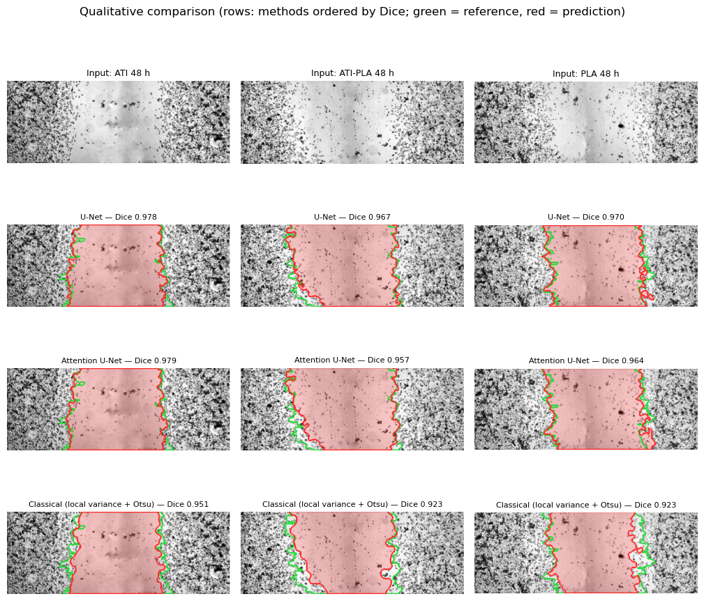

**Figure caption (English):** Representative out-of-fold segmentations for one image per treatment. Top row, input images; rows below, segmentation methods ordered by mean Dice. Green, reference wound region; red, predicted wound region.

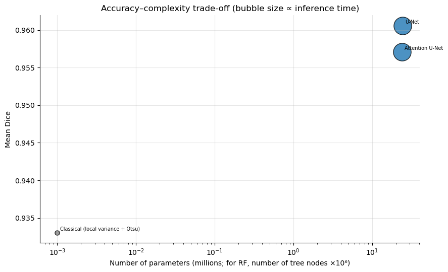

**Figure caption (English):** Accuracy–complexity trade-off: mean Dice against the number of parameters (logarithmic scale); bubble size is proportional to the inference time per image.

```python
# Nitel karşılaştırma: her ilaçtan bir görüntü × tüm modeller
sel = []
for dname in CFG["DRUGS"]:
    sub = META[META["drug"].astype(str) == dname].sort_values("time_h")
    if len(sub):
        sel.append(int(sub.iloc[len(sub) // 2]["idx"]))
show_models = [n for n in sorted(names, key=lambda n: -RESULTS[n]["Dice"].mean())]
nrow = len(show_models) + 1
fig, axes = plt.subplots(nrow, len(sel), figsize=(3.4 * len(sel), 2.3 * nrow))
axes = np.atleast_2d(axes)
if axes.shape[1] != len(sel):
    axes = axes.reshape(nrow, len(sel))
for c, i in enumerate(sel):
    axes[0, c].imshow(IMGS[i], cmap="gray"); axes[0, c].set_title(f"Input: {DL(META.loc[i,'drug'])} {int(META.loc[i,'time_h'])} h", fontsize=9)
    for r, n in enumerate(show_models, 1):
        axes[r, c].imshow(overlay_rgb(IMGS[i], MASKS[i], binarize(OOF[n][i], FOLD_HP.get(n, {}).get(fold_of(i), BEST_HP.get(n, {})))))
        dsc = RESULTS[n].set_index("idx").loc[i, "Dice"]
        axes[r, c].set_title(f"{label(n)} — Dice {dsc:.3f}", fontsize=8)
for a in axes.ravel():
    a.set_axis_off()
plt.suptitle("Qualitative comparison (rows: methods ordered by Dice; green = reference, red = prediction)", y=1.0)
plt.tight_layout(); savefig("15_qualitative_grid"); plt.show()

# Verimlilik: Dice vs parametre sayısı
plt.figure(figsize=(9, 5.5))
for n in names:
    p = max(INFO.get(n, {}).get("params_M", np.nan), 1e-3)
    plt.scatter(p, RESULTS[n]["Dice"].mean(), s=40 + 300 * min(INFO.get(n, {}).get("infer_s", 0.1), 2),
                color=FAMILY_COLORS.get(fam(n), "gray"), alpha=0.8, edgecolor="k")
    plt.annotate(label(n), (p, RESULTS[n]["Dice"].mean()), fontsize=7, xytext=(4, 3), textcoords="offset points")
plt.xscale("log"); plt.xlabel("Number of parameters (millions; for RF, number of tree nodes ×10⁶)"); plt.ylabel("Mean Dice")
plt.title("Accuracy–complexity trade-off (bubble size ∝ inference time)"); plt.grid(alpha=0.3)
plt.tight_layout(); savefig("16_efficiency"); plt.show()
```

### 11.4 İstatistiksel testler

- **Friedman testi:** Tüm modellerin aynı 12 görüntüdeki Dice değerleri eşleştirilmiş kabul edilerek "hepsi eşit" hipotezi test edilir.
- **Ortalama sıra:** Her görüntüde modeller sıralanır, sıraların ortalaması alınır (Demšar, 2006).
- **Wilcoxon işaretli sıra testi + Holm düzeltmesi:** En iyi model diğer her modelle ikili karşılaştırılır; çoklu karşılaştırma için Holm düzeltmesi uygulanır. Etki büyüklüğü r = |Z|/√n.

```python
# İstatistiksel testler
rk = [n for n in names if n in RANKABLE]
mat = np.array([RESULTS[n].sort_values("idx")["Dice"].values for n in rk]).T      # (12, M)
STATS = {}
if mat.shape[1] >= 3:
    fr = stats.friedmanchisquare(*[mat[:, j] for j in range(mat.shape[1])])
    STATS["friedman"] = dict(chi2=fr.statistic, p=fr.pvalue)
    print(f"Friedman testi: χ²={fr.statistic:.3f}, p={fr.pvalue:.4g}  (H0: tüm modellerin Dice dağılımları aynı)")
ranks = pd.DataFrame(mat, columns=[label(n) for n in rk]).rank(axis=1, ascending=False).mean().sort_values()
display(Markdown("**Ortalama sıra (Dice; 1 = en iyi)**")); display(ranks.round(2).to_frame("ort_sıra").T)
wl = []
b = RESULTS[BEST].sort_values("idx")["Dice"].values
for n in rk:
    if n == BEST:
        continue
    o = RESULTS[n].sort_values("idx")["Dice"].values
    try:
        w = stats.wilcoxon(b, o, zero_method="zsplit")
        p = w.pvalue
    except ValueError:
        p = 1.0
    diff = b - o
    wl.append(dict(Model=label(n), ΔDice_ort=diff.mean(), ΔDice_medyan=np.median(diff), p=p,
                   etki_r=abs(stats.norm.ppf(p / 2)) / math.sqrt(len(b)) if p < 1 else 0.0))
WIL = pd.DataFrame(wl)
if len(WIL):
    WIL["p_Holm"] = multipletests(WIL["p"], method="holm")[1]
    WIL["anlamlı (α=0.05)"] = WIL["p_Holm"] < 0.05
    display(Markdown(f"**Wilcoxon işaretli sıra testi: {BEST} vs diğerleri (Holm düzeltmeli)**"))
    display(WIL.sort_values("ΔDice_ort").round(4))
    WIL.to_csv(DIRS["tables"] / "wilcoxon_vs_best.csv", index=False)
```

```
Friedman testi: χ²=14.000, p=0.0009119  (H0: tüm modellerin Dice dağılımları aynı)
```

**Ortalama sıra (Dice; 1 = en iyi)**

|  | U-Net | Attention U-Net | Classical (local variance + Otsu) |
| --- | --- | --- | --- |
| ort_sıra | 1.33 | 1.83 | 2.83 |

**Wilcoxon işaretli sıra testi: Attention U-Net vs diğerleri (Holm düzeltmeli)**

|  | Model | ΔDice_ort | ΔDice_medyan | p | etki_r | p_Holm | anlamlı (α=0.05) |
| --- | --- | --- | --- | --- | --- | --- | --- |
| 1 | U-Net | -0.0035 | -0.0020 | 0.0210 | 0.6663 | 0.0210 | True |
| 0 | Classical (local variance + Otsu) | 0.0240 | 0.0124 | 0.0015 | 0.9184 | 0.0029 | True |

## 12. Regresyon analizi ve yara kapanma kinetiği

### 12.1 Doğrusal regresyon (ilaç × zaman, PLA referans)

Sizin tarif ettiğiniz regresyon kurgusu: **bağımlı değişken** = yara alanı, **bağımsız değişkenler** = zaman (sürekli, saat) ve ilaç (kategorik; **PLA = referans/kontrol**, tedavi kodlaması).

- **Model 1 (mutlak alan):** `Alan ~ zaman × C(ilaç, ref=PLA)` → 6 parametre, 12 gözlem, 6 serbestlik derecesi.
- **Model 2 (göreli alan, ortak başlangıç):** `RA − 1 ~ 0 + zaman + zaman:C(ilaç, ref=PLA)`, burada **RA(t) = A(t)/A(0)**. Tüm ilaçlar t=0'da RA=1'den başladığı için kesişim yoktur; `zaman:ilaç[T.ati]` katsayısı, ati'nin kapanma hızının PLA'dan **ne kadar farklı** olduğunu doğrudan verir (negatif = daha hızlı kapanma).

Analiz hem **referans maskelerle** (GT) hem de **en iyi modelin tahmin ettiği alanlarla** yapılır; iki sonucun tutarlılığı, otomatik nicelleştirmenin biyolojik sonuca etkisini gösterir.

|  | idx | file | drug | time_h | A_GT | A_best | RA_GT | Closure_GT_% | RA_best | Closure_best_% |
| --- | --- | --- | --- | --- | --- | --- | --- | --- | --- | --- |
| 0 | 0 | 0_ati.jpeg | ati | 0.0 | 446488.1300 | 450842.9156 | 1.0000 | 0.0000 | 1.0000 | 0.0000 |
| 1 | 1 | 24_ati.jpeg | ati | 24.0 | 331543.7640 | 327984.7895 | 0.7426 | 25.7441 | 0.7275 | 27.2508 |
| 2 | 2 | 48_ati.jpeg | ati | 48.0 | 281749.3927 | 276515.8320 | 0.6310 | 36.8966 | 0.6133 | 38.6669 |
| 3 | 3 | 72_atı.jpeg | ati | 72.0 | 207254.0161 | 224922.6476 | 0.4642 | 53.5813 | 0.4989 | 50.1106 |
| 4 | 4 | 0_ap.jpeg | ap | 0.0 | 475715.2150 | 469162.6811 | 1.0000 | 0.0000 | 1.0000 | 0.0000 |
| 5 | 5 | 24_ap.jpeg | ap | 24.0 | 351380.4137 | 353500.7207 | 0.7386 | 26.1364 | 0.7535 | 24.6528 |
| 6 | 6 | 48_ap.jpeg | ap | 48.0 | 312429.8955 | 292687.0110 | 0.6568 | 34.3242 | 0.6238 | 37.6150 |
| 7 | 7 | 72_ap.jpeg | ap | 72.0 | 220353.1200 | 181730.9231 | 0.4632 | 53.6796 | 0.3874 | 61.2648 |
| 8 | 8 | 0_control.jpeg | PLA | 0.0 | 458967.0213 | 455432.3320 | 1.0000 | 0.0000 | 1.0000 | 0.0000 |
| 9 | 9 | 24_control.jpeg | PLA | 24.0 | 333842.6492 | 361762.0974 | 0.7274 | 27.2622 | 0.7943 | 20.5673 |
| 10 | 10 | 48_control.jpeg | PLA | 48.0 | 282362.2083 | 285919.4583 | 0.6152 | 38.4788 | 0.6278 | 37.2202 |
| 11 | 11 | 72_control.jpeg | PLA | 72.0 | 217678.4381 | 167392.2604 | 0.4743 | 52.5721 | 0.3675 | 63.2454 |

**Model 1 (normalize mutlak alan) — kaynak: referans maskeler** R²=0.966, düz. R²=0.937, n=12

|  | katsayı | SH | t | p | %95 GA alt | %95 GA üst |
| --- | --- | --- | --- | --- | --- | --- |
| Intercept | 0.92390 | 0.04139 | 22.32382 | 0.00000 | 0.82263 | 1.02517 |
| C(drug, Treatment(reference='PLA'))[T.ap] | 0.04459 | 0.05853 | 0.76179 | 0.47505 | -0.09863 | 0.18780 |
| C(drug, Treatment(reference='PLA'))[T.ati] | -0.01604 | 0.05853 | -0.27408 | 0.79322 | -0.15926 | 0.12717 |
| time_h | -0.00679 | 0.00092 | -7.36758 | 0.00032 | -0.00905 | -0.00454 |
| time_h:C(drug, Treatment(reference='PLA'))[T.ap] | -0.00026 | 0.00130 | -0.19950 | 0.84846 | -0.00345 | 0.00293 |
| time_h:C(drug, Treatment(reference='PLA'))[T.ati] | 0.00007 | 0.00130 | 0.05274 | 0.95965 | -0.00312 | 0.00326 |

**Model 2 (göreli alan, ortak başlangıç) — kaynak: referans maskeler** R²=0.986, düz. R²=0.981, n=12

|  | katsayı | SH | t | p | %95 GA alt | %95 GA üst |
| --- | --- | --- | --- | --- | --- | --- |
| time_h | -0.00780 | 0.00054 | -14.45677 | 0.00000 | -0.00902 | -0.00658 |
| time_h:C(drug, Treatment(reference='PLA'))[T.ap] | 0.00018 | 0.00076 | 0.23855 | 0.81680 | -0.00154 | 0.00191 |
| time_h:C(drug, Treatment(reference='PLA'))[T.ati] | 0.00005 | 0.00076 | 0.06458 | 0.94992 | -0.00168 | 0.00177 |

**Model 1 (normalize mutlak alan) — kaynak: en iyi model (Attention U-Net)** R²=0.979, düz. R²=0.962, n=12

|  | katsayı | SH | t | p | %95 GA alt | %95 GA üst |
| --- | --- | --- | --- | --- | --- | --- |
| Intercept | 0.97753 | 0.03581 | 27.29648 | 0.00000 | 0.88990 | 1.06516 |
| C(drug, Treatment(reference='PLA'))[T.ap] | 0.00877 | 0.05065 | 0.17321 | 0.86818 | -0.11515 | 0.13270 |
| C(drug, Treatment(reference='PLA'))[T.ati] | -0.06217 | 0.05065 | -1.22765 | 0.26555 | -0.18610 | 0.06175 |
| time_h | -0.00835 | 0.00080 | -10.46640 | 0.00004 | -0.01030 | -0.00640 |
| time_h:C(drug, Treatment(reference='PLA'))[T.ap] | 0.00015 | 0.00113 | 0.13270 | 0.89877 | -0.00261 | 0.00291 |
| time_h:C(drug, Treatment(reference='PLA'))[T.ati] | 0.00187 | 0.00113 | 1.65922 | 0.14814 | -0.00089 | 0.00463 |

**Model 2 (göreli alan, ortak başlangıç) — kaynak: en iyi model (Attention U-Net)** R²=0.991, düz. R²=0.988, n=12

|  | katsayı | SH | t | p | %95 GA alt | %95 GA üst |
| --- | --- | --- | --- | --- | --- | --- |
| time_h | -0.00847 | 0.00046 | -18.50846 | 0.00000 | -0.00951 | -0.00744 |
| time_h:C(drug, Treatment(reference='PLA'))[T.ap] | 0.00003 | 0.00065 | 0.04902 | 0.96197 | -0.00143 | 0.00150 |
| time_h:C(drug, Treatment(reference='PLA'))[T.ati] | 0.00089 | 0.00065 | 1.37094 | 0.20361 | -0.00058 | 0.00235 |

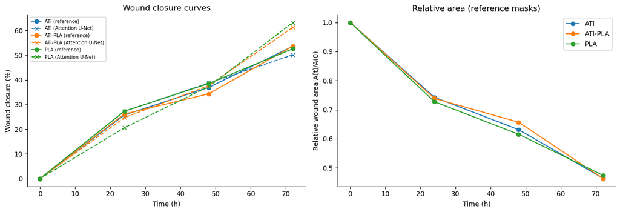

**Figure caption (English):** Wound closure over time. Left, closure relative to the initial wound area from the reference masks (solid lines) and from Attention U-Net (dashed lines). Right, relative wound area A(t)/A(0) from the reference masks.

```python
def relative_area(df, col):
    a0 = df[df["time_h"] == 0].set_index("drug")[col]
    return df.apply(lambda r: r[col] / a0.get(r["drug"], np.nan), axis=1)

AREA = META[["idx", "file", "drug", "time_h"]].copy()
AREA["drug"] = AREA["drug"].astype(str)
AREA["A_GT"] = META["area_gt_px"].values
AREA["A_best"] = RESULTS[BEST].sort_values("idx")["Area_Pred"].values
for src in ["GT", "best"]:
    AREA[f"RA_{src}"] = relative_area(AREA, f"A_{src}")
    AREA[f"Closure_{src}_%"] = 100 * (1 - AREA[f"RA_{src}"])
display(AREA.round(4))
AREA.to_csv(DIRS["tables"] / "areas_closure.csv", index=False)

REG = {}
for src in ["GT", "best"]:
    d = AREA.rename(columns={f"A_{src}": "A", f"RA_{src}": "RA"})
    d["A_norm"] = d["A"] / d["A"].max()
    try:
        m1 = smf.ols(f"A_norm ~ time_h * C(drug, Treatment(reference='{CFG['CONTROL']}'))", data=d).fit()
        m2 = smf.ols(f"I(RA - 1) ~ 0 + time_h + time_h:C(drug, Treatment(reference='{CFG['CONTROL']}'))", data=d).fit()
        REG[src] = (m1, m2)
        for nm, m in [("Model 1 (normalize mutlak alan)", m1), ("Model 2 (göreli alan, ortak başlangıç)", m2)]:
            tab = pd.DataFrame({"katsayı": m.params, "SH": m.bse, "t": m.tvalues, "p": m.pvalues,
                                "%95 GA alt": m.conf_int()[0], "%95 GA üst": m.conf_int()[1]})
            display(Markdown(f"**{nm} — kaynak: {'referans maskeler' if src == 'GT' else 'en iyi model ('+BEST+')'}**  "
                             f"R²={m.rsquared:.3f}, düz. R²={m.rsquared_adj:.3f}, n={int(m.nobs)}"))
            display(tab.round(5))
            tab.to_csv(DIRS["tables"] / f"regression_{src}_{nm.split()[1]}.csv")
    except Exception as ex:
        print("Regresyon kurulamadı:", ex)

fig, ax = plt.subplots(1, 2, figsize=(13, 4.5))
for dname in CFG["DRUGS"]:
    s = AREA[AREA["drug"] == dname].sort_values("time_h")
    c_ = plt.cm.tab10(CFG["DRUGS"].index(dname))
    ax[0].plot(s["time_h"], s["Closure_GT_%"], "o-", color=c_, label=f"{DL(dname)} (reference)")
    ax[0].plot(s["time_h"], s["Closure_best_%"], "x--", color=c_, label=f"{DL(dname)} ({ML(BEST)})")
    ax[1].plot(s["time_h"], s["RA_GT"], "o-", color=c_, label=DL(dname))
ax[0].set_xlabel("Time (h)"); ax[0].set_ylabel("Wound closure (%)"); ax[0].legend(fontsize=7); ax[0].set_title("Wound closure curves")
ax[1].set_xlabel("Time (h)"); ax[1].set_ylabel("Relative wound area A(t)/A(0)"); ax[1].legend(); ax[1].set_title("Relative area (reference masks)")
plt.tight_layout(); savefig("20_closure_curves"); plt.show()
```

### 12.2 Kinetik modeller (zaman tahmininin temeli)

Göreli alan RA(t) için RA(0)=1 kısıtlı dört model, her ilaç için ayrı uydurulur:

| Model | Denklem | Parametre | Biyolojik yorum |
| --- | --- | --- | --- |
| Lineer | RA = max(0, 1 − k·t) | k | Sabit hızlı cephe göçü |
| Üstel | RA = e^(−k·t) | k | Kalan alanla orantılı kapanma |
| Weibull | RA = exp(−(t/τ)^β) | τ, β | Gecikmeli/hızlanan kapanma (esnek) |
| Lojistik | RA = (1+e^(−r·t₅₀))/(1+e^(r(t−t₅₀))) | r, t₅₀ | Sigmoid; Jin vd. (2017) scratch assay'de lojistik proliferasyon |
| **Gompertz** | RA = 1 − [G(t) − G(0)]/[1 − G(0)], G(t) = exp(−e^(−k(t−t₀))) | k, t₀ | Rosoff vd. (2022)'nin kaplama eğrisi için kullandığı model; k ve t₀ **Y ekseni ölçeğinden bağımsızdır**, bu yüzden yöntemler arası karşılaştırmada sağlamdır |

**Model seçimi:** Bırak-bir-zaman-dışarıda (LOTO) tahmin hatası (RMSE) — yani her model, gözlenmeyen bir zamanı ne kadar iyi tahmin ediyor? 4 zaman noktasıyla AIC/AICc güvenilmez olduğundan, doğrudan **tahmin başarısı** kriter olarak kullanılır (eşitlikte daha az parametreli model).

**Belirsizlik:** Parametrik bootstrap (`MC_DRAWS` tekrar). Gürültü düzeyi σ = max(uyum RMSE'si, en iyi 3 segmentasyon modelinin alan tahminleri arasındaki dağılım, 0.02) → hem biyolojik hem ölçüm (segmentasyon) belirsizliği yansıtılır.

|  | ilaç | model | parametreler | RMSE_uyum | RMSE_LOTO | AIC | seçildi |
| --- | --- | --- | --- | --- | --- | --- | --- |
| 0 | ati | Lineer | [0.00775] | 0.03743 | 0.05692 | -24.28142 | False |
| 1 | ati | Üstel | [0.01052] | 0.02211 | 0.03456 | -28.49308 | True |
| 2 | ati | Weibull | [102.29956, 0.88907] | 0.01939 | 0.07511 | -27.54473 | False |
| 3 | ati | Lojistik | [0.01703, 0.0] | 0.02988 | 0.04726 | -24.08418 | False |
| 4 | ati | Gompertz | [0.0118, -100.0] | 0.02329 | 0.04999 | -26.07640 | False |
| 5 | ap | Lineer | [0.00761] | 0.04125 | 0.05525 | -23.50453 | False |
| 6 | ap | Üstel | [0.01025] | 0.03222 | 0.05334 | -25.48203 | True |
| 7 | ap | Weibull | [105.00889, 0.89264] | 0.03063 | 0.11536 | -23.88581 | False |
| 8 | ap | Lojistik | [0.01665, 0.0] | 0.03688 | 0.06997 | -22.39990 | False |
| 9 | ap | Gompertz | [0.01154, -100.0] | 0.03286 | 0.07887 | -23.32517 | False |
| 10 | PLA | Lineer | [0.0078] | 0.04662 | 0.07879 | -22.52662 | False |
| 11 | PLA | Üstel | [0.0107] | 0.02522 | 0.03720 | -27.43941 | True |
| 12 | PLA | Weibull | [109.2098, 0.78873] | 0.01405 | 0.05572 | -30.12070 | False |
| 13 | PLA | Lojistik | [0.01724, 0.0] | 0.03684 | 0.05538 | -22.41027 | False |
| 14 | PLA | Gompertz | [0.01197, -100.0] | 0.02741 | 0.04210 | -24.77619 | False |

```
{'ati': ('Üstel', [0.01052], 0.0365), 'ap': ('Üstel', [0.01025], 0.0403), 'PLA': ('Üstel', [0.0107], 0.0596)}
```

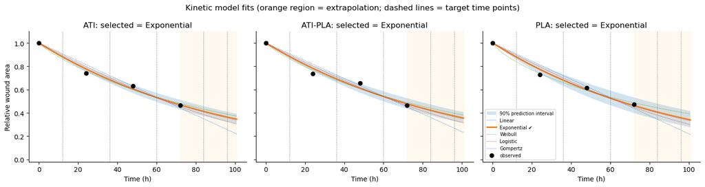

**Figure caption (English):** Kinetic models fitted to the relative wound area of each treatment (points, observations from the reference masks). The selected model, chosen by leave-one-time-point-out prediction error, is drawn as a thick line and the alternatives as dotted lines; the shaded band is the 90% parametric-bootstrap prediction interval. The orange region marks extrapolation beyond the last observation, and dashed vertical lines mark the target time points (12, 36, 60, 84, 96 h).

```python
KIN = OrderedDict(
    Lineer=(lambda t, k: np.maximum(0.0, 1 - k * t), [0.005], ([0.0], [1.0])),
    Üstel=(lambda t, k: np.exp(-k * t), [0.01], ([0.0], [1.0])),
    Weibull=(lambda t, tau, b: np.exp(-(np.maximum(t, 0) / tau) ** b), [60.0, 1.0], ([1.0, 0.2], [1e4, 6.0])),
    Lojistik=(lambda t, r, t50: (1 + np.exp(-r * t50)) / (1 + np.exp(np.clip(r * (t - t50), -50, 50))), [0.05, 50.0], ([1e-4, 0.0], [2.0, 2e3])),
    Gompertz=(lambda t, k, t0: 1 - (np.exp(-np.exp(np.clip(-k * (t - t0), -50, 50))) - np.exp(-np.exp(np.clip(k * t0, -50, 50))))
              / np.maximum(1 - np.exp(-np.exp(np.clip(k * t0, -50, 50))), 1e-9), [0.03, 30.0], ([1e-4, -100.0], [1.0, 2e3])),
)

def fit_kin(name, t, y):
    f, p0, bnds = KIN[name]
    t, y = np.asarray(t, float), np.asarray(y, float)
    best = None
    for s in [1.0, 0.3, 3.0]:                                 # çoklu başlangıç
        try:
            p, _ = optimize.curve_fit(f, t, y, p0=[v * s for v in p0], bounds=bnds, maxfev=20000)
            r = np.sqrt(np.mean((f(t, *p) - y) ** 2))
            if best is None or r < best[1]:
                best = (p, r)
        except Exception:
            pass
    return best if best else (np.array(p0), np.inf)

def kin_predict(name, p, t):
    return np.clip(KIN[name][0](np.asarray(t, float), *p), 0, 1.5)

def loto_rmse(name, t, y):
    t, y = np.asarray(t, float), np.asarray(y, float)
    errs = []
    for j in range(len(t)):
        if t[j] == 0:
            continue
        keep = np.arange(len(t)) != j
        p, _ = fit_kin(name, t[keep], y[keep])
        errs.append((kin_predict(name, p, t[j]) - y[j]) ** 2)
    return float(np.sqrt(np.mean(errs))) if errs else np.inf

# segmentasyon kaynaklı ölçüm belirsizliği: en iyi 3 modelin RA tahminleri arasındaki SS
top3 = sorted(RANKABLE, key=lambda n: -RESULTS[n]["Dice"].mean())[:3]
ra_models = []
for n in top3:
    tmp = AREA[["drug", "time_h"]].copy(); tmp["A"] = RESULTS[n].sort_values("idx")["Area_Pred"].values
    ra_models.append(relative_area(tmp, "A").values)
SIGMA_SEG = pd.Series(np.nanstd(np.array(ra_models), 0) if len(ra_models) > 1 else np.zeros(len(AREA)), index=AREA.index)

KFIT, KROWS = {}, []
for dname in CFG["DRUGS"]:
    s = AREA[AREA["drug"] == dname].sort_values("time_h")
    t, y = s["time_h"].values, s["RA_GT"].values
    res = {}
    for name in KIN:
        p, r = fit_kin(name, t, y)
        lr = loto_rmse(name, t, y)
        n_par = len(KIN[name][1]); n_obs = len(t)
        aic = n_obs * np.log(max(r, 1e-6) ** 2) + 2 * n_par
        res[name] = dict(p=p, rmse=r, loto=lr, aic=aic, k=n_par)
        KROWS.append(dict(ilaç=dname, model=name, parametreler=np.round(p, 5).tolist(), RMSE_uyum=r, RMSE_LOTO=lr, AIC=aic))
    chosen = min(res, key=lambda m: (round(res[m]["loto"], 4), res[m]["k"]))
    sig = max(res[chosen]["rmse"], float(SIGMA_SEG[s.index[s["time_h"] > 0]].mean()) if (s["time_h"] > 0).any() else 0, 0.02)
    KFIT[dname] = dict(model=chosen, p=res[chosen]["p"], sigma=sig, all=res, t=t, y=y)
KIN_TABLE = pd.DataFrame(KROWS)
KIN_TABLE["seçildi"] = KIN_TABLE.apply(lambda r: KFIT[r["ilaç"]]["model"] == r["model"], axis=1)
display(KIN_TABLE.round(5)); KIN_TABLE.to_csv(DIRS["tables"] / "kinetic_models.csv", index=False)
print({d: (v["model"], np.round(v["p"], 5).tolist(), round(v["sigma"], 4)) for d, v in KFIT.items()})

def bootstrap_kin(dname, t_new, n=None, model=None, seed=0):
    """Parametrik bootstrap: RA tahmin dağılımı (satır = örnek)."""
    n = n or CFG["MC_DRAWS"]
    kf = KFIT[dname]; model = model or kf["model"]
    rng = np.random.default_rng(seed)
    t, y = kf["t"], kf["y"]
    p_hat, _ = fit_kin(model, t, y)
    yhat = kin_predict(model, p_hat, t)
    out, pars = [], []
    for _ in range(n):
        yb = yhat + rng.normal(0, kf["sigma"], len(t)); yb[t == 0] = 1.0
        p, _ = fit_kin(model, t, np.clip(yb, 0, 1.5))
        out.append(kin_predict(model, p, t_new)); pars.append(p)
    return np.array(out), np.array(pars)

t_grid = np.linspace(0, max(CFG["TIME_TARGETS"] + CFG["TIMES_OBS"]) * 1.05, 120)
KIN_PRED = {}
fig, ax = plt.subplots(1, len(CFG["DRUGS"]), figsize=(5 * len(CFG["DRUGS"]), 4), sharey=True)
for a, dname in zip(np.atleast_1d(ax), CFG["DRUGS"]):
    kf = KFIT[dname]
    B, _ = bootstrap_kin(dname, t_grid, n=min(CFG["MC_DRAWS"], 400))
    lo, md, hi = np.percentile(B, [5, 50, 95], 0)
    a.fill_between(t_grid, lo, hi, alpha=0.2, label="90% prediction interval")
    for name in KIN:
        a.plot(t_grid, kin_predict(name, kf["all"][name]["p"], t_grid), lw=2.2 if name == kf["model"] else 0.8,
               ls="-" if name == kf["model"] else ":", label=f"{KL(name)}{' ✔' if name == kf['model'] else ''}")
    a.scatter(kf["t"], kf["y"], c="k", zorder=5, label="observed")
    for tt in CFG["TIME_TARGETS"]:
        a.axvline(tt, color="gray", lw=0.5, ls="--")
    a.axvspan(max(CFG["TIMES_OBS"]), t_grid.max(), color="orange", alpha=0.06)
    a.set_title(f"{DL(dname)}: selected = {KL(kf['model'])}"); a.set_xlabel("Time (h)"); a.set_ylim(-0.02, 1.1)
np.atleast_1d(ax)[0].set_ylabel("Relative wound area"); np.atleast_1d(ax)[-1].legend(fontsize=7)
plt.suptitle("Kinetic model fits (orange region = extrapolation; dashed lines = target time points)")
plt.tight_layout(); savefig("21_kinetic_fits"); plt.show()
```

### 12.3 Sınır kapanması ve birleşme analizi (iki sınırın birbirine yaklaşması)

Biyolojik soru: **iki hücre cephesi (mavi çizgiyle çizilen sınırlar) ne hızla birbirine yaklaşıyor ve nerede birleşiyor?** Alan tek bir sayı verir; genişlik profili ise kapanmanın **uzamsal** dağılımını gösterir.

- **Genişlik profili:** Kanonik yönelimde her satırda w(y) = x<sub>sağ</sub>(y) − x<sub>sol</sub>(y).
- **Çoklu ölçüm (Plotczyk vd. 2023):** Yara boyunca eşit aralıklı `N_WIDTH_LINES` (varsayılan 20) konumda genişlik ölçülür (kenarlardan %5 pay bırakılır). Böylece her görüntüden n = 20 ölçüm elde edilir.
- **Birleşme (temas):** w ≤ eşik olan konumlar "birleşmiş" sayılır; görüntü başına birleşmiş konum yüzdesi raporlanır.
- **Sınır kıvrımlılığı (yay/kiriş oranı):** Plotczyk vd.'nin epidermis–dermis sınırı için kullandığı ölçüt; 1 = düz cephe, büyük değer = parmaksı/düzensiz göç cephesi.
- **İstatistik:** genişlik ~ ilaç × zaman **iki yönlü ANOVA** (PLA referans), artıkların normalliği (D'Agostino–Pearson) ve varyans homojenliği (Levene), her zaman noktasında ilaçlar arası **Tukey HSD**; parametrik olmayan alternatif olarak **Kruskal–Wallis** + Holm düzeltmeli Mann–Whitney.

> ⚠️ **N ve n ayrımı:** Bir görüntüdeki 20 konum aynı kuyucuktan gelir (teknik tekrar, n); biyolojik tekrar sayısı N = 1'dir. Plotczyk vd. de "N = hasta, n = kesit" ayrımını açıkça raporlamıştır. ANOVA p-değerleri bu nedenle **konum düzeyinde** yorumlanmalı ve makalede N = 1 sınırlılığı belirtilmelidir.

**Görüntü başına sınır/genişlik özeti (birim: µm)**

|  | kaynak | idx | drug | time_h | genişlik_ort | genişlik_ss | genişlik_min | birleşmiş_pct | temas_var | kıvrımlılık_sol | kıvrımlılık_sağ | genişlik_kapanma_pct |
| --- | --- | --- | --- | --- | --- | --- | --- | --- | --- | --- | --- | --- |
| 0 | Referans | 0 | ati | 0.0 | 2600.045 | 62.580 | 2488.701 | 0.0 | False | 1.189 | 1.198 | 0.000 |
| 1 | Referans | 1 | ati | 24.0 | 1925.768 | 80.214 | 1794.057 | 0.0 | False | 1.221 | 1.206 | 25.933 |
| 2 | Referans | 2 | ati | 48.0 | 1641.237 | 130.525 | 1357.420 | 0.0 | False | 1.671 | 1.429 | 36.877 |
| 3 | Referans | 3 | ati | 72.0 | 1201.903 | 101.670 | 1055.044 | 0.0 | False | 1.256 | 1.437 | 53.774 |
| 4 | Referans | 4 | ap | 0.0 | 2763.900 | 85.492 | 2606.764 | 0.0 | False | 1.461 | 1.338 | 0.000 |
| 5 | Referans | 5 | ap | 24.0 | 2040.457 | 81.701 | 1795.711 | 0.0 | False | 1.448 | 1.261 | 26.175 |
| 6 | Referans | 6 | ap | 48.0 | 1811.148 | 104.834 | 1506.648 | 0.0 | False | 1.766 | 1.454 | 34.471 |
| 7 | Referans | 7 | ap | 72.0 | 1278.371 | 178.270 | 917.643 | 0.0 | False | 1.577 | 1.327 | 53.748 |
| 8 | Referans | 8 | PLA | 0.0 | 2658.436 | 42.564 | 2564.768 | 0.0 | False | 1.324 | 1.188 | 0.000 |
| 9 | Referans | 9 | PLA | 24.0 | 1948.114 | 45.754 | 1827.162 | 0.0 | False | 1.451 | 1.213 | 26.720 |
| 10 | Referans | 10 | PLA | 48.0 | 1658.402 | 76.594 | 1476.696 | 0.0 | False | 1.742 | 1.482 | 37.617 |
| 11 | Referans | 11 | PLA | 72.0 | 1261.136 | 335.940 | 793.032 | 0.0 | False | 1.486 | 1.525 | 52.561 |
| 12 | Attention U-Net | 0 | ati | 0.0 | 2626.546 | 59.955 | 2516.456 | 0.0 | False | 1.125 | 1.197 | 0.000 |
| 13 | Attention U-Net | 1 | ati | 24.0 | 1905.864 | 79.626 | 1782.400 | 0.0 | False | 1.082 | 1.157 | 27.438 |
| 14 | Attention U-Net | 2 | ati | 48.0 | 1609.361 | 86.779 | 1365.858 | 0.0 | False | 1.217 | 1.301 | 38.727 |
| 15 | Attention U-Net | 3 | ati | 72.0 | 1303.595 | 76.070 | 1180.147 | 0.0 | False | 1.218 | 1.120 | 50.368 |
| 16 | Attention U-Net | 4 | ap | 0.0 | 2701.486 | 79.481 | 2603.855 | 0.0 | False | 1.471 | 1.207 | 0.000 |
| 17 | Attention U-Net | 5 | ap | 24.0 | 2054.356 | 93.590 | 1896.061 | 0.0 | False | 1.117 | 1.193 | 23.955 |
| 18 | Attention U-Net | 6 | ap | 48.0 | 1693.124 | 204.571 | 1190.892 | 0.0 | False | 1.430 | 1.292 | 37.326 |
| 19 | Attention U-Net | 7 | ap | 72.0 | 1047.064 | 231.149 | 716.334 | 0.0 | False | 1.327 | 1.181 | 61.241 |
| 20 | Attention U-Net | 8 | PLA | 0.0 | 2639.554 | 33.788 | 2570.879 | 0.0 | False | 1.123 | 1.063 | 0.000 |
| 21 | Attention U-Net | 9 | PLA | 24.0 | 2078.326 | 119.755 | 1960.816 | 0.0 | False | 1.139 | 1.329 | 21.262 |
| 22 | Attention U-Net | 10 | PLA | 48.0 | 1670.993 | 64.557 | 1507.552 | 0.0 | False | 1.305 | 1.494 | 36.694 |
| 23 | Attention U-Net | 11 | PLA | 72.0 | 971.262 | 56.363 | 850.637 | 0.0 | False | 1.143 | 1.125 | 63.204 |

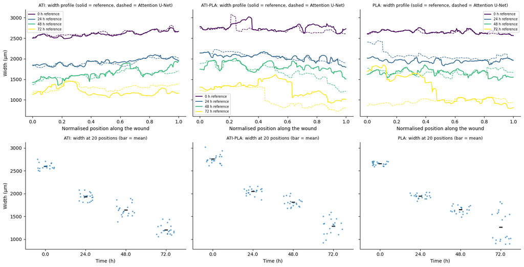

**Figure caption (English):** Wound width along the wound for each treatment. Top, width profiles at the observed time points (solid lines, reference borders; dashed lines, Attention U-Net). Bottom, width measured at 20 equally spaced positions per image from the reference borders (points), with the mean (horizontal bar).

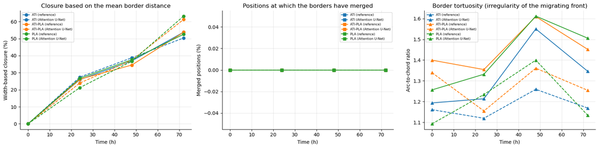

**Figure caption (English):** Border geometry over time for the reference (solid lines) and Attention U-Net (dashed lines). Left, width-based closure relative to 0 h; middle, percentage of border positions at which the two fronts are in contact (merged); right, arc-to-chord ratio of the fronts (1 = straight front).

```python
from statsmodels.stats.anova import anova_lm
from statsmodels.stats.multicomp import pairwise_tukeyhsd

def width_track(i, mask=None):
    """Referans (mask=None → mavi çizgi sınırları) veya bir tahmin maskesi için genişlik profili (çalışma pikseli)."""
    if mask is None:
        xL, xR = GT_BORDERS[i]["xL"], GT_BORDERS[i]["xR"]
    else:
        xL, xR = mask_borders(mask, ORIENT[i])
        if np.isnan(xL).all():
            return np.zeros(len(xL)), xL, xR
        xL, xR, _ = fill_tracks(xL, xR)
    return np.maximum(xR - xL, 0), xL, xR

def tortuosity(x):
    x = ndi.gaussian_filter1d(np.asarray(x, float), 2)
    arc = np.sum(np.sqrt(1 + np.diff(x) ** 2)); chord = math.hypot(len(x) - 1, x[-1] - x[0])
    return float(arc / chord) if chord > 0 else np.nan

K = int(CFG["N_WIDTH_LINES"])
WID, WSUM = [], []
for src_name, get_mask in [("Referans", lambda i: None), (BEST, lambda i: binarize(OOF[BEST][i], FOLD_HP.get(BEST, {}).get(fold_of(i), BEST_HP.get(BEST, {}))))]:
    for i in ALL_IDX:
        w, xL, xR = width_track(i, get_mask(i))
        H = len(w); ys = np.unique(np.linspace(0.05 * (H - 1), 0.95 * (H - 1), K).round().astype(int))
        wl = to_len(w[ys], i); thr = to_len(MERGE_THR_W[i], i)
        for k, (y, v) in enumerate(zip(ys, wl)):
            WID.append(dict(kaynak=src_name, idx=i, drug=str(META.loc[i, "drug"]), time_h=float(META.loc[i, "time_h"]), konum=k,
                            y=int(y), width=float(v), merged=bool(v <= thr)))
        WSUM.append(dict(kaynak=src_name, idx=i, drug=str(META.loc[i, "drug"]), time_h=float(META.loc[i, "time_h"]),
                         genişlik_ort=float(to_len(w.mean(), i)), genişlik_ss=float(to_len(w.std(), i)), genişlik_min=float(to_len(w.min(), i)),
                         birleşmiş_pct=float(100 * np.mean(w <= MERGE_THR_W[i])), temas_var=bool(np.any(w <= MERGE_THR_W[i])),
                         kıvrımlılık_sol=tortuosity(xL), kıvrımlılık_sağ=tortuosity(xR)))
WID, WSUM = pd.DataFrame(WID), pd.DataFrame(WSUM)
for src_name in WSUM["kaynak"].unique():
    sub = WSUM[WSUM["kaynak"] == src_name].copy()
    w0 = sub[sub["time_h"] == 0].set_index("drug")["genişlik_ort"]
    WSUM.loc[sub.index, "genişlik_kapanma_pct"] = [100 * (1 - r["genişlik_ort"] / w0.get(r["drug"], np.nan)) for _, r in sub.iterrows()]
display(Markdown(f"**Görüntü başına sınır/genişlik özeti (birim: {UNIT_LEN})**")); display(WSUM.round(3))
WSUM.to_csv(DIRS["tables"] / "width_summary.csv", index=False); WID.to_csv(DIRS["tables"] / "width_positions.csv", index=False)

# --- Şekil: genişlik profilleri (yara boyunca), Plotczyk tarzı nokta grafiği, kapanma ve birleşme yüzdeleri
fig, axes = plt.subplots(2, len(CFG["DRUGS"]), figsize=(5.2 * len(CFG["DRUGS"]), 8), sharey="row")
axes = np.atleast_2d(axes)
tcol = {t: plt.cm.viridis(j / max(len(CFG["TIMES_OBS"]) - 1, 1)) for j, t in enumerate(CFG["TIMES_OBS"])}
for c, dname in enumerate(CFG["DRUGS"]):
    for i in META[META["drug"].astype(str) == dname]["idx"]:
        t = int(META.loc[i, "time_h"]); w, _, _ = width_track(i)
        wb, _, _ = width_track(i, binarize(OOF[BEST][i], FOLD_HP.get(BEST, {}).get(fold_of(i), BEST_HP.get(BEST, {}))))
        pos = np.linspace(0, 1, len(w))
        axes[0, c].plot(pos, to_len(w, i), color=tcol.get(t, "k"), lw=1.6, label=f"{t} h reference")
        axes[0, c].plot(np.linspace(0, 1, len(wb)), to_len(wb, i), color=tcol.get(t, "k"), lw=1, ls="--")
    axes[0, c].set_title(f"{DL(dname)}: width profile (solid = reference, dashed = {ML(BEST)})", fontsize=9)
    axes[0, c].set_xlabel("Normalised position along the wound"); axes[0, c].legend(fontsize=7)
    sub = WID[(WID["kaynak"] == "Referans") & (WID["drug"] == dname)]
    sns.stripplot(data=sub, x="time_h", y="width", ax=axes[1, c], color=FAMILY_COLORS["CNN"], size=3, alpha=0.7, jitter=0.25)
    sns.pointplot(data=sub, x="time_h", y="width", ax=axes[1, c], color="k", errorbar=None, markers="_", linestyles="none")
    axes[1, c].set_title(f"{DL(dname)}: width at {K} positions (bar = mean)", fontsize=9); axes[1, c].set_xlabel("Time (h)")
axes[0, 0].set_ylabel(f"Width ({UNIT_LEN})"); axes[1, 0].set_ylabel(f"Width ({UNIT_LEN})")
plt.tight_layout(); savefig("22_width_profiles"); plt.show()

fig, ax = plt.subplots(1, 3, figsize=(17, 4.3))
DRUG_COL = {d: plt.cm.tab10(j) for j, d in enumerate(CFG["DRUGS"])}
for dname in CFG["DRUGS"]:
    for src_name, ls in [("Referans", "-"), (BEST, "--")]:
        s_ = WSUM[(WSUM["kaynak"] == src_name) & (WSUM["drug"] == dname)].sort_values("time_h")
        lb = f"{DL(dname)} ({'reference' if src_name == 'Referans' else ML(BEST)})"
        kw = dict(ls=ls, color=DRUG_COL[dname], label=lb)
        ax[0].plot(s_["time_h"], s_["genişlik_kapanma_pct"], marker="o", **kw)
        ax[1].plot(s_["time_h"], s_["birleşmiş_pct"], marker="s", **kw)
        ax[2].plot(s_["time_h"], (s_["kıvrımlılık_sol"] + s_["kıvrımlılık_sağ"]) / 2, marker="^", **kw)
ax[0].set_ylabel("Width-based closure (%)"); ax[1].set_ylabel("Merged positions (%)"); ax[2].set_ylabel("Arc-to-chord ratio")
ax[0].set_title("Closure based on the mean border distance"); ax[1].set_title("Positions at which the borders have merged")
ax[2].set_title("Border tortuosity (irregularity of the migrating front)")
for a in ax:
    a.set_xlabel("Time (h)"); a.legend(fontsize=6.5); a.grid(alpha=0.3)
plt.tight_layout(); savefig("23_width_closure_merge"); plt.show()
```

```python
# --- İki yönlü ANOVA + Tukey + parametrik olmayan testler (referans genişlikleri ve en iyi model genişlikleri)
WSTATS = {}
for src_name in ["Referans", BEST]:
    d = WID[WID["kaynak"] == src_name].copy()
    d["drug"] = pd.Categorical(d["drug"], categories=CFG["DRUGS"])
    display(Markdown(f"#### Genişlik istatistiği — kaynak: **{src_name}** (N = 1 görüntü/koşul, n = {K} konum/görüntü)"))
    try:
        m = smf.ols(f"width ~ C(drug, Treatment(reference='{CFG['CONTROL']}')) * C(time_h)", data=d).fit()
        an = anova_lm(m, typ=2)
        an["eta²_kısmi"] = an["sum_sq"] / (an["sum_sq"] + an.loc["Residual", "sum_sq"])
        display(an.round(5))
        k2, p_norm = stats.normaltest(m.resid) if len(m.resid) >= 20 else (np.nan, np.nan)
        lev = stats.levene(*[g["width"].values for _, g in d.groupby(["drug", "time_h"], observed=True) if len(g) > 1])
        print(f"Artık normalliği (D'Agostino–Pearson): K²={k2:.3f}, p={p_norm:.4g} | Levene: W={lev.statistic:.3f}, p={lev.pvalue:.4g}")
        tk_rows = []
        for t in sorted(d["time_h"].unique()):
            dt = d[d["time_h"] == t]
            if dt["drug"].nunique() < 2:
                continue
            tk = pairwise_tukeyhsd(dt["width"].values, dt["drug"].astype(str).values)
            tb = pd.DataFrame(tk.summary().data[1:], columns=tk.summary().data[0]); tb.insert(0, "zaman_h", t)
            tk_rows.append(tb)
            kw = stats.kruskal(*[g["width"].values for _, g in dt.groupby("drug", observed=True)])
            print(f"  t={int(t)} h: Kruskal–Wallis H={kw.statistic:.3f}, p={kw.pvalue:.4g}")
        TK = pd.concat(tk_rows) if tk_rows else pd.DataFrame()
        display(Markdown("Tukey HSD (her zaman noktasında ilaçlar arası):")); display(TK)
        mw = []
        for t in sorted(d["time_h"].unique()):
            dt = d[d["time_h"] == t]
            for a_, b_ in itertools.combinations(CFG["DRUGS"], 2):
                x_, y_ = dt[dt["drug"] == a_]["width"], dt[dt["drug"] == b_]["width"]
                if len(x_) and len(y_):
                    mw.append(dict(zaman_h=t, karşılaştırma=f"{a_} vs {b_}", U=stats.mannwhitneyu(x_, y_).statistic,
                                   p=stats.mannwhitneyu(x_, y_).pvalue))
        MW = pd.DataFrame(mw)
        if len(MW):
            MW["p_Holm"] = multipletests(MW["p"], method="holm")[1]
            display(Markdown("Mann–Whitney U (Holm düzeltmeli):")); display(MW.round(5))
        WSTATS[src_name] = dict(anova=an, tukey=TK, mw=MW)
        an.to_csv(DIRS["tables"] / f"width_anova_{re.sub(r'[^A-Za-z0-9]+', '_', src_name)}.csv")
        if len(TK):
            TK.to_csv(DIRS["tables"] / f"width_tukey_{re.sub(r'[^A-Za-z0-9]+', '_', src_name)}.csv", index=False)
    except Exception as ex:
        print("ANOVA kurulamadı:", ex)

# Konum düzeyinde model–referans uyumu (Pearson %99 GA, Lin CCC)
pr = WID.pivot_table(index=["idx", "konum"], columns="kaynak", values="width").dropna()
if BEST in pr and "Referans" in pr:
    r, lo, hi, p = pearson_ci(pr["Referans"], pr[BEST])
    print(f"Genişlik uyumu ({BEST} vs referans, n={len(pr)} konum): Pearson r={r:.4f} (%99 GA {lo:.4f}–{hi:.4f}), "
          f"Lin CCC={lin_ccc(pr['Referans'], pr[BEST]):.4f}, OMH={np.mean(np.abs(pr[BEST]-pr['Referans'])):.2f} {UNIT_LEN}")
```

Genişlik istatistiği — kaynak: **Referans** (N = 1 görüntü/koşul, n = 20 konum/görüntü)

|  | sum_sq | df | F | PR(>F) | eta²_kısmi |
| --- | --- | --- | --- | --- | --- |
| C(drug, Treatment(reference='PLA')) | 7.229806e+05 | 2.0 | 19.80205 | 0.00000 | 0.14800 |
| C(time_h) | 6.406724e+07 | 3.0 | 1169.84473 | 0.00000 | 0.93900 |
| C(drug, Treatment(reference='PLA')):C(time_h) | 1.149102e+05 | 6.0 | 1.04911 | 0.39433 | 0.02687 |
| Residual | 4.162185e+06 | 228.0 | NaN | NaN | 0.50000 |

```
Artık normalliği (D'Agostino–Pearson): K²=27.564, p=1.034e-06 | Levene: W=9.776, p=1.85e-14
  t=0 h: Kruskal–Wallis H=28.423, p=6.731e-07
  t=24 h: Kruskal–Wallis H=20.053, p=4.422e-05
  t=48 h: Kruskal–Wallis H=22.429, p=1.348e-05
  t=72 h: Kruskal–Wallis H=1.698, p=0.4278
```

Tukey HSD (her zaman noktasında ilaçlar arası):

|  | zaman_h | group1 | group2 | meandiff | p-adj | lower | upper | reject |
| --- | --- | --- | --- | --- | --- | --- | --- | --- |
| 0 | 0.0 | PLA | ap | 99.3061 | 0.0002 | 43.3088 | 155.3034 | True |
| 1 | 0.0 | PLA | ati | -59.2098 | 0.0359 | -115.2071 | -3.2125 | True |
| 2 | 0.0 | ap | ati | -158.5159 | 0.0000 | -214.5132 | -102.5186 | True |
| 0 | 24.0 | PLA | ap | 100.3298 | 0.0001 | 45.5442 | 155.1154 | True |
| 1 | 24.0 | PLA | ati | -12.5387 | 0.8465 | -67.3243 | 42.2469 | False |
| 2 | 24.0 | ap | ati | -112.8685 | 0.0000 | -167.6541 | -58.0829 | True |
| 0 | 48.0 | PLA | ap | 162.8890 | 0.0000 | 82.3329 | 243.4451 | True |
| 1 | 48.0 | PLA | ati | -3.7095 | 0.9933 | -84.2656 | 76.8466 | False |
| 2 | 48.0 | ap | ati | -166.5985 | 0.0000 | -247.1546 | -86.0424 | True |
| 0 | 72.0 | PLA | ap | 23.6294 | 0.9417 | -148.5878 | 195.8467 | False |
| 1 | 72.0 | PLA | ati | -55.5910 | 0.7187 | -227.8083 | 116.6263 | False |
| 2 | 72.0 | ap | ati | -79.2204 | 0.5138 | -251.4377 | 92.9969 | False |

Mann–Whitney U (Holm düzeltmeli):

|  | zaman_h | karşılaştırma | U | p | p_Holm |
| --- | --- | --- | --- | --- | --- |
| 0 | 0.0 | ati vs ap | 30.0 | 0.00000 | 0.00005 |
| 1 | 0.0 | ati vs PLA | 90.0 | 0.00306 | 0.01834 |
| 2 | 0.0 | ap vs PLA | 337.0 | 0.00022 | 0.00180 |
| 3 | 24.0 | ati vs ap | 62.0 | 0.00020 | 0.00180 |
| 4 | 24.0 | ati vs PLA | 180.0 | 0.59785 | 1.00000 |
| 5 | 24.0 | ap vs PLA | 347.0 | 0.00007 | 0.00074 |
| 6 | 48.0 | ati vs ap | 66.0 | 0.00030 | 0.00213 |
| 7 | 48.0 | ati vs PLA | 181.0 | 0.61677 | 1.00000 |
| 8 | 48.0 | ap vs PLA | 368.0 | 0.00001 | 0.00006 |
| 9 | 72.0 | ati vs ap | 134.0 | 0.07643 | 0.38215 |
| 10 | 72.0 | ati vs PLA | 221.0 | 0.57922 | 1.00000 |
| 11 | 72.0 | ap vs PLA | 217.0 | 0.65536 | 1.00000 |

Genişlik istatistiği — kaynak: **Attention U-Net** (N = 1 görüntü/koşul, n = 20 konum/görüntü)

|  | sum_sq | df | F | PR(>F) | eta²_kısmi |
| --- | --- | --- | --- | --- | --- |
| C(drug, Treatment(reference='PLA')) | 7.389905e+04 | 2.0 | 2.80979 | 0.0623 | 0.02405 |
| C(time_h) | 7.587904e+07 | 3.0 | 1923.38456 | 0.0000 | 0.96199 |
| C(drug, Treatment(reference='PLA')):C(time_h) | 1.606476e+06 | 6.0 | 20.36051 | 0.0000 | 0.34887 |
| Residual | 2.998260e+06 | 228.0 | NaN | NaN | 0.50000 |

```
Artık normalliği (D'Agostino–Pearson): K²=16.553, p=0.0002544 | Levene: W=9.773, p=1.868e-14
  t=0 h: Kruskal–Wallis H=16.281, p=0.0002915
  t=24 h: Kruskal–Wallis H=25.477, p=2.936e-06
  t=48 h: Kruskal–Wallis H=6.131, p=0.04663
  t=72 h: Kruskal–Wallis H=23.985, p=6.192e-06
```

Tukey HSD (her zaman noktasında ilaçlar arası):

|  | zaman_h | group1 | group2 | meandiff | p-adj | lower | upper | reject |
| --- | --- | --- | --- | --- | --- | --- | --- | --- |
| 0 | 0.0 | PLA | ap | 64.0296 | 0.0094 | 13.6265 | 114.4326 | True |
| 1 | 0.0 | PLA | ati | -14.2310 | 0.7764 | -64.6341 | 36.1720 | False |
| 2 | 0.0 | ap | ati | -78.2606 | 0.0012 | -128.6637 | -27.8575 | True |
| 0 | 24.0 | PLA | ap | -15.7959 | 0.8661 | -90.1127 | 58.5210 | False |
| 1 | 24.0 | PLA | ati | -167.4291 | 0.0000 | -241.7459 | -93.1122 | True |
| 2 | 24.0 | ap | ati | -151.6332 | 0.0000 | -225.9501 | -77.3163 | True |
| 0 | 48.0 | PLA | ap | 48.1258 | 0.4660 | -49.4815 | 145.7331 | False |
| 1 | 48.0 | PLA | ati | -40.9221 | 0.5743 | -138.5294 | 56.6852 | False |
| 2 | 48.0 | ap | ati | -89.0479 | 0.0806 | -186.6552 | 8.5594 | False |
| 0 | 72.0 | PLA | ap | 73.8505 | 0.2684 | -39.5947 | 187.2957 | False |
| 1 | 72.0 | PLA | ati | 328.6902 | 0.0000 | 215.2449 | 442.1354 | True |
| 2 | 72.0 | ap | ati | 254.8396 | 0.0000 | 141.3944 | 368.2848 | True |

Mann–Whitney U (Holm düzeltmeli):

|  | zaman_h | karşılaştırma | U | p | p_Holm |
| --- | --- | --- | --- | --- | --- |
| 0 | 0.0 | ati vs ap | 73.0 | 0.00062 | 0.00554 |
| 1 | 0.0 | ati vs PLA | 139.0 | 0.10131 | 0.50656 |
| 2 | 0.0 | ap vs PLA | 319.0 | 0.00133 | 0.01067 |
| 3 | 24.0 | ati vs ap | 47.5 | 0.00004 | 0.00039 |
| 4 | 24.0 | ati vs PLA | 31.0 | 0.00001 | 0.00006 |
| 5 | 24.0 | ap vs PLA | 196.0 | 0.92455 | 1.00000 |
| 6 | 48.0 | ati vs ap | 119.0 | 0.02941 | 0.17646 |
| 7 | 48.0 | ati vs PLA | 140.0 | 0.10731 | 0.50656 |
| 8 | 48.0 | ap vs PLA | 251.0 | 0.17177 | 0.51531 |
| 9 | 72.0 | ati vs ap | 308.5 | 0.00347 | 0.02430 |
| 10 | 72.0 | ati vs PLA | 400.0 | 0.00000 | 0.00000 |
| 11 | 72.0 | ap vs PLA | 196.0 | 0.92454 | 1.00000 |

```
Genişlik uyumu (Attention U-Net vs referans, n=240 konum): Pearson r=0.9460 (%99 GA 0.9253–0.9610), Lin CCC=0.9408, OMH=107.03 µm
```

### 12.4 Kinetik parametrelerin yöntemler arası karşılaştırması (Rosoff vd. 2022, Tablo 2 yaklaşımı)

Rosoff vd., farklı yöntemlerin mutlak kaplamada farklılaşsa bile **büyüme eğrisi parametrelerinde** (k, t₀) uyuştuğunu göstermiştir. Benzer şekilde, her ilaç için seçilen kinetik model referans alanlarla ve her segmentasyon modelinin tahmin ettiği alanlarla ayrı ayrı uydurulur; parametreler ve **%50 kapanma süresi (t₅₀)** karşılaştırılır. Biyolojik sonucun segmentasyon yönteminden ne kadar etkilendiğini gösterir.

```python
def t_half(name, p, tmax=2000):
    tg = np.linspace(0, tmax, 20001); ra = kin_predict(name, p, tg)
    j = np.flatnonzero(ra <= 0.5)
    return float(tg[j[0]]) if len(j) else np.inf

KCMP = []
for n in [n for n in names if n in RANKABLE] + ["__GT__"]:
    for dname in CFG["DRUGS"]:
        sub = AREA[AREA["drug"] == dname].sort_values("time_h")
        if n == "__GT__":
            y = sub["RA_GT"].values; lab_ = "Referans"
        else:
            tmp = sub[["drug", "time_h"]].copy(); tmp["A"] = RESULTS[n].set_index("idx").loc[sub["idx"], "Area_Pred"].values
            y = relative_area(tmp, "A").values; lab_ = label(n)
        mname = KFIT[dname]["model"]
        p_, rm = fit_kin(mname, sub["time_h"].values, y)
        KCMP.append(dict(yöntem=lab_, ilaç=dname, kinetik=mname, parametreler=np.round(p_, 5).tolist(), t50_saat=t_half(mname, p_), RMSE=rm))
KCMP = pd.DataFrame(KCMP)
ref_t50 = KCMP[KCMP["yöntem"] == "Referans"].set_index("ilaç")["t50_saat"]
KCMP["t50_fark_pct"] = [100 * (r["t50_saat"] - ref_t50[r["ilaç"]]) / ref_t50[r["ilaç"]] if np.isfinite(ref_t50[r["ilaç"]]) and ref_t50[r["ilaç"]] > 0 else np.nan
                        for _, r in KCMP.iterrows()]
display(KCMP.pivot_table(index="yöntem", columns="ilaç", values="t50_saat").round(1))
display(KCMP.pivot_table(index="yöntem", columns="ilaç", values="t50_fark_pct").round(1))
KCMP.to_csv(DIRS["tables"] / "kinetic_parameters_by_method.csv", index=False)
```

| ilaç yöntem | PLA | ap | ati |
| --- | --- | --- | --- |
| Attention U-Net | 60.1 | 59.5 | 67.0 |
| Classical (local variance + Otsu) | 80.0 | 78.7 | 85.4 |
| Referans | 64.9 | 67.7 | 65.9 |
| U-Net | 58.5 | 60.4 | 66.7 |

| ilaç yöntem | PLA | ap | ati |
| --- | --- | --- | --- |
| Attention U-Net | -7.4 | -12.1 | 1.7 |
| Classical (local variance + Otsu) | 23.3 | 16.2 | 29.6 |
| Referans | 0.0 | 0.0 | 0.0 |
| U-Net | -9.9 | -10.8 | 1.2 |

## 13. Gözlenmemiş zamanlar için görsel tahmin: 12, 36, 60, 84, 96 saat

İki tamamlayıcı yöntem ve bir naif taban çizgisi:

**A) Level-set cephe ilerletme + doku bükme (önerilen, fiziksel temelli).**

1. Aynı ilacın zaman serisi faz korelasyonuyla **hizalanır** (mikroskop tablası kayması düzeltilir).
2. Her maske için **işaretli uzaklık fonksiyonu** (SDF) φ hesaplanır: yarada φ<0, hücrede φ>0, sınırda φ=0.
3. Hedef zamandaki yara alanı **kinetik modelden** gelir: A(t) = RA(t)·A(0).
4. Hedef maske = {φ < c}; c, alanı tam olarak A(t) yapacak seviyedir. Bu, hücre cephesinin yara içine **normal yönde, eşit hızda** ilerlemesi (Eikonal / level-set cephe yayılımı) varsayımına denktir.
5. Görüntü: φ'nin parçalı doğrusal yeniden eşlenmesiyle tanımlı bir **bükme alanı** (warp) kullanılır; hücre dokusu cephe ile birlikte yaraya doğru taşınır, yara dokusu sıkıştırılır. Ara zamanlarda (12, 36, 60 h) iki komşu karenin bükülmüş hâlleri zaman ağırlıklı karıştırılır; dış zamanlarda (84, 96 h) son kareden bükülür.

**B) SIREN sinir alanı (Implicit Neural Representation, zaman koşullu).** Her ilaç için tek bir sürekli fonksiyon f(x, y, t) → (yoğunluk, yara olasılığı) dört gözlemle eğitilir ve istenen t'de sorgulanır. Zaman girdisine düşük frekans verilerek zamansal yumuşaklık sağlanır. INR yaklaşımının **sürekli zaman** temsil gücünü gösterir; dış zamanlarda güvenilirliği düşer (doğrulamada görülür).

**C) Naif taban çizgisi:** En yakın gözlenen kareyi aynen kopyala.

**Doğrulama (bırak-bir-zaman-dışarıda, LOTO):** 24 h ve 48 h gizlenip diğer karelerden tahmin edilir (**iç değer kestirimi / interpolasyon**), 72 h gizlenip 0–48 h'den tahmin edilir (**dış değer kestirimi / ekstrapolasyon**). Gerçek görüntüyle maske Dice/IoU, alan hatası, SSIM ve PSNR karşılaştırılır. Bu tablo, makalede yöntemin güvenilirliğinin kanıtıdır.

```python
def _grad_mag(img):
    g = cv2.GaussianBlur(img.astype(np.float32), (0, 0), 1.5)
    gx = cv2.Sobel(g, cv2.CV_32F, 1, 0); gy = cv2.Sobel(g, cv2.CV_32F, 0, 1)
    return np.sqrt(gx * gx + gy * gy)

def estimate_shift(ref, mov):
    win = cv2.createHanningWindow(ref.shape[::-1], cv2.CV_32F)
    (dx, dy), resp = cv2.phaseCorrelate(_grad_mag(ref), _grad_mag(mov), win)
    return dx, dy, resp

def shift_img(img, dx, dy, nearest=False):
    M = np.float32([[1, 0, -dx], [0, 1, -dy]])
    return cv2.warpAffine(img.astype(np.float32), M, (img.shape[1], img.shape[0]),
                          flags=cv2.INTER_NEAREST if nearest else cv2.INTER_LINEAR, borderMode=cv2.BORDER_REFLECT)

SERIES = {}
for dname in CFG["DRUGS"]:
    s = META[META["drug"].astype(str) == dname].sort_values("time_h").drop_duplicates("time_h")
    ids = s["idx"].tolist(); times = s["time_h"].astype(float).tolist()
    shp = IMGS[ids[0]].shape
    imgs, msks, shifts = [], [], []
    for i in ids:
        im = IMGS[i] if IMGS[i].shape == shp else cv2.resize(IMGS[i], shp[::-1], interpolation=cv2.INTER_AREA)
        mk = MASKS[i] if MASKS[i].shape == shp else cv2.resize(MASKS[i].astype(np.uint8), shp[::-1], interpolation=cv2.INTER_NEAREST) > 0
        if CFG["ALIGN_FOR_TEMPORAL"] and i != ids[0]:
            dx, dy, resp = estimate_shift(imgs[0], im)
            if resp < 0.03 or max(abs(dx), abs(dy)) > 0.15 * max(shp):
                dx = dy = 0.0
            im = shift_img(im, dx, dy); mk = shift_img(mk.astype(np.float32), dx, dy, nearest=True) > 0.5
        else:
            dx = dy = 0.0
        imgs.append(im.astype(np.float32)); msks.append(mk); shifts.append((round(dx, 2), round(dy, 2)))
    SERIES[dname] = dict(ids=ids, times=times, imgs=imgs, masks=msks, shifts=shifts,
                         A0=float(msks[times.index(0.0)].sum()) if 0.0 in times else float(msks[0].sum()))
    print(f"{dname}: hizalama kaymaları (dx, dy) piksel = {shifts}")

def sdf(mask):
    """İşaretli uzaklık: yara içinde negatif, hücre bölgesinde pozitif."""
    mask = mask.astype(bool)
    if mask.sum() == 0:
        return np.full(mask.shape, float(max(mask.shape)), np.float32)
    if (~mask).sum() == 0:
        return np.full(mask.shape, -float(max(mask.shape)), np.float32)
    return (ndi.distance_transform_edt(~mask) - ndi.distance_transform_edt(mask)).astype(np.float32)

def level_for_area(phi, area):
    flat = np.sort(phi.ravel()); n = flat.size
    k = int(round(area))
    if k <= 0:
        return float(flat[0] - 1.0)
    if k >= n:
        return float(flat[-1] + 1.0)
    return float(0.5 * (flat[k - 1] + flat[k]))

def front_warp(img, phi, c, smooth=1.5, band_min=20.0):
    """Level-set yeniden eşleme ile doku bükme: yeni cephe (φ=c) ← eski cephe (φ=0)."""
    pmin = float(phi.min())
    if pmin >= 0:                       # kaynakta yara yok
        return img.copy()
    c = max(c, pmin + 1e-3)
    B = max(3 * abs(c), band_min)
    phs = ndi.gaussian_filter(phi, smooth)
    gy, gx = np.gradient(phs); nr = np.sqrt(gx ** 2 + gy ** 2)
    ok = nr > 1e-3
    nx = np.where(ok, gx / np.maximum(nr, 1e-6), 0); ny = np.where(ok, gy / np.maximum(nr, 1e-6), 0)
    g = phi.copy()
    m1 = phi <= c
    g[m1] = pmin + (phi[m1] - pmin) * (0 - pmin) / (c - pmin)
    m2 = (phi > c) & (phi < B)
    g[m2] = (phi[m2] - c) * B / (B - c)
    d = ndi.gaussian_filter(g - phi, 1.0)
    H, W = phi.shape
    yy, xx = np.mgrid[0:H, 0:W].astype(np.float32)
    mx = (xx + d * nx).astype(np.float32); my = (yy + d * ny).astype(np.float32)
    return cv2.remap(img.astype(np.float32), mx, my, cv2.INTER_LINEAR, borderMode=cv2.BORDER_REFLECT)

def predict_levelset(ser, t, area, use_times=None, blend=True):
    """ser: SERIES[ilaç]; use_times: kullanılacak gözlem zamanları (LOTO için)."""
    times = [tt for tt in ser["times"] if (use_times is None or tt in use_times)]
    I = {tt: ser["imgs"][ser["times"].index(tt)] for tt in times}
    M = {tt: ser["masks"][ser["times"].index(tt)] for tt in times}
    PHI = {tt: sdf(M[tt]) for tt in times}
    lower = [tt for tt in times if tt <= t]; upper = [tt for tt in times if tt >= t]
    if lower and upper and blend:
        ti, tj = max(lower), min(upper)
        if ti == tj:
            c = level_for_area(PHI[ti], area)
            return front_warp(I[ti], PHI[ti], c), PHI[ti] < c
        w = (t - ti) / (tj - ti)
        phw = (1 - w) * PHI[ti] + w * PHI[tj]
        mask = phw < level_for_area(phw, area)
        ci, cj = level_for_area(PHI[ti], area), level_for_area(PHI[tj], area)
        img = (1 - w) * front_warp(I[ti], PHI[ti], ci) + w * front_warp(I[tj], PHI[tj], cj)
        return img.astype(np.float32), mask
    tn = max(lower) if lower else min(upper)
    c = level_for_area(PHI[tn], area)
    return front_warp(I[tn], PHI[tn], c), PHI[tn] < c

def predict_nearest(ser, t, use_times=None):
    times = [tt for tt in ser["times"] if (use_times is None or tt in use_times)]
    tn = min(times, key=lambda tt: (abs(tt - t), -tt))
    j = ser["times"].index(tn)
    return ser["imgs"][j].copy(), ser["masks"][j].copy()
```

```
ati: hizalama kaymaları (dx, dy) piksel = [(0.0, 0.0), (0.0, 0.0), (0.0, 0.0), (0.0, 0.0)]
ap: hizalama kaymaları (dx, dy) piksel = [(0.0, 0.0), (0.0, 0.0), (0.0, 0.0), (0.0, 0.0)]
PLA: hizalama kaymaları (dx, dy) piksel = [(0.0, 0.0), (0.0, 0.0), (0.0, 0.0), (0.0, 0.0)]
```

### 13.1 SIREN tabanlı zaman-koşullu sinir alanı (INR)

Her ilaç için tek bir sürekli fonksiyon öğrenilir: girdi (x, y, t), çıktı (piksel yoğunluğu, yara logiti). İlk katmanda sinüs aktivasyonu (ω₀=30) uzamsal ayrıntıyı yakalar; zaman girdisi `time_w=0.08` ile ölçeklenerek düşük frekanslı (zamanda yumuşak) bir temsil elde edilir. Böylece 0–72 saat arasındaki herhangi bir t için görüntü "sorgulanabilir".

```python
class SirenField(nn.Module):
    """f(x, y, t) → (yoğunluk, yara logiti). Zaman ekseni düşük frekanslı (time_w)."""
    def __init__(self, hidden=256, layers=5, w0=30.0, time_w=0.08):
        super().__init__()
        self.time_w = time_w
        net = [SineLayer(3, hidden, w0, first=True)] + [SineLayer(hidden, hidden, w0) for _ in range(layers - 1)]
        self.net = nn.Sequential(*net); self.out = nn.Linear(hidden, 2)
        with torch.no_grad():
            b = math.sqrt(6 / hidden) / w0; self.out.weight.uniform_(-b, b)
    def forward(self, xyt):
        x = torch.cat([xyt[:, :2], xyt[:, 2:3] * self.time_w], 1)
        return self.out(self.net(x))

T_CENTER, T_SCALE = 36.0, 36.0

def _grid(h, w):
    ys = torch.linspace(-1, 1, h); xs = torch.linspace(-1, 1, w)
    gy, gx = torch.meshgrid(ys, xs, indexing="ij")
    return torch.stack([gx.ravel(), gy.ravel()], 1)

def fit_siren(ser, use_times, iters=None, long_side=256, bs=32768, seed=0):
    set_seed(seed)
    iters = iters or CFG["SIREN_ITERS"]
    H, W = ser["imgs"][0].shape; s = long_side / max(H, W); h, w = max(8, int(H * s)), max(8, int(W * s))
    xy = _grid(h, w).to(DEVICE)
    X, Yi, Ym = [], [], []
    for tt in use_times:
        j = ser["times"].index(tt)
        im = cv2.resize(ser["imgs"][j], (w, h), interpolation=cv2.INTER_AREA)
        mk = cv2.resize(ser["masks"][j].astype(np.float32), (w, h), interpolation=cv2.INTER_AREA)
        tcol = torch.full((h * w, 1), (tt - T_CENTER) / T_SCALE, device=DEVICE)
        X.append(torch.cat([xy, tcol], 1)); Yi.append(torch.from_numpy(im.ravel()).to(DEVICE)); Ym.append(torch.from_numpy(mk.ravel()).to(DEVICE))
    X, Yi, Ym = torch.cat(X), torch.cat(Yi), torch.cat(Ym)
    model = SirenField().to(DEVICE)
    opt = torch.optim.Adam(model.parameters(), lr=1e-4)
    sched = torch.optim.lr_scheduler.CosineAnnealingLR(opt, max(iters, 1))
    for it in range(iters):
        sel = torch.randint(0, X.shape[0], (min(bs, X.shape[0]),), device=DEVICE)
        o = model(X[sel])
        loss = F.mse_loss(o[:, 0], Yi[sel]) + 0.1 * F.binary_cross_entropy_with_logits(o[:, 1], Ym[sel])
        opt.zero_grad(set_to_none=True); loss.backward(); opt.step(); sched.step()
    model.eval(); model.hw = (h, w)
    return model

@torch.no_grad()
def render_siren(model, t, out_shape):
    h, w = model.hw
    xy = _grid(h, w).to(DEVICE)
    X = torch.cat([xy, torch.full((h * w, 1), (t - T_CENTER) / T_SCALE, device=DEVICE)], 1)
    o = torch.cat([model(X[i:i + 65536]) for i in range(0, X.shape[0], 65536)]).cpu().numpy()
    im = np.clip(o[:, 0].reshape(h, w), 0, 1); pr = 1 / (1 + np.exp(-o[:, 1].reshape(h, w)))
    im = cv2.resize(im, out_shape[::-1], interpolation=cv2.INTER_CUBIC)
    pr = cv2.resize(pr, out_shape[::-1], interpolation=cv2.INTER_LINEAR)
    return np.clip(im, 0, 1).astype(np.float32), pr > 0.5

def img_scores(pred, real, pm, rm):
    m = seg_metrics(pm, rm)
    rng = float(real.max() - real.min()) or 1.0
    return dict(Dice=m["Dice"], IoU=m["IoU"], AreaErr_pct=m["AreaErr_pct"],
                SSIM=structural_similarity(real, np.clip(pred, 0, 1), data_range=1.0),
                PSNR=peak_signal_noise_ratio(real, np.clip(pred, 0, 1), data_range=1.0))
```

### 13.2 Bırak-bir-zaman-dışarıda (LOTO) doğrulaması

Her ilaç için 24, 48 ve 72 saatlik kareler **sırayla gizlenir**; kalan karelerle kinetik model, level-set tahmini ve SIREN yeniden kurulur ve gizlenen kare tahmin edilir. Tahmin, gerçek görüntüyle karşılaştırılır (Dice, IoU, alan hatası, SSIM, PSNR). Naif "en yakın kare" taban çizgisinden daha iyi olmak, yöntemin anlamlı bilgi ürettiğini gösterir.

**Zaman tahmini doğrulaması (LOTO) — her satır gerçek görüntüyle karşılaştırma**

|  | ilaç | gizlenen_t | tür | yöntem | kinetik | Dice | IoU | AreaErr_pct | SSIM | PSNR |
| --- | --- | --- | --- | --- | --- | --- | --- | --- | --- | --- |
| 0 | ati | 24.0 | interpolation | Level-set + warping | Üstel | 0.9680 | 0.9380 | 6.0961 | 0.2482 | 13.6732 |
| 1 | ati | 24.0 | interpolation | SIREN (INR) | Üstel | 0.9022 | 0.8219 | 9.3471 | 0.2148 | 13.2343 |
| 2 | ati | 24.0 | interpolation | Nearest frame (naive) | Üstel | 0.9196 | 0.8512 | -14.6435 | 0.2018 | 12.0335 |
| 3 | ati | 48.0 | interpolation | Level-set + warping | Üstel | 0.9506 | 0.9059 | -7.2050 | 0.1615 | 13.1735 |
| 4 | ati | 48.0 | interpolation | SIREN (INR) | Üstel | 0.9022 | 0.8218 | -9.5292 | 0.2077 | 13.2194 |
| 5 | ati | 48.0 | interpolation | Nearest frame (naive) | Üstel | 0.8433 | 0.7290 | -26.6450 | 0.1095 | 11.3300 |
| 6 | ati | 72.0 | extrapolation | Level-set + warping | Üstel | 0.9274 | 0.8646 | 1.4432 | 0.1005 | 11.2796 |
| 7 | ati | 72.0 | extrapolation | SIREN (INR) | Üstel | 0.8628 | 0.7587 | 25.1078 | 0.1060 | 11.7490 |
| 8 | ati | 72.0 | extrapolation | Nearest frame (naive) | Üstel | 0.8433 | 0.7290 | 36.3233 | 0.1095 | 11.3300 |
| 9 | ap | 24.0 | interpolation | Level-set + warping | Üstel | 0.9645 | 0.9315 | 6.9326 | 0.2402 | 14.4319 |
| 10 | ap | 24.0 | interpolation | SIREN (INR) | Üstel | 0.8973 | 0.8138 | 14.0378 | 0.2276 | 13.9879 |
| 11 | ap | 24.0 | interpolation | Nearest frame (naive) | Üstel | 0.9405 | 0.8876 | -10.9671 | 0.1939 | 12.7813 |
| 12 | ap | 48.0 | interpolation | Level-set + warping | Üstel | 0.9379 | 0.8831 | -10.8621 | 0.1436 | 13.5240 |
| 13 | ap | 48.0 | interpolation | SIREN (INR) | Üstel | 0.8986 | 0.8159 | -11.9887 | 0.1924 | 13.4475 |
| 14 | ap | 48.0 | interpolation | Nearest frame (naive) | Üstel | 0.8267 | 0.7046 | -29.4074 | 0.0938 | 11.5094 |
| 15 | ap | 72.0 | extrapolation | Level-set + warping | Üstel | 0.9106 | 0.8359 | 6.3693 | 0.0906 | 11.4467 |
| 16 | ap | 72.0 | extrapolation | SIREN (INR) | Üstel | 0.8386 | 0.7221 | 33.5334 | 0.1037 | 12.3806 |
| 17 | ap | 72.0 | extrapolation | Nearest frame (naive) | Üstel | 0.8267 | 0.7046 | 41.6579 | 0.0938 | 11.5094 |
| 18 | PLA | 24.0 | interpolation | Level-set + warping | Üstel | 0.9644 | 0.9312 | 6.9852 | 0.3035 | 14.2689 |
| 19 | PLA | 24.0 | interpolation | SIREN (INR) | Üstel | 0.8705 | 0.7707 | 11.9092 | 0.2483 | 13.5759 |
| 20 | PLA | 24.0 | interpolation | Nearest frame (naive) | Üstel | 0.9178 | 0.8480 | -14.8884 | 0.2146 | 11.3418 |
| 21 | PLA | 48.0 | interpolation | Level-set + warping | Üstel | 0.9362 | 0.8801 | -5.1765 | 0.1618 | 12.8045 |
| 22 | PLA | 48.0 | interpolation | SIREN (INR) | Üstel | 0.8767 | 0.7804 | -7.8973 | 0.1838 | 12.4985 |
| 23 | PLA | 48.0 | interpolation | Nearest frame (naive) | Üstel | 0.8356 | 0.7177 | -23.8036 | 0.1130 | 11.6839 |
| 24 | PLA | 72.0 | extrapolation | Level-set + warping | Üstel | 0.8723 | 0.7736 | -2.7316 | 0.1017 | 11.6279 |
| 25 | PLA | 72.0 | extrapolation | SIREN (INR) | Üstel | 0.7421 | 0.5899 | -1.9384 | 0.1205 | 12.0609 |
| 26 | PLA | 72.0 | extrapolation | Nearest frame (naive) | Üstel | 0.8356 | 0.7177 | 31.2398 | 0.1130 | 11.6839 |

| tür | yöntem | Dice | IoU | AreaErr_pct | SSIM | PSNR |
| --- | --- | --- | --- | --- | --- | --- |
| extrapolation | Level-set + warping | 0.9034 | 0.8247 | 1.6937 | 0.0976 | 11.4514 |
|  | Nearest frame (naive) | 0.8352 | 0.7171 | 36.4070 | 0.1054 | 11.5078 |
|  | SIREN (INR) | 0.8145 | 0.6903 | 18.9010 | 0.1101 | 12.0635 |
| interpolation | Level-set + warping | 0.9536 | 0.9116 | -0.5383 | 0.2098 | 13.6460 |
|  | Nearest frame (naive) | 0.8806 | 0.7897 | -20.0591 | 0.1544 | 11.7800 |
|  | SIREN (INR) | 0.8912 | 0.8041 | 0.9798 | 0.2124 | 13.3273 |

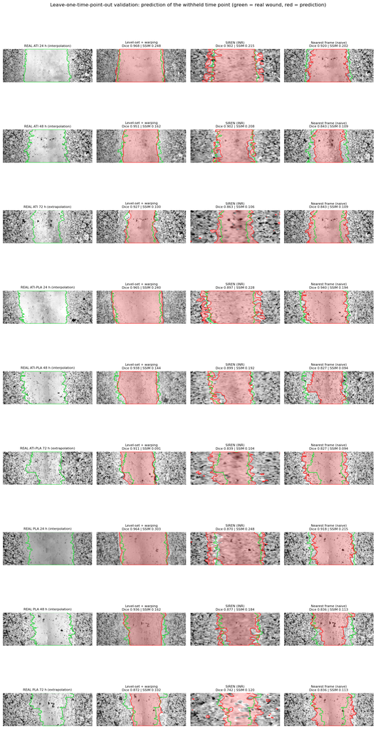

**Figure caption (English):** Leave-one-time-point-out validation of image prediction. Each row shows a withheld observation (left; green, reference wound) and its prediction from the remaining time points of the same treatment by level-set front propagation, the space–time implicit neural representation (SIREN) and the nearest observed frame (red, predicted wound). Panel titles give the Dice coefficient and the structural similarity index (SSIM) with respect to the real image.

```python
MONITOR.set_stage("zaman tahmini: LOTO doğrulama")
LOTO, LOTO_VIS = [], []
for dname in CFG["DRUGS"]:
    ser = SERIES[dname]
    for th in [tt for tt in ser["times"] if tt > 0]:
        keep = [tt for tt in ser["times"] if tt != th]
        kind = "interpolation" if th < max(keep) else "extrapolation"
        jj = ser["times"].index(th); real, rmask = ser["imgs"][jj], ser["masks"][jj]
        # kinetik model yalnızca kalan noktalarla
        tk = np.array(keep); yk = np.array([ser["masks"][ser["times"].index(tt)].sum() / ser["A0"] for tt in keep])
        name = KFIT[dname]["model"]
        p, _ = fit_kin(name, tk, yk)
        area = float(kin_predict(name, p, th)) * ser["A0"]
        out = {}
        out["Level-set + warping"] = predict_levelset(ser, th, area, use_times=keep)
        sm = fit_siren(ser, keep, iters=max(CFG["SIREN_ITERS"] // 2, 10), seed=int(th))
        out["SIREN (INR)"] = render_siren(sm, th, real.shape)
        out["Nearest frame (naive)"] = predict_nearest(ser, th, use_times=keep)
        for meth, (pim, pm) in out.items():
            LOTO.append(dict(ilaç=dname, gizlenen_t=th, tür=kind, yöntem=meth, kinetik=name, **img_scores(pim, real, pm, rmask)))
        LOTO_VIS.append((dname, th, kind, real, rmask, out))
        del sm
LOTO = pd.DataFrame(LOTO)
display(Markdown("**Zaman tahmini doğrulaması (LOTO) — her satır gerçek görüntüyle karşılaştırma**"))
display(LOTO.round(4))
display(LOTO.groupby(["tür", "yöntem"])[["Dice", "IoU", "AreaErr_pct", "SSIM", "PSNR"]].mean().round(4))
LOTO.to_csv(DIRS["tables"] / "temporal_LOTO_validation.csv", index=False)

nr = len(LOTO_VIS)
fig, axes = plt.subplots(nr, 4, figsize=(13, 2.9 * nr))
axes = np.atleast_2d(axes)
for r, (dname, th, kind, real, rmask, out) in enumerate(LOTO_VIS):
    axes[r, 0].imshow(overlay_rgb(real, gt=rmask)); axes[r, 0].set_title(f"REAL {DL(dname)} {int(th)} h ({kind})", fontsize=8)
    for c, (meth, (pim, pm)) in enumerate(out.items(), 1):
        sc = img_scores(pim, real, pm, rmask)
        axes[r, c].imshow(overlay_rgb(np.clip(pim, 0, 1), gt=rmask, pred=pm))
        axes[r, c].set_title(f"{meth}\nDice {sc['Dice']:.3f} | SSIM {sc['SSIM']:.3f}", fontsize=8)
for a in axes.ravel():
    a.set_axis_off()
plt.suptitle("Leave-one-time-point-out validation: prediction of the withheld time point (green = real wound, red = prediction)", y=1.0)
plt.tight_layout(); savefig("30_temporal_LOTO"); plt.show()
```

### 13.3 Hedef zamanlarda (12, 36, 60, 84, 96 h) görsel tahmin

Dört gözlem birlikte kullanılarak hedef zamanlar için görüntü ve maske üretilir. Tabloda tahmini göreli alan, kapanma yüzdesi ve %90 bootstrap aralığı; figürde 0–96 saatlik **tam zaman çizelgesi** (gözlenen kareler siyah, tahminler kırmızı başlıklı) yer alır. Görseller `outputs/temporal/` klasörüne de kaydedilir.

**Hedef zamanlar için tahmin edilen yara kapanması (%90 bootstrap tahmin aralığıyla)**

|  | ilaç | zaman_h | tür | kinetik | RA_tahmin | RA_p05 | RA_p95 | kapanma_pct | kapanma_p05 | kapanma_p95 | alan_px_orijinal | SIREN_RA |
| --- | --- | --- | --- | --- | --- | --- | --- | --- | --- | --- | --- | --- |
| 0 | ati | 12 | interpolation | Üstel | 0.8814 | 0.8677 | 0.8941 | 11.8601 | 10.5893 | 13.2254 | 393534.2924 | 0.8942 |
| 1 | ati | 36 | interpolation | Üstel | 0.6847 | 0.6534 | 0.7148 | 31.5272 | 28.5226 | 34.6602 | 305722.8594 | 0.6834 |
| 2 | ati | 60 | interpolation | Üstel | 0.5319 | 0.4920 | 0.5714 | 46.8059 | 42.8590 | 50.8003 | 237505.2659 | 0.5321 |
| 3 | ati | 84 | extrapolation | Üstel | 0.4132 | 0.3705 | 0.4568 | 58.6754 | 54.3199 | 62.9535 | 184509.4326 | 0.4335 |
| 4 | ati | 96 | extrapolation | Üstel | 0.3642 | 0.3215 | 0.4084 | 63.5765 | 59.1571 | 67.8530 | 162626.4712 | 0.3921 |
| 5 | ap | 12 | interpolation | Üstel | 0.8843 | 0.8694 | 0.8981 | 11.5705 | 10.1909 | 13.0646 | 420672.6313 | 0.8756 |
| 6 | ap | 36 | interpolation | Üstel | 0.6915 | 0.6570 | 0.7244 | 30.8501 | 27.5629 | 34.2962 | 328956.6651 | 0.6988 |
| 7 | ap | 60 | interpolation | Üstel | 0.5407 | 0.4966 | 0.5843 | 45.9263 | 41.5746 | 50.3426 | 257236.8143 | 0.5585 |
| 8 | ap | 84 | extrapolation | Üstel | 0.4228 | 0.3753 | 0.4712 | 57.7156 | 52.8759 | 62.4701 | 201153.4820 | 0.4443 |
| 9 | ap | 96 | extrapolation | Üstel | 0.3739 | 0.3263 | 0.4232 | 62.6081 | 57.6783 | 67.3732 | 177879.0375 | 0.4156 |
| 10 | PLA | 12 | interpolation | Üstel | 0.8795 | 0.8567 | 0.9000 | 12.0454 | 9.9957 | 14.3347 | 403682.8181 | 0.8689 |
| 11 | PLA | 36 | interpolation | Üstel | 0.6804 | 0.6287 | 0.7291 | 31.9581 | 27.0896 | 37.1342 | 312289.8242 | 0.6663 |
| 12 | PLA | 60 | interpolation | Üstel | 0.5264 | 0.4613 | 0.5906 | 47.3627 | 40.9370 | 53.8657 | 241588.0238 | 0.5210 |
| 13 | PLA | 84 | extrapolation | Üstel | 0.4072 | 0.3386 | 0.4785 | 59.2797 | 52.1545 | 66.1442 | 186892.9717 | 0.4623 |
| 14 | PLA | 96 | extrapolation | Üstel | 0.3582 | 0.2900 | 0.4306 | 64.1846 | 56.9370 | 70.9973 | 164381.0513 | 0.4362 |

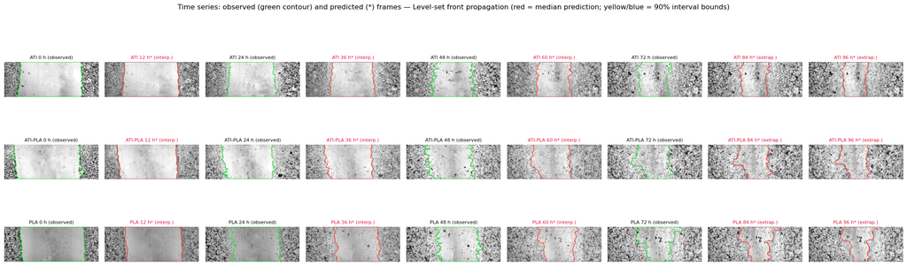

**Figure caption (English):** Observed (green contour, reference wound) and predicted (asterisk; 12, 36, 60, 84, 96 h) images for each treatment, obtained by level-set front propagation. Red contour, median predicted wound boundary; yellow and blue contours, boundaries corresponding to the 90% bootstrap interval of the wound area.

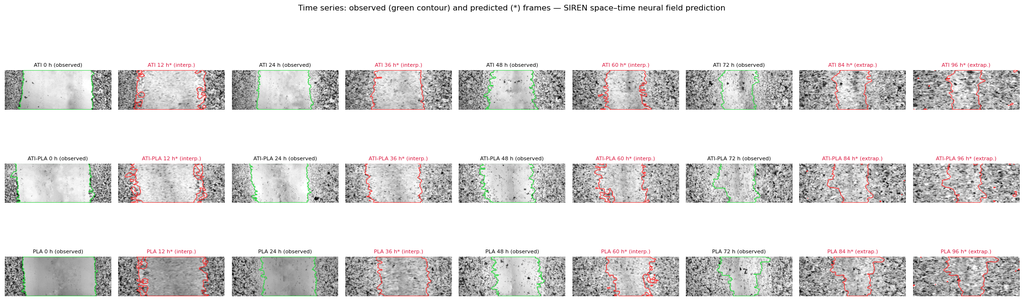

**Figure caption (English):** Observed (green contour) and predicted (asterisk; 12, 36, 60, 84, 96 h) images for each treatment, obtained with the space–time implicit neural representation (SIREN). Red contour, predicted wound boundary.

```python
MONITOR.set_stage("zaman tahmini: hedef zamanlar")
TT = sorted(set(CFG["TIME_TARGETS"]))
all_t = sorted(set(TT) | set(float(t) for t in CFG["TIMES_OBS"]))
TEMP_ROWS, TEMP_IMG = [], {}
for dname in CFG["DRUGS"]:
    ser = SERIES[dname]
    sm = fit_siren(ser, ser["times"], seed=1)
    B, _ = bootstrap_kin(dname, np.array(TT, float))
    lo, md, hi = np.percentile(B, [5, 50, 95], 0)
    for j, t in enumerate(TT):
        area = float(kin_predict(KFIT[dname]["model"], KFIT[dname]["p"], t)) * ser["A0"]
        img_ls, m_ls = predict_levelset(ser, t, area)
        _, m_lo = predict_levelset(ser, t, lo[j] * ser["A0"]); _, m_hi = predict_levelset(ser, t, hi[j] * ser["A0"])
        img_si, m_si = render_siren(sm, t, img_ls.shape)
        kind = "interpolation" if t < max(ser["times"]) else "extrapolation"
        TEMP_IMG[(dname, t)] = dict(ls=(img_ls, m_ls, m_lo, m_hi), siren=(img_si, m_si), kind=kind)
        scale = SCALE_AREA[ser["ids"][0]]
        TEMP_ROWS.append(dict(ilaç=dname, zaman_h=t, tür=kind, kinetik=KFIT[dname]["model"],
                              RA_tahmin=area / ser["A0"], RA_p05=lo[j], RA_p95=hi[j],
                              kapanma_pct=100 * (1 - area / ser["A0"]), kapanma_p05=100 * (1 - hi[j]), kapanma_p95=100 * (1 - lo[j]),
                              alan_px_orijinal=area * scale, SIREN_RA=m_si.sum() / ser["A0"]))
        st = f"{dname}_{int(t)}h"
        imwrite_any(DIRS["temporal"] / f"{st}_levelset.png", (np.clip(img_ls, 0, 1) * 255).astype(np.uint8))
        imwrite_any(DIRS["temporal"] / f"{st}_levelset_mask.png", (m_ls * 255).astype(np.uint8))
        imwrite_any(DIRS["temporal"] / f"{st}_siren.png", (img_si * 255).astype(np.uint8))
        imwrite_any(DIRS["temporal"] / f"{st}_overlay.png", cv2.cvtColor(overlay_rgb(np.clip(img_ls, 0, 1), pred=m_ls, fill_alpha=0.0), cv2.COLOR_RGB2BGR))
    del sm
TEMP = pd.DataFrame(TEMP_ROWS)
display(Markdown("**Hedef zamanlar için tahmin edilen yara kapanması (%90 bootstrap tahmin aralığıyla)**"))
display(TEMP.round(4)); TEMP.to_csv(DIRS["tables"] / "temporal_predictions.csv", index=False)

# Zaman çizelgesi figürü: gözlenen + tahmin edilen kareler
for meth in ["ls", "siren"]:
    fig, axes = plt.subplots(len(CFG["DRUGS"]), len(all_t), figsize=(2.4 * len(all_t), 2.4 * len(CFG["DRUGS"])))
    axes = np.atleast_2d(axes)
    for r, dname in enumerate(CFG["DRUGS"]):
        ser = SERIES[dname]
        for c, t in enumerate(all_t):
            a = axes[r, c]
            if t in ser["times"]:
                j = ser["times"].index(t)
                a.imshow(overlay_rgb(ser["imgs"][j], gt=ser["masks"][j])); a.set_title(f"{DL(dname)} {int(t)} h (observed)", fontsize=8)
            else:
                d = TEMP_IMG[(dname, t)]
                if meth == "ls":
                    im, m, mlo, mhi = d["ls"]
                    ov = overlay_rgb(np.clip(im, 0, 1), pred=m, fill_alpha=0.0)
                    for mm, col in [(mlo, (255, 200, 0)), (mhi, (0, 180, 255))]:
                        cs, _ = cv2.findContours(mm.astype(np.uint8), cv2.RETR_EXTERNAL, cv2.CHAIN_APPROX_NONE)
                        cv2.drawContours(ov, cs, -1, col, 1)
                else:
                    im, m = d["siren"]; ov = overlay_rgb(im, pred=m, fill_alpha=0.0)
                a.imshow(ov); a.set_title(f"{DL(dname)} {int(t)} h* ({d['kind'][:6]}.)", fontsize=8, color="crimson")
            a.set_axis_off()
    ttl = ("Level-set front propagation (red = median prediction; yellow/blue = 90% interval bounds)" if meth == "ls"
           else "SIREN space–time neural field prediction")
    plt.suptitle(f"Time series: observed (green contour) and predicted (*) frames — {ttl}", y=1.0)
    plt.tight_layout(); savefig(f"31_temporal_timeline_{meth}"); plt.show()
```

### 13.4 Sınırların birleşme zamanı tahmini (iki cephenin teması)

Level-set modelinde cephe her yerde eşit hızla ilerlediği için **en dar bölge ilk kapanır**. Son gözlenen karenin işaretli uzaklık fonksiyonu φ ve kinetik modelin alan tahmini birleştirilerek, ince bir zaman ızgarasında (1 saat adım) her an için genişlik profili hesaplanır. Raporlanan süreler:

- **İlk temas:** iki sınırın herhangi bir konumda ilk kez birleştiği an (min genişlik ≤ eşik),
- **%50 / %95 birleşme:** sınır konumlarının yarısının / %95'inin birleştiği an,
- **%99 kapanma:** yara alanının %1'in altına indiği an.

Belirsizlik, kinetik modelin parametrik bootstrap örnekleriyle (%90 aralık) verilir. Gözlenen karelerde zaten temas varsa bu, ölçülen değer olarak ayrıca belirtilir. Zaman ekstrapolasyonu olduğundan sonuçlar hipotez niteliğindedir.

**Sınırların birleşme zamanı tahmini (saat; inf = tahmin ufkunda gerçekleşmiyor)**

|  | ilaç | gözlenen_temas_zamanları | kinetik | ilk_temas_h | ilk_temas_h_%5 | ilk_temas_h_%95 | ilk_temas_h_bootstrap_sonlu_pct | birleşme50_h | birleşme50_h_%5 | birleşme50_h_%95 | birleşme50_h_bootstrap_sonlu_pct | birleşme95_h | birleşme95_h_%5 | birleşme95_h_%95 | birleşme95_h_bootstrap_sonlu_pct | kapanma99_h |
| --- | --- | --- | --- | --- | --- | --- | --- | --- | --- | --- | --- | --- | --- | --- | --- | --- |
| 0 | ati | [] | Üstel | 358.0 | 318.0 | 403.0 | 100.0 | inf | 422.0 | 477.5 | 43.7 | inf | inf | inf | 0.0 | 438.0 |
| 1 | ap | [] | Üstel | 245.0 | 215.0 | 279.0 | 100.0 | 350.0 | 307.0 | 399.0 | 100.0 | inf | inf | inf | 0.0 | 450.0 |
| 2 | PLA | [] | Üstel | 219.0 | 182.0 | 266.0 | 100.0 | 261.0 | 216.0 | 317.0 | 100.0 | inf | 479.0 | 479.0 | 0.3 | 431.0 |

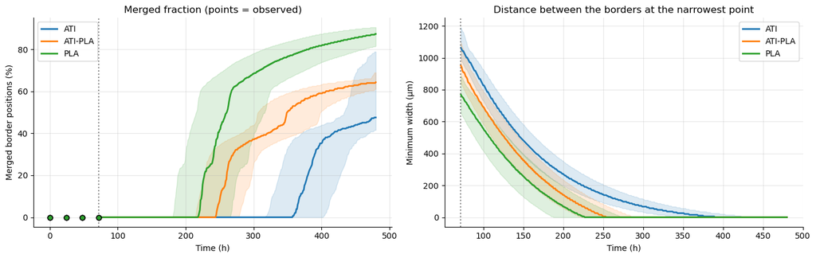

**Figure caption (English):** Predicted merging of the two wound borders beyond the last observation (dotted vertical line). Left, percentage of border positions in contact (lines, median prediction; shaded bands, 90% bootstrap intervals; points, observed values). Right, smallest distance between the two borders (µm).

```python
MONITOR.set_stage("birleşme zamanı")
T_MAX_MERGE = float(max(CFG["TIME_TARGETS"]) * 5)

def merge_curves(dname, ra_curves, tg):
    ser = SERIES[dname]; j = int(np.argmax(ser["times"])); i_last = ser["ids"][j]
    phi = sdf(ser["masks"][j]); phc = to_canon(phi, ORIENT[i_last])
    rows_sorted = np.sort(phc, axis=1); flat = np.sort(phi.ravel()); n = flat.size
    thr = MERGE_THR_W[i_last]; t_last = ser["times"][j]
    out = []
    for ra in np.atleast_2d(ra_curves):
        k = np.clip(np.round(ra * ser["A0"]).astype(int), 0, n - 1)
        cs = np.where(k <= 0, flat[0] - 1, 0.5 * (flat[np.maximum(k - 1, 0)] + flat[k]))
        W = np.stack([np.searchsorted(r, cs) for r in rows_sorted])          # (satır, zaman) genişlik
        out.append(dict(min_w=W.min(0), merged=(W <= thr).mean(0)))
    return out, t_last

def first_time(tg, cond):
    j = np.flatnonzero(cond)
    return float(tg[j[0]]) if len(j) else np.inf

MERGE_ROWS, MERGE_CURVES = [], {}
for dname in CFG["DRUGS"]:
    ser = SERIES[dname]
    t_last = max(ser["times"])
    tg = np.arange(t_last, T_MAX_MERGE + 1, 1.0)
    obs_contact = [t for t, m_ in zip(ser["times"], ser["masks"])
                   if np.any(width_track(ser["ids"][ser["times"].index(t)])[0] <= MERGE_THR_W[ser["ids"][0]])]
    med = kin_predict(KFIT[dname]["model"], KFIT[dname]["p"], tg)[None]
    Bt, _ = bootstrap_kin(dname, tg, n=min(CFG["MC_DRAWS"], 300))
    (mc,), _ = merge_curves(dname, med, tg)
    bc, _ = merge_curves(dname, Bt, tg)
    MERGE_CURVES[dname] = dict(tg=tg, med=mc, boot=bc)
    def stat(fn):
        v = np.array([fn(b) for b in bc]); fin = v[np.isfinite(v)]
        lo, hi = (np.percentile(fin, [5, 95]) if len(fin) else (np.inf, np.inf))
        return fn(mc), lo, hi, 100 * len(fin) / len(v)
    rows = {}
    for key, fn in [("ilk_temas_h", lambda c: first_time(tg, c["min_w"] <= MERGE_THR_W[ser["ids"][0]])),
                    ("birleşme50_h", lambda c: first_time(tg, c["merged"] >= 0.5)),
                    ("birleşme95_h", lambda c: first_time(tg, c["merged"] >= 0.95))]:
        m_, lo, hi, pf = stat(fn)
        rows[key] = m_; rows[key + "_%5"] = lo; rows[key + "_%95"] = hi; rows[key + "_bootstrap_sonlu_pct"] = pf
    rows["kapanma99_h"] = first_time(tg, med[0] <= 0.01)
    MERGE_ROWS.append(dict(ilaç=dname, gözlenen_temas_zamanları=obs_contact, kinetik=KFIT[dname]["model"], **rows))
MERGE_TABLE = pd.DataFrame(MERGE_ROWS)
display(Markdown("**Sınırların birleşme zamanı tahmini (saat; inf = tahmin ufkunda gerçekleşmiyor)**"))
display(MERGE_TABLE.round(1)); MERGE_TABLE.to_csv(DIRS["tables"] / "merge_time_predictions.csv", index=False)

fig, ax = plt.subplots(1, 2, figsize=(14, 4.5))
for dname in CFG["DRUGS"]:
    mcv = MERGE_CURVES[dname]; tg = mcv["tg"]
    B = np.array([b["merged"] for b in mcv["boot"]]) * 100
    lo, hi = np.percentile(B, [5, 95], 0)
    l_, = ax[0].plot(tg, 100 * mcv["med"]["merged"], lw=2, label=DL(dname))
    ax[0].fill_between(tg, lo, hi, alpha=0.15, color=l_.get_color())
    ser = SERIES[dname]
    obs = [100 * np.mean(width_track(i)[0] <= MERGE_THR_W[i]) for i in ser["ids"]]
    ax[0].scatter(ser["times"], obs, color=l_.get_color(), edgecolor="k", zorder=5)
    Bm = np.array([to_len(b["min_w"], ser["ids"][0]) for b in mcv["boot"]])
    ax[1].plot(tg, to_len(mcv["med"]["min_w"], ser["ids"][0]), lw=2, color=l_.get_color(), label=DL(dname))
    ax[1].fill_between(tg, *np.percentile(Bm, [5, 95], 0), alpha=0.15, color=l_.get_color())
ax[0].set_xlabel("Time (h)"); ax[0].set_ylabel("Merged border positions (%)"); ax[0].set_title("Merged fraction (points = observed)")
ax[1].set_xlabel("Time (h)"); ax[1].set_ylabel(f"Minimum width ({UNIT_LEN})"); ax[1].set_title("Distance between the borders at the narrowest point")
for a in ax:
    a.legend(); a.grid(alpha=0.3); a.axvline(max(CFG["TIMES_OBS"]), color="gray", ls=":")
plt.tight_layout(); savefig("32_merge_time"); plt.show()
```

## 14. Doz tahmini: 1.41, 1.5, 2.1, 2.25, 2.5 µM (veride tek doz: 1 µM)

### Durumun dürüst tespiti

Üç grubun (ati, ap, **PLA**) hepsi **1 µM** uygulanmıştır; veride 0 µM (ilaçsız) grup ve ikinci bir doz düzeyi **yoktur**. Bu, doz ekseninde **tek bir gözlem noktası** olduğu anlamına gelir: doz–yanıt eğrisinin şekli (eğim, doyum, Hill katsayısı) ve hatta ilaçsız kapanma hızı veriden **belirlenemez** (tanımlanamazlık / non-identifiability). Hedef dozların tümü ekstrapolasyondur: 1.41–1.5 µM "yakın", 2.1–2.5 µM "uzak" ekstrapolasyon.

"Hayatta zor diye bir şey yok" — ama bu tahminler bir ölçüm değil, **varsayımları açıkça yazılmış farmakodinamik senaryolardır**. Bu yüzden her tahmini belirsizlik aralığı ve bir **duyarlılık analiziyle** (sonucun bilinmeyen parametrelere ne kadar bağlı olduğu) birlikte veriyoruz.

### Modeller (Emax/Hill farmakodinamiği; Hill 1910; Holford & Sheiner 1981)

H(d) = dⁿ / (EC50ⁿ + dⁿ) — reseptör doluluğu. Kinetik hız parametresi k (tek parametreli lineer/üstel kapanma modelinden, LOTO hatasına göre seçilir):

- **Model A — kontrol-referanslı (ana senaryo):** PLA kontrolünün etkisi dozdan bağımsızdır; ilaca özgü etki Δk = k<sub>ilaç</sub>(1 µM) − k<sub>PLA</sub>(1 µM) (**veriden ölçülür**) doluluk oranıyla ölçeklenir: k<sub>ilaç</sub>(d) = k<sub>PLA</sub> + Δk · H(d)/H(1). PLA bu modelde dozdan etkilenmez.
- **Model B — bilinmeyen ilaçsız taban:** k<sub>X</sub>(d) = k₀ + (k<sub>X</sub>(1) − k₀) · H(d)/H(1), k₀ = ρ · min k(1), ρ ~ Beta(2, 2). Üç grubun (PLA dahil) hepsi için tahmin üretir.
- **Öncüller (Monte Carlo):** log EC50 ~ N(ln 1 µM, 0.7²) (EC50 büyük olasılıkla 0.3–3 µM), log n ~ N(0, 0.35²); k(1 µM) değerleri kinetik bootstrap dağılımından.
- **Deterministik senaryolar (Model A biçiminde):** S1 doğrusal-orantılı (doyumsuz, üst sınır), S2 Emax EC50 = 1 µM, S3 EC50 = 0.5 µM (erken doyum), S4 Hill EC50 = 1.5 µM, n = 2.
- **Duyarlılık ısı haritası:** 2.5 µM / 72 h kapanma tahmininin EC50 × n düzlemindeki değişimi — makalede "sonuç varsayıma ne kadar bağlı?" sorusunun görsel yanıtı.

> ⚠️ Yüksek dozlarda sitotoksisite veya hormesis olabilir; bu modeller öngöremez. Makalede **gelecek çalışma** olarak araç (vehicle, 0 µM) kontrolü + 0.25, 0.5, 1, 2, 4 µM ve her koşulda ≥3 tekrarlı bir doz–yanıt deneyi önerin; o zaman bu bölüm doğrudan **interpolasyona** dönüşür.

```python
if not CFG.get("DOSE_ANALYSIS", True):
    print("⏭ Doz analizi kapalı (ayar: DOZ_ANALIZI = False).")
else:
    MONITOR.set_stage("doz tahmini")
    ONE_PARAM = ["Lineer", "Üstel"]
    fam_score = {m: np.mean([KFIT[d]["all"][m]["loto"] for d in CFG["DRUGS"]]) for m in ONE_PARAM}
    DOSE_FAM = min(fam_score, key=fam_score.get)
    print(f"Doz modellemesi için kinetik aile: {DOSE_FAM} (ortalama LOTO RMSE: { {k: round(v, 5) for k, v in fam_score.items()} })")
    print("Veri: tüm gruplar", {d: CFG["DOSE_UM"].get(d) for d in CFG["DRUGS"]}, "µM → doz ekseninde tek gözlem noktası.")

    ctrl = CFG["CONTROL"]
    active = [d for d in CFG["DRUGS"] if d != ctrl]
    k_hat = {d: float(fit_kin(DOSE_FAM, KFIT[d]["t"], KFIT[d]["y"])[0][0]) for d in CFG["DRUGS"]}
    k_boot = {d: bootstrap_kin(d, np.array([0.0]), n=CFG["MC_DRAWS"], model=DOSE_FAM, seed=11 + j)[1][:, 0] for j, d in enumerate(CFG["DRUGS"])}
    print("k(1 µM):", {d: round(v, 5) for d, v in k_hat.items()}, "| Δk (ilaç − PLA):", {d: round(k_hat[d] - k_hat[ctrl], 5) for d in active})

    def hill(d, ec50, n):
        d = np.asarray(d, float)
        return d ** n / (ec50 ** n + d ** n)

    def ra_of(k, t):
        k = np.maximum(np.asarray(k, float), 0)
        return np.maximum(0, 1 - k * t) if DOSE_FAM == "Lineer" else np.exp(-k * t)

    SCEN = OrderedDict([
        ("S1 linear-proportional", lambda d: np.asarray(d, float)),
        ("S2 Emax EC50=1, n=1", lambda d: hill(d, 1.0, 1.0) / hill(1.0, 1.0, 1.0)),
        ("S3 Emax EC50=0.5, n=1", lambda d: hill(d, 0.5, 1.0) / hill(1.0, 0.5, 1.0)),
        ("S4 Hill EC50=1.5, n=2", lambda d: hill(d, 1.5, 2.0) / hill(1.0, 1.5, 2.0)),
    ])
    DOSES = sorted(set([1.0] + list(CFG["DOSE_TARGETS"])))
    T_DOSE = sorted(set(float(t) for t in CFG["TIMES_OBS"] if t > 0) | set(float(t) for t in CFG["TIME_TARGETS"]))

    def dose_label(d):
        return "gözlenen" if d == 1.0 else ("yakın ekstrapolasyon" if 0.5 <= d <= 1.5 else "uzak ekstrapolasyon")

    rng = np.random.default_rng(2024)
    nmc = CFG["MC_DRAWS"]
    ec50_s = np.exp(rng.normal(np.log(1.0), 0.7, nmc)); n_s = np.exp(rng.normal(0, 0.35, nmc)); rho_s = rng.beta(2, 2, nmc)
    KB = {d: rng.choice(k_boot[d], nmc) for d in CFG["DRUGS"]}
    kmin_s = np.min(np.stack([KB[d] for d in CFG["DRUGS"]]), 0)

    def k_mc(model, dname, dose):
        ratio = hill(dose, ec50_s, n_s) / hill(1.0, ec50_s, n_s)
        if model == "A":
            if dname == ctrl:
                return KB[ctrl].copy()
            return KB[ctrl] + (KB[dname] - KB[ctrl]) * ratio
        k0 = rho_s * kmin_s
        return k0 + (KB[dname] - k0) * ratio

    DOSE_ROWS, DOSE_MC = [], {}
    for dname in CFG["DRUGS"]:
        for dose in DOSES:
            if dname != ctrl:
                for sname, f in SCEN.items():
                    kd = k_hat[ctrl] + (k_hat[dname] - k_hat[ctrl]) * float(f(dose))
                    for t in T_DOSE:
                        ra = float(ra_of(kd, t))
                        DOSE_ROWS.append(dict(model="A", senaryo=sname, ilaç=dname, doz_uM=dose, doz_türü=dose_label(dose), zaman_h=t,
                                              k=kd, RA=ra, kapanma_pct=100 * (1 - ra), RA_p05=np.nan, RA_p95=np.nan))
            for model in ["A", "B"]:
                kd = k_mc(model, dname, dose)
                for t in T_DOSE:
                    ra = ra_of(kd, t); lo, md, hi = np.percentile(ra, [5, 50, 95])
                    DOSE_MC[(model, dname, dose, t)] = (lo, md, hi)
                    DOSE_ROWS.append(dict(model=model, senaryo=f"MC model {model} (medyan)", ilaç=dname, doz_uM=dose, doz_türü=dose_label(dose),
                                          zaman_h=t, k=float(np.median(kd)), RA=md, kapanma_pct=100 * (1 - md), RA_p05=lo, RA_p95=hi))
    DOSE = pd.DataFrame(DOSE_ROWS)
    DOSE.to_csv(DIRS["tables"] / "dose_predictions_all_scenarios.csv", index=False)
    piv = DOSE[(DOSE["zaman_h"].isin([48.0, 72.0])) & (DOSE["model"] == "A")].pivot_table(
        index=["ilaç", "senaryo", "zaman_h"], columns="doz_uM", values="kapanma_pct")
    display(Markdown("**Model A — tahmini yara kapanması (%) — senaryo × doz (48 ve 72 saat)**")); display(piv.round(2))
    for model in ["A", "B"]:
        mc = DOSE[DOSE["senaryo"] == f"MC model {model} (medyan)"]
        tmp = mc.assign(aralık=lambda x: [f"{100*(1-a):.1f}–{100*(1-b):.1f}" for a, b in zip(x["RA_p95"], x["RA_p05"])])
        display(Markdown(f"**Monte Carlo model {model}: medyan kapanma % ve %90 aralık**"))
        display(tmp.pivot_table(index=["ilaç", "zaman_h"], columns="doz_uM", values="kapanma_pct").round(2))
        display(tmp.pivot_table(index=["ilaç", "zaman_h"], columns="doz_uM", values="aralık", aggfunc="first"))
```

```
Doz modellemesi için kinetik aile: Üstel (ortalama LOTO RMSE: {'Lineer': np.float64(0.06365), 'Üstel': np.float64(0.0417)})
Veri: tüm gruplar {'ati': 1.0, 'ap': 1.0, 'PLA': 1.0} µM → doz ekseninde tek gözlem noktası.
k(1 µM): {'ati': 0.01052, 'ap': 0.01025, 'PLA': 0.0107} | Δk (ilaç − PLA): {'ati': -0.00018, 'ap': -0.00045}
```

**Model A — tahmini yara kapanması (%) — senaryo × doz (48 ve 72 saat)**

| ilaç | senaryo | doz_uM zaman_h | 1.00 | 1.41 | 1.50 | 2.10 | 2.25 | 2.50 |
| --- | --- | --- | --- | --- | --- | --- | --- | --- |
| PLA | MC model A (medyan) | 48.0 | 40.12 | 40.12 | 40.12 | 40.12 | 40.12 | 40.12 |
|  |  | 72.0 | 53.66 | 53.66 | 53.66 | 53.66 | 53.66 | 53.66 |
| ap | MC model A (medyan) | 48.0 | 38.95 | 38.62 | 38.60 | 38.37 | 38.33 | 38.27 |
|  |  | 72.0 | 52.30 | 51.92 | 51.89 | 51.62 | 51.57 | 51.51 |
|  | S1 linear-proportional | 48.0 | 38.85 | 38.31 | 38.19 | 37.39 | 37.18 | 36.84 |
|  |  | 72.0 | 52.18 | 51.55 | 51.40 | 50.45 | 50.21 | 49.81 |
|  | S2 Emax EC50=1, n=1 | 48.0 | 38.85 | 38.63 | 38.59 | 38.38 | 38.34 | 38.28 |
|  |  | 72.0 | 52.18 | 51.92 | 51.87 | 51.63 | 51.59 | 51.52 |
|  | S3 Emax EC50=0.5, n=1 | 48.0 | 38.85 | 38.71 | 38.69 | 38.57 | 38.55 | 38.52 |
|  |  | 72.0 | 52.18 | 52.02 | 51.99 | 51.85 | 51.83 | 51.80 |
|  | S4 Hill EC50=1.5, n=2 | 48.0 | 38.85 | 38.16 | 38.02 | 37.31 | 37.18 | 36.99 |
|  |  | 72.0 | 52.18 | 51.37 | 51.21 | 50.37 | 50.21 | 49.99 |
| ati | MC model A (medyan) | 48.0 | 39.60 | 39.57 | 39.55 | 39.50 | 39.49 | 39.41 |
|  |  | 72.0 | 53.06 | 53.03 | 53.00 | 52.94 | 52.93 | 52.83 |
|  | S1 linear-proportional | 48.0 | 39.65 | 39.44 | 39.39 | 39.09 | 39.01 | 38.88 |
|  |  | 72.0 | 53.11 | 52.87 | 52.82 | 52.46 | 52.37 | 52.22 |
|  | S2 Emax EC50=1, n=1 | 48.0 | 39.65 | 39.56 | 39.55 | 39.47 | 39.45 | 39.43 |
|  |  | 72.0 | 53.11 | 53.01 | 53.00 | 52.90 | 52.89 | 52.86 |
|  | S3 Emax EC50=0.5, n=1 | 48.0 | 39.65 | 39.59 | 39.58 | 39.54 | 39.53 | 39.52 |
|  |  | 72.0 | 53.11 | 53.05 | 53.04 | 52.99 | 52.98 | 52.97 |
|  | S4 Hill EC50=1.5, n=2 | 48.0 | 39.65 | 39.38 | 39.33 | 39.06 | 39.01 | 38.94 |
|  |  | 72.0 | 53.11 | 52.80 | 52.74 | 52.43 | 52.37 | 52.28 |

**Monte Carlo model A: medyan kapanma % ve %90 aralık**

| ilaç | doz_uM zaman_h | 1.00 | 1.41 | 1.50 | 2.10 | 2.25 | 2.50 |
| --- | --- | --- | --- | --- | --- | --- | --- |
| PLA | 12.0 | 12.03 | 12.03 | 12.03 | 12.03 | 12.03 | 12.03 |
|  | 24.0 | 22.62 | 22.62 | 22.62 | 22.62 | 22.62 | 22.62 |
|  | 36.0 | 31.93 | 31.93 | 31.93 | 31.93 | 31.93 | 31.93 |
|  | 48.0 | 40.12 | 40.12 | 40.12 | 40.12 | 40.12 | 40.12 |
|  | 60.0 | 47.32 | 47.32 | 47.32 | 47.32 | 47.32 | 47.32 |
|  | 72.0 | 53.66 | 53.66 | 53.66 | 53.66 | 53.66 | 53.66 |
|  | 84.0 | 59.24 | 59.24 | 59.24 | 59.24 | 59.24 | 59.24 |
|  | 96.0 | 64.14 | 64.14 | 64.14 | 64.14 | 64.14 | 64.14 |
| ap | 12.0 | 11.61 | 11.49 | 11.48 | 11.40 | 11.38 | 11.36 |
|  | 24.0 | 21.87 | 21.66 | 21.64 | 21.50 | 21.47 | 21.43 |
|  | 36.0 | 30.93 | 30.66 | 30.64 | 30.44 | 30.41 | 30.36 |
|  | 48.0 | 38.95 | 38.62 | 38.60 | 38.37 | 38.33 | 38.27 |
|  | 60.0 | 46.04 | 45.68 | 45.65 | 45.39 | 45.35 | 45.29 |
|  | 72.0 | 52.30 | 51.92 | 51.89 | 51.62 | 51.57 | 51.51 |
|  | 84.0 | 57.84 | 57.44 | 57.41 | 57.13 | 57.08 | 57.02 |
|  | 96.0 | 62.73 | 62.33 | 62.30 | 62.02 | 61.97 | 61.90 |
| ati | 12.0 | 11.84 | 11.83 | 11.82 | 11.81 | 11.80 | 11.77 |
|  | 24.0 | 22.28 | 22.27 | 22.25 | 22.22 | 22.21 | 22.16 |
|  | 36.0 | 31.49 | 31.46 | 31.44 | 31.40 | 31.39 | 31.32 |
|  | 48.0 | 39.60 | 39.57 | 39.55 | 39.50 | 39.49 | 39.41 |
|  | 60.0 | 46.76 | 46.72 | 46.70 | 46.64 | 46.63 | 46.54 |
|  | 72.0 | 53.06 | 53.03 | 53.00 | 52.94 | 52.93 | 52.83 |
|  | 84.0 | 58.62 | 58.59 | 58.56 | 58.50 | 58.48 | 58.39 |
|  | 96.0 | 63.52 | 63.49 | 63.46 | 63.40 | 63.38 | 63.28 |

| ilaç | doz_uM zaman_h | 1.00 | 1.41 | 1.50 | 2.10 | 2.25 | 2.50 |
| --- | --- | --- | --- | --- | --- | --- | --- |
| PLA | 12.0 | 9.9–14.3 | 9.9–14.3 | 9.9–14.3 | 9.9–14.3 | 9.9–14.3 | 9.9–14.3 |
|  | 24.0 | 18.9–26.6 | 18.9–26.6 | 18.9–26.6 | 18.9–26.6 | 18.9–26.6 | 18.9–26.6 |
|  | 36.0 | 26.9–37.1 | 26.9–37.1 | 26.9–37.1 | 26.9–37.1 | 26.9–37.1 | 26.9–37.1 |
|  | 48.0 | 34.2–46.1 | 34.2–46.1 | 34.2–46.1 | 34.2–46.1 | 34.2–46.1 | 34.2–46.1 |
|  | 60.0 | 40.7–53.8 | 40.7–53.8 | 40.7–53.8 | 40.7–53.8 | 40.7–53.8 | 40.7–53.8 |
|  | 72.0 | 46.6–60.4 | 46.6–60.4 | 46.6–60.4 | 46.6–60.4 | 46.6–60.4 | 46.6–60.4 |
|  | 84.0 | 51.9–66.0 | 51.9–66.0 | 51.9–66.0 | 51.9–66.0 | 51.9–66.0 | 51.9–66.0 |
|  | 96.0 | 56.7–70.9 | 56.7–70.9 | 56.7–70.9 | 56.7–70.9 | 56.7–70.9 | 56.7–70.9 |
| ap | 12.0 | 10.1–13.0 | 9.7–13.3 | 9.6–13.4 | 9.1–13.6 | 8.9–13.7 | 8.7–13.7 |
|  | 24.0 | 19.2–24.3 | 18.4–24.8 | 18.2–24.9 | 17.3–25.4 | 17.1–25.5 | 16.7–25.6 |
|  | 36.0 | 27.4–34.2 | 26.3–34.8 | 26.0–35.0 | 24.8–35.6 | 24.5–35.7 | 24.0–35.8 |
|  | 48.0 | 34.8–42.8 | 33.4–43.5 | 33.1–43.7 | 31.6–44.4 | 31.2–44.5 | 30.6–44.7 |
|  | 60.0 | 41.4–50.2 | 39.8–51.0 | 39.5–51.2 | 37.8–52.0 | 37.4–52.1 | 36.7–52.3 |
|  | 72.0 | 47.3–56.7 | 45.6–57.5 | 45.3–57.7 | 43.4–58.5 | 43.0–58.6 | 42.2–58.8 |
|  | 84.0 | 52.6–62.3 | 50.9–63.2 | 50.5–63.4 | 48.5–64.2 | 48.1–64.3 | 47.3–64.5 |
|  | 96.0 | 57.4–67.2 | 55.6–68.1 | 55.2–68.3 | 53.2–69.1 | 52.7–69.2 | 51.9–69.4 |
| ati | 12.0 | 10.6–13.3 | 10.2–13.6 | 10.1–13.6 | 9.6–13.9 | 9.5–14.0 | 9.4–14.1 |
|  | 24.0 | 20.0–24.8 | 19.3–25.3 | 19.2–25.4 | 18.3–25.9 | 18.2–26.1 | 17.9–26.2 |
|  | 36.0 | 28.5–34.8 | 27.5–35.4 | 27.3–35.5 | 26.2–36.2 | 26.0–36.4 | 25.6–36.7 |
|  | 48.0 | 36.0–43.4 | 34.9–44.2 | 34.6–44.3 | 33.3–45.1 | 33.0–45.3 | 32.6–45.6 |
|  | 60.0 | 42.8–51.0 | 41.5–51.7 | 41.2–51.9 | 39.7–52.8 | 39.4–53.0 | 38.9–53.3 |
|  | 72.0 | 48.8–57.5 | 47.5–58.3 | 47.2–58.4 | 45.5–59.3 | 45.2–59.6 | 44.6–59.9 |
|  | 84.0 | 54.3–63.1 | 52.8–63.9 | 52.5–64.1 | 50.8–65.0 | 50.4–65.2 | 49.8–65.6 |
|  | 96.0 | 59.1–68.0 | 57.6–68.8 | 57.3–69.0 | 55.5–69.9 | 55.2–70.1 | 54.6–70.4 |

**Monte Carlo model B: medyan kapanma % ve %90 aralık**

| ilaç | doz_uM zaman_h | 1.00 | 1.41 | 1.50 | 2.10 | 2.25 | 2.50 |
| --- | --- | --- | --- | --- | --- | --- | --- |
| PLA | 12.0 | 12.03 | 13.03 | 13.21 | 14.04 | 14.19 | 14.37 |
|  | 24.0 | 22.62 | 24.36 | 24.68 | 26.11 | 26.36 | 26.68 |
|  | 36.0 | 31.93 | 34.22 | 34.63 | 36.49 | 36.81 | 37.22 |
|  | 48.0 | 40.12 | 42.79 | 43.27 | 45.41 | 45.77 | 46.24 |
|  | 60.0 | 47.32 | 50.24 | 50.76 | 53.07 | 53.46 | 53.97 |
|  | 72.0 | 53.66 | 56.73 | 57.27 | 59.66 | 60.07 | 60.59 |
|  | 84.0 | 59.24 | 62.37 | 62.91 | 65.33 | 65.73 | 66.25 |
|  | 96.0 | 64.14 | 67.27 | 67.81 | 70.20 | 70.59 | 71.10 |
| ap | 12.0 | 11.61 | 12.50 | 12.66 | 13.38 | 13.52 | 13.71 |
|  | 24.0 | 21.87 | 23.45 | 23.72 | 24.97 | 25.21 | 25.54 |
|  | 36.0 | 30.93 | 33.02 | 33.38 | 35.01 | 35.32 | 35.75 |
|  | 48.0 | 38.95 | 41.39 | 41.81 | 43.71 | 44.06 | 44.56 |
|  | 60.0 | 46.04 | 48.72 | 49.18 | 51.24 | 51.62 | 52.17 |
|  | 72.0 | 52.30 | 55.13 | 55.62 | 57.77 | 58.16 | 58.72 |
|  | 84.0 | 57.84 | 60.74 | 61.24 | 63.42 | 63.82 | 64.38 |
|  | 96.0 | 62.73 | 65.65 | 66.14 | 68.31 | 68.71 | 69.27 |
| ati | 12.0 | 11.84 | 12.83 | 12.98 | 13.77 | 13.90 | 14.11 |
|  | 24.0 | 22.28 | 24.01 | 24.27 | 25.64 | 25.88 | 26.23 |
|  | 36.0 | 31.49 | 33.76 | 34.10 | 35.88 | 36.18 | 36.64 |
|  | 48.0 | 39.60 | 42.26 | 42.66 | 44.71 | 45.06 | 45.59 |
|  | 60.0 | 46.76 | 49.67 | 50.10 | 52.32 | 52.70 | 53.27 |
|  | 72.0 | 53.06 | 56.12 | 56.57 | 58.88 | 59.27 | 59.86 |
|  | 84.0 | 58.62 | 61.75 | 62.21 | 64.54 | 64.94 | 65.53 |
|  | 96.0 | 63.52 | 66.66 | 67.12 | 69.42 | 69.81 | 70.39 |

| ilaç | doz_uM zaman_h | 1.00 | 1.41 | 1.50 | 2.10 | 2.25 | 2.50 |
| --- | --- | --- | --- | --- | --- | --- | --- |
| PLA | 12.0 | 9.9–14.3 | 10.5–16.4 | 10.6–16.8 | 11.0–19.3 | 11.1–20.0 | 11.2–20.8 |
|  | 24.0 | 18.9–26.6 | 19.9–30.1 | 20.1–30.8 | 20.8–34.9 | 20.9–35.9 | 21.1–37.2 |
|  | 36.0 | 26.9–37.1 | 28.4–41.6 | 28.5–42.4 | 29.5–47.5 | 29.6–48.7 | 29.9–50.3 |
|  | 48.0 | 34.2–46.1 | 35.9–51.2 | 36.1–52.1 | 37.3–57.6 | 37.4–58.9 | 37.7–60.6 |
|  | 60.0 | 40.7–53.8 | 42.6–59.2 | 42.8–60.2 | 44.2–65.8 | 44.3–67.1 | 44.7–68.8 |
|  | 72.0 | 46.6–60.4 | 48.7–65.9 | 48.9–66.9 | 50.4–72.4 | 50.5–73.7 | 50.8–75.3 |
|  | 84.0 | 51.9–66.0 | 54.1–71.5 | 54.3–72.4 | 55.8–77.8 | 56.0–78.9 | 56.3–80.4 |
|  | 96.0 | 56.7–70.9 | 58.9–76.1 | 59.1–77.1 | 60.7–82.1 | 60.8–83.1 | 61.2–84.5 |
| ap | 12.0 | 10.1–13.0 | 10.8–14.9 | 10.9–15.3 | 11.2–18.1 | 11.2–18.7 | 11.3–19.6 |
|  | 24.0 | 19.2–24.3 | 20.4–27.5 | 20.5–28.3 | 21.1–32.8 | 21.2–33.8 | 21.4–35.3 |
|  | 36.0 | 27.4–34.2 | 29.0–38.3 | 29.2–39.3 | 29.9–45.0 | 30.0–46.2 | 30.3–48.0 |
|  | 48.0 | 34.8–42.8 | 36.6–47.5 | 36.9–48.6 | 37.7–54.9 | 37.9–56.2 | 38.2–58.1 |
|  | 60.0 | 41.4–50.2 | 43.4–55.3 | 43.7–56.5 | 44.7–63.0 | 44.9–64.4 | 45.2–66.3 |
|  | 72.0 | 47.3–56.7 | 49.5–62.0 | 49.8–63.1 | 50.9–69.7 | 51.0–71.0 | 51.4–72.9 |
|  | 84.0 | 52.6–62.3 | 55.0–67.6 | 55.3–68.8 | 56.4–75.2 | 56.5–76.4 | 56.9–78.2 |
|  | 96.0 | 57.4–67.2 | 59.8–72.4 | 60.2–73.6 | 61.2–79.7 | 61.4–80.8 | 61.8–82.5 |
| ati | 12.0 | 10.6–13.3 | 11.3–15.3 | 11.3–15.8 | 11.7–18.6 | 11.7–19.2 | 11.8–20.2 |
|  | 24.0 | 20.0–24.8 | 21.2–28.2 | 21.4–29.1 | 22.0–33.8 | 22.1–34.8 | 22.2–36.3 |
|  | 36.0 | 28.5–34.8 | 30.1–39.2 | 30.3–40.3 | 31.1–46.1 | 31.2–47.3 | 31.4–49.2 |
|  | 48.0 | 36.0–43.4 | 38.0–48.5 | 38.2–49.7 | 39.1–56.2 | 39.3–57.5 | 39.5–59.5 |
|  | 60.0 | 42.8–51.0 | 44.9–56.3 | 45.2–57.6 | 46.2–64.3 | 46.4–65.7 | 46.6–67.7 |
|  | 72.0 | 48.8–57.5 | 51.1–63.0 | 51.4–64.3 | 52.5–71.0 | 52.7–72.3 | 52.9–74.2 |
|  | 84.0 | 54.3–63.1 | 56.6–68.6 | 56.9–69.9 | 58.0–76.4 | 58.2–77.6 | 58.5–79.4 |
|  | 96.0 | 59.1–68.0 | 61.5–73.4 | 61.8–74.7 | 62.9–80.8 | 63.1–81.9 | 63.4–83.6 |

### 14.1 Doz-yanıt eğrileri ve duyarlılık analizi

```python
if not CFG.get("DOSE_ANALYSIS", True):
    print("⏭ Doz analizi kapalı (ayar: DOZ_ANALIZI = False).")
else:
    dgrid = np.linspace(0.25, max(DOSES) * 1.1, 80)
    fig, axes = plt.subplots(1, len(active), figsize=(6.5 * len(active), 4.6), sharey=True)
    for a, dname in zip(np.atleast_1d(axes), active):
        for t, ls in [(48.0, "-"), (72.0, "--")]:
            for si, (sname, f) in enumerate(SCEN.items()):
                kd = k_hat[ctrl] + (k_hat[dname] - k_hat[ctrl]) * f(dgrid)
                a.plot(dgrid, 100 * (1 - ra_of(kd, t)), ls=ls, lw=1, alpha=0.8, color=plt.cm.tab10(si), label=sname if t == 72.0 else None)
            R = hill(dgrid[None], ec50_s[:600, None], n_s[:600, None]) / hill(1.0, ec50_s[:600], n_s[:600])[:, None]
            KA = KB[ctrl][:600, None] + (KB[dname][:600] - KB[ctrl][:600])[:, None] * R
            lo, md, hi = np.percentile(100 * (1 - ra_of(KA, t)), [5, 50, 95], 0)
            a.fill_between(dgrid, lo, hi, alpha=0.15, color="k" if t == 72 else "gray")
            a.plot(dgrid, md, color="k", ls=ls, lw=2.2, label=f"MC model A median ({int(t)} h)")
            k0 = rho_s[:600] * kmin_s[:600]
            KBm = k0[:, None] + (KB[dname][:600] - k0)[:, None] * R
            a.plot(dgrid, np.percentile(100 * (1 - ra_of(KBm, t)), 50, 0), color="gray", ls=":", lw=1.6,
                   label=f"MC model B median ({int(t)} h)")
            obs = 100 * (1 - np.interp(t, KFIT[dname]["t"], KFIT[dname]["y"]))
            a.scatter([1.0], [obs], c="red", zorder=6, edgecolor="k", label="observed (1 µM)" if t == 72 else None)
        a.axvline(1.0, color="k", lw=0.6)
        for dd in CFG["DOSE_TARGETS"]:
            a.axvline(dd, color="crimson", lw=0.6, ls=":")
        a.set_title(f"{DL(dname)}: dose–response (solid 48 h, dashed 72 h); values other than 1 µM are model-based", fontsize=9)
        a.set_xlabel("Dose (µM)")
    np.atleast_1d(axes)[0].set_ylabel("Wound closure (%)"); np.atleast_1d(axes)[-1].legend(fontsize=6, loc="lower right")
    plt.tight_layout(); savefig("40_dose_response"); plt.show()

    # Duyarlılık: 2.5 µM, 72 h kapanma — EC50 × n ızgarası (Model A)
    ec_grid = np.exp(np.linspace(np.log(0.1), np.log(10), 40)); n_grid = np.linspace(0.5, 3.0, 26)
    fig, axes = plt.subplots(1, len(active), figsize=(6.2 * len(active), 4.6))
    dmax, tsel = max(CFG["DOSE_TARGETS"]), 72.0
    for a, dname in zip(np.atleast_1d(axes), active):
        Z = np.zeros((len(n_grid), len(ec_grid)))
        for r_, nn_ in enumerate(n_grid):
            ratio = hill(dmax, ec_grid, nn_) / hill(1.0, ec_grid, nn_)
            Z[r_] = 100 * (1 - ra_of(k_hat[ctrl] + (k_hat[dname] - k_hat[ctrl]) * ratio, tsel))
        im = a.pcolormesh(ec_grid, n_grid, Z, shading="auto", cmap="magma")
        cs = a.contour(ec_grid, n_grid, Z, levels=6, colors="w", linewidths=0.6); a.clabel(cs, fontsize=7, fmt="%.0f")
        a.set_xscale("log"); a.set_xlabel("EC50 (µM, log)"); a.set_ylabel("Hill coefficient n")
        a.set_title(f"{DL(dname)}: closure (%) at {dmax:g} µM and {int(tsel)} h (model A)", fontsize=9)
        plt.colorbar(im, ax=a, label="closure (%)")
    plt.tight_layout(); savefig("40b_dose_sensitivity"); plt.show()
```

[output not shown]

[output not shown]

```
⏭  Atlandı: daha önceki bir hücrede hata var (⛔ işaretli hücreye bakın).
```

### 14.2 Doz × zaman görsel tahmin ızgarası

Satırlar dozlar (1 µM gözlenen + hedef dozlar), sütunlar zamanlardır. Gözlenen kareler gerçek görüntüdür (yeşil kontur); tahminler level-set yöntemiyle üretilir (kırmızı = medyan, sarı/mavi = %90 aralık sınırları). Aktif ilaçlar için Model A, PLA için (A'da dozdan bağımsız olduğundan) Model B kullanılır. Görseller `outputs/dose/` klasörüne kaydedilir.

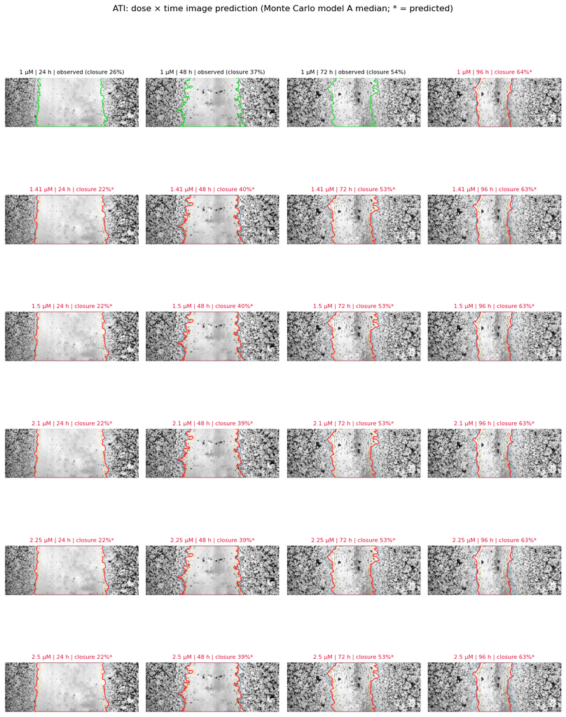

**Figure caption (English):** ATI: observed (1 µM) and model-predicted (asterisk) images across doses (rows) and time points (columns), generated by level-set front propagation from the Monte Carlo median of model A; yellow and blue contours mark the 90% interval.

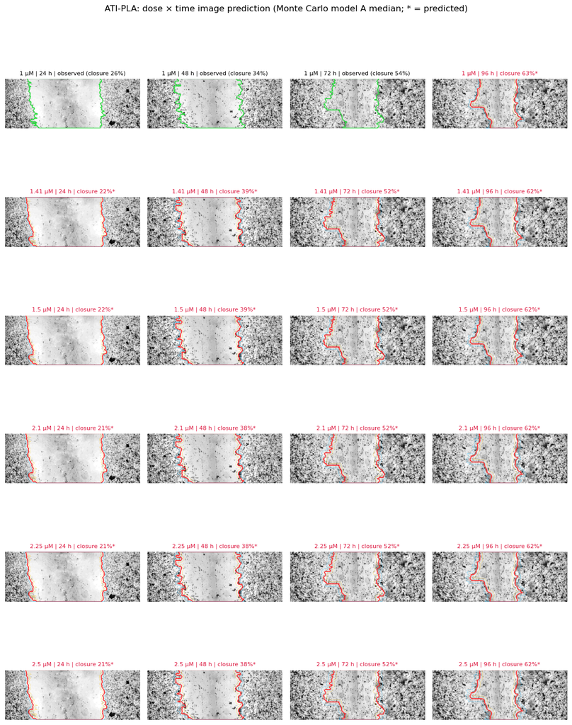

**Figure caption (English):** ATI-PLA: observed (1 µM) and model-predicted (asterisk) images across doses (rows) and time points (columns), generated by level-set front propagation from the Monte Carlo median of model A; yellow and blue contours mark the 90% interval.

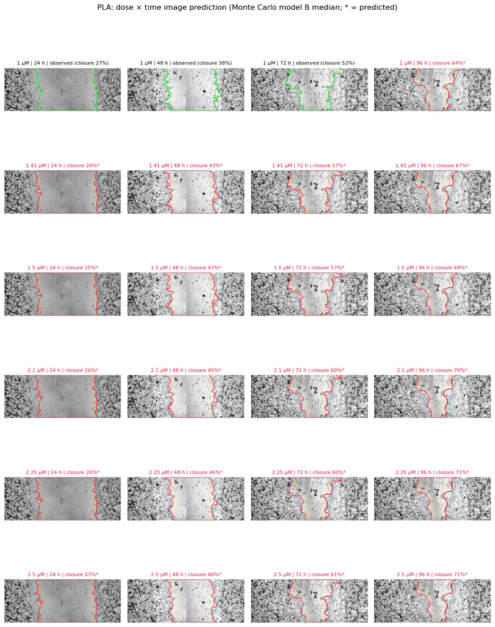

**Figure caption (English):** PLA: observed (1 µM) and model-predicted (asterisk) images across doses (rows) and time points (columns), generated by level-set front propagation from the Monte Carlo median of model B; yellow and blue contours mark the 90% interval.

```python
if not CFG.get("DOSE_ANALYSIS", True):
    print("⏭ Doz analizi kapalı (ayar: DOZ_ANALIZI = False).")
else:
    T_VIS = [t for t in [24.0, 48.0, 72.0, 96.0] if t in T_DOSE]
    for dname in CFG["DRUGS"]:
        model = "B" if dname == ctrl else "A"
        ser = SERIES[dname]
        fig, axes = plt.subplots(len(DOSES), len(T_VIS), figsize=(2.8 * len(T_VIS), 2.5 * len(DOSES)))
        axes = np.atleast_2d(axes)
        for r, dose in enumerate(DOSES):
            for c, t in enumerate(T_VIS):
                lo, md, hi = DOSE_MC[(model, dname, dose, t)]
                obs = dose == 1.0 and t in ser["times"]
                if obs:
                    j = ser["times"].index(t)
                    ov = overlay_rgb(ser["imgs"][j], gt=ser["masks"][j])
                    ttl = f"{dose:g} µM | {int(t)} h | observed (closure {100*(1-ser['masks'][j].sum()/ser['A0']):.0f}%)"
                else:
                    im, m = predict_levelset(ser, t, md * ser["A0"])
                    _, mlo = predict_levelset(ser, t, lo * ser["A0"]); _, mhi = predict_levelset(ser, t, hi * ser["A0"])
                    ov = overlay_rgb(np.clip(im, 0, 1), pred=m, fill_alpha=0.0)
                    for mm, col in [(mlo, (255, 200, 0)), (mhi, (0, 180, 255))]:
                        cs_, _ = cv2.findContours(mm.astype(np.uint8), cv2.RETR_EXTERNAL, cv2.CHAIN_APPROX_NONE)
                        cv2.drawContours(ov, cs_, -1, col, 1)
                    ttl = f"{dose:g} µM | {int(t)} h | closure {100*(1-md):.0f}%*"
                a = axes[r, c]; a.imshow(ov); a.set_axis_off()
                a.set_title(ttl, fontsize=8, color="k" if obs else "crimson")
                imwrite_any(DIRS["dose"] / f"{dname}_{dose:g}uM_{int(t)}h_model{model}.png", cv2.cvtColor(ov, cv2.COLOR_RGB2BGR))
        plt.suptitle(f"{DL(dname)}: dose × time image prediction (Monte Carlo model {model} median; * = predicted)", y=1.0)
        plt.tight_layout(); savefig(f"41_dose_grid_{dname}", drug=DL(dname), model=model); plt.show()
```

## 15. Kaynak kullanım raporu, tekrarlanabilirlik ve dışa aktarma

```python
MONITOR.set_stage("rapor")
time.sleep(1.5)
RES = MONITOR.summary()
display(Markdown("**Aşama bazında ortalama kaynak kullanımı**")); display(RES)
MONITOR.plot(DIRS["figures"] / "90_resource_usage.png")
MONITOR.df().to_csv(DIRS["tables"] / "resource_usage.csv", index=False)
train_stages = RES[RES.index.str.startswith(("GA", "CV"))] if len(RES) else RES
if len(train_stages) and "gpu" in train_stages:
    print(f"Eğitim aşamalarında ortalama GPU kullanımı: %{train_stages['gpu'].mean():.1f}, CPU: %{train_stages['cpu'].mean():.1f}")
    if train_stages["gpu"].mean() < 90:
        print("ℹ️ GPU %90'ın altında kaldıysa: CFG['BATCH_MULT']=1.5–2 veya CFG['GA']['workers']=3 deneyin (VRAM izin verdiği ölçüde).")

with pd.ExcelWriter(DIRS["tables"] / "results_all.xlsx") as xw:
    pretty.to_excel(xw, sheet_name="Ozet", index=False)
    SUMMARY.to_excel(xw, sheet_name="Ozet_ham", index=False)
    used = set()
    for n in RESULTS:
        sh_ = re.sub(r"[^A-Za-z0-9]+", "_", n).strip("_")[:28] or "model"
        k_ = 2
        while sh_ in used:
            sh_ = f"{sh_[:26]}_{k_}"; k_ += 1
        used.add(sh_)
        RESULTS[n].to_excel(xw, sheet_name=sh_, index=False)
    if "WIL" in globals() and len(WIL):
        WIL.to_excel(xw, sheet_name="Wilcoxon", index=False)
    AREA.to_excel(xw, sheet_name="Alan_Kapanma", index=False)
    KIN_TABLE.to_excel(xw, sheet_name="Kinetik", index=False)
    LOTO.to_excel(xw, sheet_name="Zaman_LOTO", index=False)
    TEMP.to_excel(xw, sheet_name="Zaman_Tahmin", index=False)
    if isinstance(globals().get("DOSE"), pd.DataFrame):
        DOSE.to_excel(xw, sheet_name="Doz_Tahmin", index=False)
    for nm_, df_ in [("Referans_Kontrol", "CHECK"), ("ROC_PR", "ROC_TABLE"), ("Uyum_Pearson_CCC", "AGREE"), ("Genislik_Ozet", "WSUM"),
                     ("Birlesme_Zamani", "MERGE_TABLE"), ("Kinetik_Yontemler", "KCMP"), ("SSL_Ablasyon", "SSL_TABLE"), ("Ogrenme_Egrisi", "LC")]:
        obj = globals().get(df_)
        if isinstance(obj, pd.DataFrame) and len(obj):
            obj.astype({c: str for c in obj.columns if obj[c].dtype == object}).to_excel(xw, sheet_name=nm_, index=False)
    pd.DataFrame([dict(model=k, **({"hp": json.dumps(v, ensure_ascii=False, default=str)})) for k, v in BEST_HP.items()]).to_excel(xw, sheet_name="Hiperparametreler", index=False)

env = dict(python=sys.version, torch=torch.__version__, cuda=torch.version.cuda, cudnn=torch.backends.cudnn.version(),
           smp=smp.__version__, timm=timm.__version__, sklearn=sklearn.__version__, skimage=skimage.__version__,
           opencv=cv2.__version__, gpu=GPU_NAME, gpu_mem_gb=round(GPU_MEM_GB, 2), cpu_threads=N_CPU,
           ram_gb=round(psutil.virtual_memory().total / 1024**3, 1), mode=CFG["MODE"], ga_protocol=CFG["GA"]["protocol"],
           cv_scheme=CFG["CV_SCHEME"], mask_source=dict(pd.Series(MASK_SRC).value_counts()), pretrain=PRETRAIN_STATUS,
           demo_data=IS_DEMO, failed_models=FAILED)
(OUT / "environment.json").write_text(json.dumps(env, indent=1, ensure_ascii=False, default=str), encoding="utf-8")
print("✅ Tüm çıktılar:", OUT.resolve())
if CFG["MODE"] == "QUICK":
    print("\nℹ️ Bu bir QUICK (deneme) çalıştırmasıydı: bütçeler küçük, sonuçlar makale için değil.\n"
          "   Her şey sorunsuz çalıştıysa 2. Konfigürasyon hücresinde MODE = \"FULL\" yapıp Restart & Run All yapın.")
print("ℹ️ Excel ve rapor kaydedildi. Sıradaki hücre: öğrenme eğrisi (ayar: OGRENME_EGRISI).")
```

[output not shown]

[output not shown]

```
⏭  Atlandı: daha önceki bir hücrede hata var (⛔ işaretli hücreye bakın).
```

## 15.1 Öğrenme eğrisi: kaç eğitim görüntüsü yeterli? (veri verimliliği) — en sona alındı

Ramesh vd. (2017), başarıyı eğitim alt-görüntü sayısının fonksiyonu olarak raporlamıştır. Burada ana model (`ANA_MODEL`) için her dış katlamada eğitim havuzundan (9 görüntü) **ilaç dengeli** m ∈ {1, 3, 6, 9} görüntü seçilir, model bu alt kümeyle `TRAIN_ITERS` iterasyon eğitilir ve aynı test görüntülerinde değerlendirilir.

- `OGRENME_EGRISI = "hızlı"`: 4 katlama × 4 boyut × 1 tekrar = **16 eğitim**; `"tam"`: m < 9 için 3 tekrar = **40 eğitim**; `"kapalı"`: atlanır.
- Bu bölüm **en sondadır**: 11–15. bölümlerin bütün tablo ve figürleri bundan önce kaydedilmiştir. Hücre başlarken tahmini süreyi yazar (10.1'deki gerçek eğitim süresinden).
- Her eğitim bitince sonuç `learning_curve_partial.csv` dosyasına eklenir. Hücreyi yarıda keserseniz, tekrar çalıştırdığınızda **kaldığı yerden** devam eder (yalnızca aynı referans ve ayarlarla üretilmiş satırlar kullanılır).
- Aynı katlamanın eğitimleri VRAM'e sığdığı kadar **aynı anda** çalışır.

```
Öğrenme eğrisi: toplam 16 eğitim, tamamlanmış 0, kalan 16.
⏱️ Tahmini süre ≈ 7.0 saat (10.1'deki eğitim süresine göre: {'Attention U-Net': 26.1} dk/eğitim). İstediğiniz an durdurabilirsiniz; tekrar çalıştırınca kaldığı yerden sürer.
   1/16: Attention U-Net | katlama 0 | m=1 | tekrar 0 → 32.2 dk (geçen toplam 0.54 saat)
   2/16: Attention U-Net | katlama 0 | m=6 | tekrar 0 → 31.8 dk (geçen toplam 1.07 saat)
   3/16: Attention U-Net | katlama 0 | m=9 | tekrar 0 → 31.8 dk (geçen toplam 1.59 saat)
   4/16: Attention U-Net | katlama 0 | m=3 | tekrar 0 → 32.2 dk (geçen toplam 2.13 saat)
   5/16: Attention U-Net | katlama 1 | m=1 | tekrar 0 → 23.2 dk (geçen toplam 2.52 saat)
   6/16: Attention U-Net | katlama 1 | m=6 | tekrar 0 → 22.8 dk (geçen toplam 2.90 saat)
   7/16: Attention U-Net | katlama 1 | m=9 | tekrar 0 → 22.9 dk (geçen toplam 3.28 saat)
   8/16: Attention U-Net | katlama 1 | m=3 | tekrar 0 → 23.1 dk (geçen toplam 3.66 saat)
   9/16: Attention U-Net | katlama 2 | m=1 | tekrar 0 → 32.2 dk (geçen toplam 4.20 saat)
   10/16: Attention U-Net | katlama 2 | m=6 | tekrar 0 → 31.8 dk (geçen toplam 4.73 saat)
   11/16: Attention U-Net | katlama 2 | m=9 | tekrar 0 → 31.8 dk (geçen toplam 5.26 saat)
   12/16: Attention U-Net | katlama 2 | m=3 | tekrar 0 → 32.2 dk (geçen toplam 5.80 saat)
   13/16: Attention U-Net | katlama 3 | m=1 | tekrar 0 → 21.3 dk (geçen toplam 6.15 saat)
   14/16: Attention U-Net | katlama 3 | m=3 | tekrar 0 → 21.3 dk (geçen toplam 6.15 saat)
   15/16: Attention U-Net | katlama 3 | m=6 | tekrar 0 → 20.7 dk (geçen toplam 6.50 saat)
   16/16: Attention U-Net | katlama 3 | m=9 | tekrar 0 → 20.7 dk (geçen toplam 6.50 saat)
```

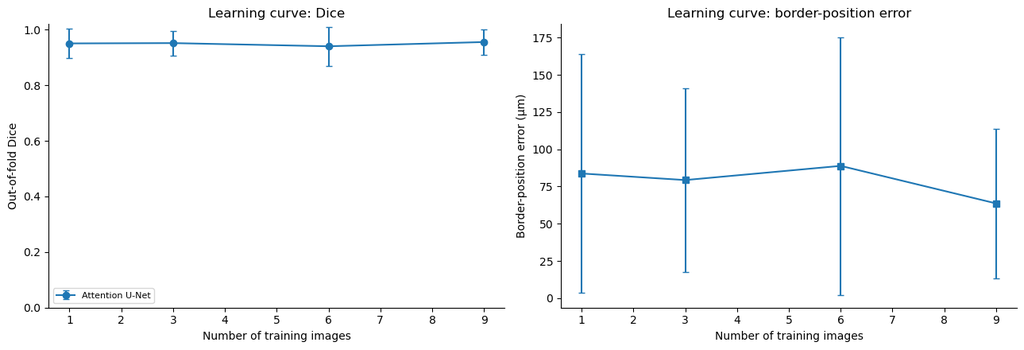

**Figure caption (English):** Learning curve of Attention U-Net: out-of-fold Dice coefficient (left) and mean border-position error (right) as a function of the number of training images (mean ± SD over folds and repeats).

| model | n_train | Dice mean | Dice std | IoU mean | IoU std | AUC mean | AUC std | BorderMAE mean | BorderMAE std |
| --- | --- | --- | --- | --- | --- | --- | --- | --- | --- |
| Attention U-Net | 1 | 0.9506 | 0.0523 | 0.9099 | 0.0881 | 0.9836 | 0.0182 | 83.7088 | 80.3175 |
|  | 3 | 0.9518 | 0.0446 | 0.9110 | 0.0774 | 0.9818 | 0.0156 | 79.3063 | 61.7509 |
|  | 6 | 0.9404 | 0.0702 | 0.8944 | 0.1153 | 0.9731 | 0.0434 | 88.8333 | 86.5409 |
|  | 9 | 0.9556 | 0.0459 | 0.9181 | 0.0795 | 0.9892 | 0.0130 | 63.6139 | 50.1233 |

```python
LC = pd.DataFrame()
lcc = CFG["LEARNING_CURVE"]
if not lcc["enabled"]:
    print("⏭ Öğrenme eğrisi kapalı (ayar: OGRENME_EGRISI = 'kapalı').")
else:
    MONITOR.set_stage("öğrenme eğrisi")
    f_lc, f_part = DIRS["tables"] / "learning_curve.csv", DIRS["tables"] / "learning_curve_partial.csv"
    lc_models = [n for n in lcc["models"] if n in RESULTS and spec_of(n) is not None and spec_of(n).kind in ("torch", "sam", "rf")]
    if not lc_models:
        print(f"⚠️ Öğrenme eğrisi için model bulunamadı (istenen: {lcc['models']}, mevcut: {list(RESULTS)}).")
    prev = pd.read_csv(f_part) if (CFG["RESUME"] and f_part.exists()) else pd.DataFrame()
    LC_FP = {n: run_fp(spec_of(n)) for n in lc_models}
    if len(prev):                                     # yalnız aynı referans/ayarlarla üretilmiş satırlar
        prev = prev[prev["fp"].astype(str) == prev["model"].map(LC_FP).astype(str)] if "fp" in prev else prev.iloc[0:0]
    rows = prev.to_dict("records") if len(prev) else []
    done = {(str(r["model"]), int(r["fold"]), int(r["n_train"]), int(r["rep"])) for r in rows}
    # plan (alt kümeler sabit tohumla seçilir; yarıda kalınca aynı alt kümelerle devam edilir)
    rng_lc = np.random.default_rng(CFG["SEED"])
    plan = []
    for n in lc_models:
        for f in range(min(lcc["folds"], len(OUTER_FOLDS))):
            te = OUTER_FOLDS[f]; pool = sorted(set(ALL_IDX) - set(te))
            for m in lcc["sizes"]:
                if m > len(pool):
                    continue
                for r in range(lcc["repeats"] if m < len(pool) else 1):
                    perm = list(rng_lc.permutation(pool))
                    by_d = {d: [i for i in perm if str(META.loc[i, "drug"]) == d] for d in CFG["DRUGS"]}
                    sub = []
                    while len(sub) < m:
                        for d in CFG["DRUGS"]:
                            if by_d[d] and len(sub) < m:
                                sub.append(by_d[d].pop())
                    plan.append((n, f, m, r, sorted(sub), te))
    todo = [x for x in plan if (x[0], x[1], x[2], x[3]) not in done]
    t_ref = {n: float(INFO.get(n, {}).get("train_s", np.nan)) for n in lc_models}
    est_h = sum(t_ref.get(x[0], np.nan) for x in todo) / 3600
    print(f"Öğrenme eğrisi: toplam {len(plan)} eğitim, tamamlanmış {len(plan) - len(todo)}, kalan {len(todo)}.")
    if np.isfinite(est_h):
        print(f"⏱️ Tahmini süre ≈ {est_h:.1f} saat (10.1'deki eğitim süresine göre: "
              f"{ {n: round(v / 60, 1) for n, v in t_ref.items()} } dk/eğitim). İstediğiniz an durdurabilirsiniz; tekrar çalıştırınca kaldığı yerden sürer.")
    t_lc = time.time(); n_done = [0]
    groups = OrderedDict()
    for x in todo:                                    # aynı model + katlama → aynı hiperparametre → birlikte (paralel)
        groups.setdefault((x[0], x[1]), []).append(x)
    for (n, f), items in groups.items():
        spec = spec_of(n); hp_f = FOLD_HP[n][f]
        if spec.kind == "torch":
            ensure_vram_profile(spec, hp_f)
        def _job(x=None, spec=spec, hp_f=hp_f):
            n_, f_, m_, r_, sub_, te_ = x
            t1 = time.time()
            try:
                probs, _ = fit_predict(spec, hp_f, sub_, te_, iters=CFG["TRAIN_ITERS"], seed=CFG["SEED"] + 31 * r_ + f_, tta=False)
                return x, probs, None, time.time() - t1
            except Exception as ex:
                return x, None, f"{type(ex).__name__}: {ex}", time.time() - t1
        def _done(k, res, hp_f=hp_f):
            (n_, f_, m_, r_, sub_, te_), probs, err, dt = res
            n_done[0] += 1
            if err:
                print(f"   [{n_}] katlama {f_}, m={m_}: atlandı → {err}"); return
            for i in te_:
                mm = full_metrics(probs[i], i, hp_f)
                rows.append(dict(model=n_, n_train=m_, fold=f_, rep=r_, idx=i, Dice=mm["Dice"], IoU=mm["IoU"],
                                 AUC=mm["AUC"], BorderMAE=mm["BorderMAE"], fp=LC_FP[n_]))
            pd.DataFrame(rows).to_csv(f_part, index=False)
            print(f"   {n_done[0]}/{len(todo)}: {n_} | katlama {f_} | m={m_} | tekrar {r_} → {dt / 60:.1f} dk "
                  f"(geçen toplam {(time.time() - t_lc) / 3600:.2f} saat)")
        run_gpu_jobs(spec, hp_f, [(lambda x=x: _job(x)) for x in items], on_done=_done)
    LC = pd.DataFrame(rows)
    if len(LC):
        LC.to_csv(f_lc, index=False)
        fig, ax = plt.subplots(1, 2, figsize=(13, 4.5))
        for n, g in LC.groupby("model"):
            s_ = g.groupby("n_train")[["Dice", "BorderMAE"]].agg(["mean", "std"])
            c = FAMILY_COLORS.get(spec_of(n).family if spec_of(n) else "", None)
            ax[0].errorbar(s_.index, s_[("Dice", "mean")], yerr=s_[("Dice", "std")], marker="o", capsize=3, label=ML(n), color=c)
            ax[1].errorbar(s_.index, s_[("BorderMAE", "mean")], yerr=s_[("BorderMAE", "std")], marker="s", capsize=3, label=ML(n), color=c)
        ax[0].set_xlabel("Number of training images"); ax[0].set_ylabel("Out-of-fold Dice"); ax[0].set_ylim(0, 1.02); ax[0].legend(fontsize=8)
        ax[1].set_xlabel("Number of training images"); ax[1].set_ylabel(f"Border-position error ({UNIT_LEN})")
        ax[0].set_title("Learning curve: Dice"); ax[1].set_title("Learning curve: border-position error")
        plt.tight_layout(); savefig("17_learning_curve"); plt.show()
        display(LC.groupby(["model", "n_train"])[["Dice", "IoU", "AUC", "BorderMAE"]].agg(["mean", "std"]).round(4))
```

```python
MONITOR.stop()
print("✅ Tamamlandı. Tüm çıktılar:", OUT.resolve())
print(f"   Referanslar: {N_BLUE_REF}/{N_IMG} görüntüde mavi çizgilerden | parmak izi {REF_FP} | "
      f"birim: {UNIT_LEN}" + (f" ({CFG['PIXEL_SIZE_UM']:.4f} µm/piksel)" if CFG["PIXEL_SIZE_UM"] else ""))
for k, d in DIRS.items():
    print(f"   {k:13s}: {len(list(d.glob('**/*')))} dosya")
```

```
✅ Tamamlandı. Tüm çıktılar: C:\Users\DELL\Downloads\outputs_FULL
   Referanslar: 12/12 görüntüde mavi çizgilerden | parmak izi e457b690467b8378 | birim: µm (2.9150 µm/piksel)
   figures      : 30 dosya
   tables       : 28 dosya
   predictions  : 75 dosya
   ga           : 6 dosya
   temporal     : 60 dosya
   dose         : 72 dosya
   cache        : 39 dosya
   models       : 0 dosya
   pseudo_masks : 12 dosya
   gt_from_blue : 12 dosya
```

## 16. Sonuç ve sonraki adım

Bu notebook çalıştıktan sonra elinizde makale için gereken tüm nicel sonuçlar (tablolar `outputs/tables/results_all.xlsx`), 300 dpi figürler (`outputs/figures/`), GA geçmişleri, tahmin edilen zaman ve doz görüntüleri ile tekrarlanabilirlik kaydı (`outputs/environment.json`) bulunur.

**Makale yazımına geçmeden önce kontrol listesi:**

1. Referanslar mavi çizgilerden doğru çıkarıldı mı? (`00_dataset_grid.png` ve `gt_annotation_check.csv`; `mask_src` = "mavi çizgi" olmalı.)
2. `MODE="FULL"` (nested GA) ile nihai koşuyu yaptınız mı?
3. Kaynak kullanımı raporunda GPU ortalaması hedefe yakın mı?
4. LOTO doğrulama tablosu, birleşme zamanı tahminleri ve doz senaryolarının belirsizlik aralıkları raporlanacak mı?
5. Doz bölümünde "veride tek doz (1 µM) var; tahminler varsayıma dayalı" ifadesi ve duyarlılık ısı haritası makaleye eklendi mi?
6. Öğrenme eğrisi (15.1), "12 görüntü yeterli mi?" sorusuna yanıt olarak Sonuçlar'da yer alıyor mu?
7. Makalenin Yöntemler bölümü bu sürüme göre güncellendi mi? (ana model Attention U-Net; karşılaştırma: U-Net ve klasik yöntem; SSL yok; referans = mavi çizgilerle çizilen sınırlar)